# [2019]_Горелов_Шарпей_I

# 16. ЗАДАНИЯ ДЛЯ САМОСТОЯТЕЛЬНОЙ РАБОТЫ.

Мы изучили большое количество разных элементов управления для создания развитого интерфейса пользователя. Ниже приведены задания на разработку Windows-приложений. Задания имеют разную сложность. Вам предлагается выбрать и решить наиболее интересные для Вас задачи. В качестве примера приведено решение двух задач.

**Задача 1**. Разработать Windows-приложение, вычисляющее сумму двух чисел, введенных с клавиатуры в текстовые поля.

**Задача 2**. Разработать Windows-приложение, конвертирующее выбранную валюту в другую валюту. Вид исходной и целевой валюты должен выбираться из соответствующих перечней.

**Задача 3**. Разработать Windows-приложение «Обменный пункт». Примечание: данная задача отличается от предыдущей наличием двух курсов: покупки и продажи.

**Задача 4**. Разработать Windows-приложение для вычисления объемов трех фигур: шара, цилиндра и конуса. Объемы вычисляются по формулам: $V_ш = 4 \pi R3 / 3$; $V_ц = \pi R2h$; $V_k = \pi R3 h / 3$;

**Задача 5**. Разработать Windows-приложение «Вклад», вычисляющее состояние вклада на конец года. Ввести с клавиатуры в текстовые поля следующие значения: сумма вклада — S; процент по вкладу (начисляется один раз в конце года) — Р; год. Состояние вклада D на конец года вычисляется по формуле: $D = S + S * P / 100$; Предусмотреть возможность вычисления суммы на каждый следующий год. Реализовать недоступность кнопок с помощью свойства `Enable`. Разработать три варианта оконного интерфейса приложения в соответствии с рис. 16.1 — 16.3.

Страница 126

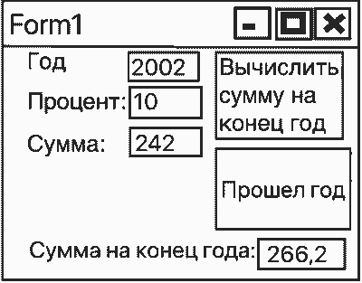

Рис. 16.1. Первый вариант оконного интерфейса приложения.

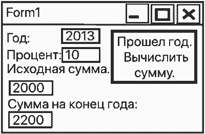

Рис. 16.2. Второй вариант оконного интерфейса приложения.

Страница 127

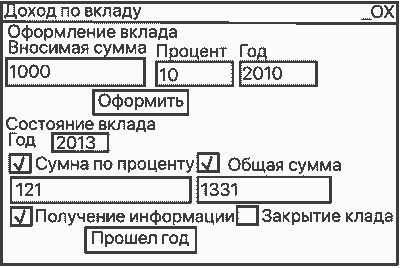

Рис. 16.3. Третий вариант оконного интерфейса приложения.

**Задача 6**. Разработать приложение-калькулятор. Пользователь должен вводить два числа и выбирать вид операции (+, -, *, /), отображаемой в переключателях. По кнопке «Вычислить» (или «=») должен вычисляться и отображаться результат. Предусмотреть два способа извещения пользователя об ошибке формата ввода: 1) через `Label` (очищать это поле в обработчике `textBox1_TextChanged`); 2) с помощью `MessageBox`.

Используйте установку фокуса ввода. Разработайте четыре варианта программы: **во-первых**, 1. Анализ вида операции выполнить в обработчике события Click элемента Button. **Во-вторых**, 2. Использовать четыре обработчика событий CheckedChanged элемента RadioButton для запоминания вида операции. **В-третьих**, Использовать один общий обработчик события CheckedChanged элемента RadioButton для запоминания вида операции. **В-четвёртых**, Организовать вывод истории вычислений в многострочное текстовое поле. С помощью переключателя задавать точность результата без округления и с округлением. Возможный вариант окна приведён на рис. 16.4.

Страница 128

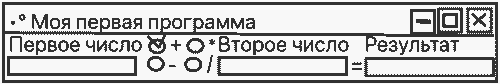

Рис. 16.4. Окно программы «Калькулятор».

**Задача 7**. Разработать приложение для расчета платежа за электроэнергию с учетом текущего и предыдущего показаний счетчика, а также с учетом действующего тарифа.

**Задача 8**. Разработать Windows-приложение для нахождения корней квадратного уравнения. В окне должны отображаться три элемента TextBox для ввода коэффициентов, кнопка «Вычислить» и необходимые надписи. Для вывода результата используйте элемент Label.

Страница 129

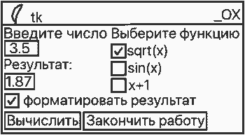

Рис. 16.5. Окно программы вычисления функций.

**Задача 10**. Разработать Windows-приложение для проверки введенного числа. Условия проверки показаны в окне на рис. 16. Для задания условий использовать 4 флажка. Результат проверки вывести в поле «Результат». Условия выбирать независимо друг от друга. Если условие не выбрано, то оно не должно участвовать в проверке. Проверку выполнять при нажатии кнопки «Проверить».

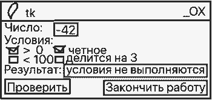

Рис. 16.6. Окно программы задачи 10.

Страница 130

Задача 11. Разработать Windows-приложение для отображения матрицы целых чисел размером NxM (размерность ввести с экрана). Сформировать матрицу и заполнить её случайными числами из диапазона $[-50, 50]$. Сформированную матрицу отобразить в многострочном элементе TextBox с горизонтальной и вертикальной полосами прокрутки. Возможный вариант окна представлен на рис. 16.7.

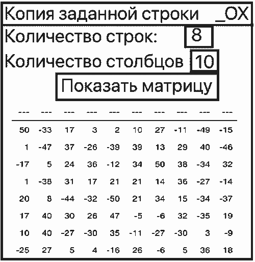

Рис. 16.7. Окно программы задачи 11

Текст программы (файл Form1.cs):

[output not shown]

Страница 131 - 132

В окне свойств Visual Studio элементам управления были присвоены следующие значения:

| Элемент управления | Свойство | Значение |
| --- | --- | --- |
| Многострочный Textisox | Name | multiLineTextBox |
| '' | Multilined | true |
| '' | Scrollbars | Both |
| '' | WordWrap | false |
| '' | Font | Lucida Console |
| Кнопка Button | Name | Показать |
| '' | Text | Показать матрицу |

Ряд значений, присвоенных свойствам, здесь не приведён, так как эти настройки очевидны. Обратите внимание на следующие моменты. В программе для её упрощения не делается проверка полей `textBox1` и `textBox2`. Для отображения столбцов матрицы, выровненных по вертикали, в элементе `TextBox` установлен моноширинный шрифт `Lucida Console`, а также задаётся одинаковая ширина для всех элементов матрицы в методе Format: `string.Format("{0,5}", a[l,j])`.

**Задача 12**. Разработать `Windows`-приложение для формирования и отображения квадратной матрицы символьного типа размером `NxN`. Элементы матрицы должны отображаться в элементах `Label`, которые должны создаваться разработчиком в режиме разработки кода (то есть вручную). Квадратная матрица должна заполняться случайными значениями по правилу: в строки с четными номерами заносятся прописные латинские буквы, а в строки с нечетными номерами — символы-цифры. Выделить цветом главную и побочную диагонали матрицы. Отобразить символы главной диагонали в элементе Label.

Страница 133

Пример матрицы:

| A | M | W | Q | E |
| --- | --- | --- | --- | --- |
| 6 | 1 | 7 | 8 | 3 |
| Q | Z | A | D | T |
| 4 | 2 | 3 | 9 | 5 |
| A | X | R | C | V |

Для приведённого примера главная диагональ: A1A9V. Приведём решение этой задачи. В учебных целях покажем, как можно удалять элементы из контейнера формы и добавлять новые. Установим ограничение: N <= 30. В начале работы приложения окно должно отображать элементы управления для ввода количества строк (см. рис. 16.8).

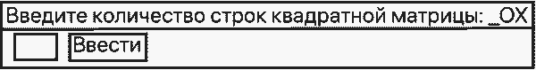

Рис. 16.8. Исходное окно приложения.

Для отображения элементов матрицы в программе используется массив элементов управления Label (см. рис. 16.9). После ввода количества строк и нажатия кнопки «Ввести» программа удалит из коллекции элементов формы текстовое поле и кнопку, создаст двумерный массив типа Label и заполнит его случайными символами. Для размещения элементов массива в окне в программе вычисляются их координаты. Также устанавливается положение надписи с элементами главной диагонали и настраиваются новые размеры формы.

Страница 134

|  |  |  |  |  |  |  | _ | O | X |
| --- | --- | --- | --- | --- | --- | --- | --- | --- | --- |
| **O** | P | P | I | M | K | C | P | W | H |
| 7 | **5** | 5 | 8 | 7 | 4 | 2 | 7 | 7 | 0 |
| S | F | **P** | G | L | L | H | A | K | R |
| 7 | 8 | 0 | **3** | 2 | 2 | 0 | 2 | 7 | 2 |
| K | K | Q | X | **A** | S | D | B | A | O |
| 2 | 6 | 1 | 5 | 0 | **3** | 8 | 3 | 7 | 0 |
| C | B | E | F | K | X | **L** | G | R | P |
| 4 | 0 | 8 | 5 | 5 | 2 | 5 | **6** | 2 | 6 |
| H | F | A | V | L | E | T | M | **I** | W |
| 2 | 5 | 3 | 7 | 1 | 3 | 2 | 3 | 4 | **0** |

Рис. 16.9. Окно приложения с матрицей и результатом.

Поскольку элементы управления `Label` добавляются в коллекцию формы в цикле, то в программе откладывается их отображение, пока они не будут полностью сформированы и добавлены в коллекцию.

Страница 135

Текст программы (файл Form1.cs):

```
using System;
using System.Drawing;
using System.Windows.Forms;

namespace WindowsApplication1
{
    public partial class Form1 : Form
    {
        public Form 1(){ InitializeComponent); }
        private void button1_Click(object sender, EventArgs e)
        {
            Random rnd = new Random();
            int n;
            if (
                !int.TryParse(textBox1.Text, out n)
                || n > 30
            )
            {
                MessageBox.Show(
                    "Вы ввели неправильное значение!»
                    + "\nЗначение д.б. числом, меньшим 31."
                    + "\n\n Повторите ввод."
                );
                textBox1.Focus();
                return;
            }
```

```
            this.SuspendLayout();
            // Отложить отображение формы.
            // Удаление элементов управления из формы.
            Controls.Remove(textBox1);
            Controls.Remove(button1);
            label1.Text = "Главная диагональ: ";
            Label[,] table = new Label[n, n];
            // Создаем матрицу из элементов Label.
            for (int i = 0; 1 < n; i++)
            {
                for (int j = 0; j < n; 1++)
                {
                    table[i, j] = new Label();
                    table[i, j].AutoSize = true;
                    table[i, j].Location = new Point(20 + 20 * j, 20 + 20 * i);
                    if (i % 2 == 0)
                    {
                        // Если строка четная....
                        table[i, j].Text = (
                                (char)md.Next('A', 'Z')
                            ).ToString()
                        ;
                    }
```

Страница 136

```
                    else
                    {
                        // Если строка нечетная.
                        table[i, j].Text = (
                            md.Next(10)
                            ).ToString()
                        ;
                    }
                    // Измененяем цвет у диагонального
                    // элемента матрицы.
                    if (
                        i == j
                        || i == n - j-1
                    )
                        table[i,j].BackColor = Color.Coral;
                    // Добавим в контейнер формы.
                    Controls.Add(table[i, j]);
                    // Формируем строку с элементами
                    // главной диагонали.
                    if (i == j)
                        label1.Text += tablet[i,j].Text + " ";

                }
            }
```

```
            // Устанавливаем положение элементов label1.
            label1.Location = new Point(10, table[n - 1, 0].Location.Y + 30);
            // Настраиваем размер формы.
            int pt = Math.Max(label1.Text.Length + 25,table(O, n - 1].Location.X + 35);
            this.ClientSize = new Size(pt, label1.Location.Y + 30);
            // Разрешаем отображение элементов
            // управления формы.
            this.ResumeLayout(false);
            this.PerformLayout();
        }
    }
}
```

Страница 137

Естественно, данную программу можно улучшить, применив для матрицы контейнер типа Panel. Также можно добавить кнопку для возврата к исходному формату окна.

Страница 138

# 17. СПИСОЧНЫЕ ЭЛЕМЕНТЫ УПРАВЛЕНИЯ.

### 17.1. Общие сведения.

Списки `Windows Forms` представлены тремя элементами управления: простой список (класс `ListBox`), комбинированный список (класс `ComboBox`) и список с флажками (класс `CheckedListBox`). Эти три списка приведены на рис. 17.1.

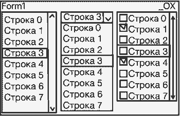

Рис. 17.1. Простой список (слева), комбинированный список (в центре) и список с флажками (справа)

**Замечание**. Читатель должен различать, о каких списках идет речь: списки как элементы управления или списки как коллекции данных. Элементы управления `ListBox`, `ComboBox` и `CheckedListBox` будем называть обобщенным термином «списочные элементы управления». В списочных элементах управления автоматически создаются полосы прокрутки, если количество строк больше, чем можно отобразить в элементе. **Простой список** — элемент управления `ListBox` — отображается в виде списка строк, из которых пользователь может выбрать нужную щелчком мыши (см. рис. 17.1, слева). **Комбинированный список** — элемент управления `ComboBox` — дополнительно к списку `ListBox` отображает текстовое поле (поле ввода), в котором отображается текущий элемент. Список раскрывается по щелчку кнопки со стрелкой (см. рис. 17.1, справа от текстового поля) и закрывается после выбора строки щелчком мыши. На рис. 17.1, в центре, показан раскрытый комбинированный список. Обычно же отображается только текстовое поле (см. рис. 17.2, в центре), что весьма экономит свободное пространство формы.

Страница 139

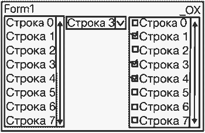

Рис. 17.2. Комбинированный список (в центре) свернут.

**Список с флажками** — элемент управления `CheckedListBox` — это постоянно раскрытый список, где слева от каждой строки отображается флажок (см. рис. 17.2, справа). Элементы всех списков имеют тип object, поэтому в список можно добавить объект любого типа.

Страница 140

Поведение элементов управления `ListBox`, `ComboBox` или `CheckedListBox` в отдельных аспектах очень похоже друг на друга, и в некоторых случаях они взаимозаменяемы, поэтому в данном подразделе рассмотрим общую функциональность списочных элементов управления. Перечислим общие методы и свойства списочных элементов управления. **Методы**:

- **BeginUpdate** — запрещает рисование в элементе управления вплоть до вызова метода EndUpdate. Метод полезен при добавлении в список большого количества объектов.
- **EndUpdate** - возобновляет рисование списочного элемента управления после того, как оно было приостановлено методом `BeginUpdate`.
- **FindString** — производит поиск первого элемента в списке, который начинается с указанной строки или индекса.
- **FindStringExact** — ищет первый элемент в списке, точно соответствующий указанной строке.
- **FindStringExact** — ищет первый элемент в списке, точно соответствующий указанной строке.
- **GetSelected** — возвращает значение, определяющее, выбран ли указанный элемент.
- **Refresh** - немедленно перерисовывает себя и все дочерние элементы.

**Свойства**:

- **AllowSelection** — получает значение, указывающее, разрешается ли в списочном элементе управления в настоящее время выбор позиций списка.
- **DisplayMember** — получает или задает свойство объекта, которое будет отображаться на экране.
- **DisplayMember** — получает или задает свойство объекта, которое будет отображаться на экране.
- **HorizontalScrollbar** — получает или задает значение, определяющее, отображается ли горизонтальная полоса прокрутки в элементе управления.
- **Items** - получает коллекцию элементов списка. Коллекция и есть список.
- **ScrollAlwaysVisible** — получает или задает значение, определяющее, отображается ли вертикальная полоса прокрутки.
- **Text** - получает строку, соответствующую выбранному в на стоящий момент элементу, или выполняет поиск этого текста.
- **SelectedIndex** - получает или задает индекс выделенного в Настоящий момент элемента коллекции.
- **SelectedItem** - получает или задает выбранный в настоящий момент элемент коллекции.
- **Sorted** - получает или задает значение, показывающее, упорядочены ли отображаемые строки списка по алфавиту.

**События**:

- **SelectedIndexChanged** - происходит при щелчке мышкой на строке списка.

Страница 141

**Коллекция Items**. Как было сказано выше, списочные элементы управления содержат коллекцию строк (объектов), к которой можно получить доступ с помощью свойства Items. Основным средством для работы с коллекцией является индексатор `this[индекс]`, который возвращает из коллекции элемент по указанному индексу. Также для работы с коллекцией можно использовать следующие методы коллекции:

- **Add** - добавляет один объект в конец коллекции.
- **AddRange** — добавляет массив объектов в конец коллекции.
- **Insert** — вставляет объект в конкретное место коллекции.
- **Remove** — удаляет из коллекции заданный элемент.
- **RemoveAt** — удаляет из коллекции элемент с заданным индексом.
- **Clear** - удаляет из коллекции все элементы.

Страница 142

**Класс ListControl**. Все перечисленные списочные элементы управления имеют общую функциональность, унаследованную от класса `ListControl`. Комбинированный список наследует члены класса `ListControl` непосредственно, а `CheckedListBox` — опосредованно. Класс `ListControl` предоставляет общую реализацию членов для всех списочных элементов управления, из которых наиболее значимыми являются свойства, определяющие привязку списка к источнику данных: `DataSource`, `DisplayMember`, `SelectedValue` и `ValueMember`. **Примечание**. Ниже в данном подразделе все примеры будут даны для списка `ListBox`, хотя эти примеры в равной степени справедливы и для `ComboBox` и `CheckedListBox`.

Как заполнять списочные элементы управления данными. Создать коллекцию элементов можно либо в режиме визуальной разработки, либо вручную в режиме кода. В режиме визуальной разработки в окне «Свойства» доступно свойство Items, которое определяет коллекцию элементов типа string. Это простейший способ создания коллекции. Заполнить коллекцию элементами других типов, например объектами типа Student, можно вручную в режиме кода. Чаще всего добавление элементов осуществляется в обработчике события Form1_Load. Для создания списочного элемента управления и добавления в него элементов следует использовать метод Add или AddRange. Метод Add может добавить любой объект в конец коллекции списочного элемента управления. Метод AddRange добавляет в конец коллекции массив объектов. Для вставки объекта в требуемое место списка следует использовать метод Insert. Существует еще один способ добавления элементов: использование внешнего списка, например списка List. Этот способ реализуется посредством привязки элемента управления к источнику данных с помощью свойства DataSource. Этому вопросу посвящен отдельный раздел данного учебника. Если элементами списка являются значения встроенного типа данных, то на экране отображаться будут эти значения. Если элементами списка являются объекты с несколькими свойствами, то списочный элемент управления отображает на экране то свойство (поле) объекта, которое задано свойством DisplayMember. Если это свойство не определено, то для отображения объекта вызывается его метод ToString.

Страница 143

**Примечание**. Несмотря на то что отображается одно свойство или строка, возвращаемая методом `ToString`, список хранит ссылки на объекты, а не строки. **Если нужно**, чтобы в одной строке списка одновременно отображалось два и более свойств объекта, значения этих свойств можно упаковать в одну строку и возвращать ее методом `ToString`. **Если требуется** в списочном элементе управления отображать данные в виде таблицы с вертикально выровненными столбцами, рекомендуется для текста использовать моноширинный шрифт, например `Lucida Console` или `Consolas`, и каждое табличное значение выровнять до общей ширины с помощью метода `string.Format`. Для этих целей можно также использовать и методы `string.PadRight` или `string.PadLeft`. В классах `ListBox` и `CheckedListBox` для выравнивания данных по столбцам можно использовать знаки табуляции, если свойство `UseTabStops` это разрешает (`true`). Иначе управляющий символ `\t` будет отображаться в тексте как два символа. Позиции табуляции устанавливаются предварительно и используются по умолчанию. Чтобы использовать настраиваемые позиции табуляции, установите для свойства `UseTabStops` значение `false`, для свойства `UseCustomTabOffsets` установите значение `true` и добавьте пользовательские значения в коллекцию `CustomTabOffsets`.

**Пример**. В приведённом ниже коде в список `listBox2` добавляются объекты класса `Student`. Для отображения элементов списка используются строки, возвращаемые методом `Student.ToString`. Для списка `listBox2` (см. рис. 17.3, в центре) задан шрифт `Lucida Console`. Список объектов отображается в виде списка строк, поля которых выравнены по вертикали, образуя таблицу. В обработчике `listBox2_SelectedIndexChanged` выбирается текущий объект. В `label3` выводится строка, возвращаемая методом `ToString` для выбранного объекта, а в `label4` выводится свойство `Name` этого объекта. О работе с выбранными элементами будет подробнее описано в этом разделе ниже.

Страница 144

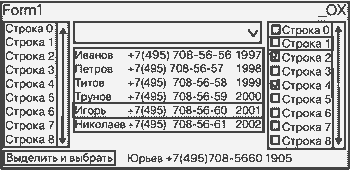

Рис. 17.3. Отображение списка объектов (в центре). Заранее извините. Картинка восстановлена по внешнему виду с фото. Идея но не смысл...

```
class Student
{
    public string Name { get; set; }
    public string Phone { get; set; }
    public int Age { get; set; }
    public override string ToString() => string.Format("{0,-10} {1} {2}", Name, Phone, Age);
}
using System;
using System.Collections.Generic;
using System.Windows.Forms;
public partial class Form1 : Form
{
    public Form1() { InitializeComponent(); }
    private void Form1_Load(object sender, EventArgs e)
    {
        listBox2.BeginUpdate();
        listBox2.Items.Add(new Student { Name = "Иванов", Phone = "+7(495) 708-56-56", Age = 1997 });
        listBox2.Items.Add(new Student { Name = "Петров", Phone = "+7(495) 708-56-57", Age = 1998 });
        listBox2.Items.Add(new Student { Name = "Титов" , Phone = "+7(495) 708-56-58", Age = 1999 });
        listBox2.Items.Add(new Student { Name = "Трунов", Phone = "+7(495) 708-56-59", Age = 1996 });
        listBox2.Items.Add(new Student { Name = "Юрьев" , Phone = "+7(495) 708-56-60", Age = 1995 });
        listBox2.Items.Add(new Student { Name ="Николаев",Phone = "+7(495) 708-56-60", Age = 1995 });
        listBox2.EndUpdate();
    }
    private void listBox2_SelectedIndexChanged(object sender, EventArgs e)
    {
        label3.Text = listBox2.Text;
        label4.Text = ((Student)listBox2.SelectedItem).Name;
    }
}
```

Страница 145 - 146

Страница 147

При выборе элемента списка возникает событие `SelectedIndexChanged`, информирующее программу о щелчке мышкой по строке списка. Сколько раз подряд пользователь будет выделять одну и ту же строку, не делая нового выбора, столько раз обработчик события `SelectedIndexChanged` будет получать управление. Обработчик этого события создается автоматически по двойному щелчку списка на форме. Для чтения выбранной строки списка можно использовать свойство `Техt`. Для получения ссылки на объект, соответствующий выбранной строке, можно использовать свойство `SelectedItem`. **Если задана привязка** списочного элемента управления к источнику данных, то для получения возвращаемого значения можно использовать и свойство `SelectedValue`. Это свойство получает или задает значение свойства объекта, указанного свойством `ValueMember`. Если в `ValueMember` свойство не указано, `SelectedValue` возвращает ссылку на текущий объект. Если привязка не задана, то `SelectedValue = null`. **Примечание**. Следующие понятия в данном учебнике используются как тождественные: «выбранный элемент», «выделенный элемент» и «текущий элемент». Свойство `Text` возвращает выделенную и отображаемую в списке строку в формате string, например:

```
string curitem;
private void listBox1_SelectedIndexChanged(object sender, EventArgs e)
{ curitem = listBox1.Text; }
```

Страница 148

Свойство `SelectedItem` возвращает элемент как ссылку на объект типа `object`, поэтому необходимо приведение объекта к требуемому типу, например:

```
string curItem:
private void listBox1_SelectedIndexChanged(object sender, EventArgs e)
{ curitem = (string)listBox1.SelectedItem; }
```

**Внимание**. Если строка не выбрана, использование свойства `Text` или `SelectedItem` без проверки может привести к возбуждению исключения, поэтому разработчик должен предвидеть эту ситуацию. **Если элементами списка являются объекты**, имеющие несколько свойств, то SelectedItem, возвращая ссылку, позволит выбрать требуемое свойство объекта. Например, в программе, отображающей окно на рис. 17.3, фамилия студента, выбранного в списке, выводится с помощью следующего кода:

```
private void listBox2_SelectedIndexChanged(object sender, EventAras e)
{ label4.Text = ((Student)listBox2.SelectedItem).Name; }
```

**Если в вашем распоряжении** нет ссылки, но есть индекс текущего элемента, ссылку можно извлечь из коллекции, например: `label2.Text = ((Student)listBox2.Items[listBox2.SelectedIndex]).Phone;` **Если разработчик хочет** получить значение выбранного в списке элемента в обработчике события какого-либо другого элемента управления, например `Button`, то ему нужно учитывать, что пользователь к тому моменту может еще не сделать выбор элемента в списке. В этом случае можно проверить свойство `SelectedIndex`, возвращающее индекс выбранного элемента. Все элементы рассматриваемых списков составляют коллекцию, поэтому нумерация элементов начинается с нуля. Если элемент не выбран, свойство `SelectedIndex` возвращает -1, а свойство `Text` — пустую строку ("").

Страница 149

**Пример**. Получение выбранной строки с проверкой на её существование.

```
string curitem;
private void button1_Click(object sender, EventArgs e)
{
    curitem = "":
    if(listBox1.SelectedIndex != -1)
    {curitem = listBox1.Text;}
    else {MessageBox.Show("Вы забыли выбрать город в списке городов.");}
}
```

Для проверки можно использовать и свойство `SelectedItem`, например: `if (listBox1.SelectedItem == null) ...`. Если строка не выбрана, то можно использовать значение из списка по умолчанию, например:

```
string curItem;
private void button1_Click(object sender, EventArgs e)
{
    if(listBox1.SelectedIndex ! = -1)
    { curItem = listBox1.Text; }
    else { curItem = "Москва"; }
}
```

Страница 150

Вместо SelectedIndex можно использовать и свойство Text: если ему присвоить строковое значение, то списочный элемент управления будет искать объект в коллекции, соответствующий указанному тексту. Если найдет, то выделит его. **Поскольку свойство** SelectedIndex доступно и на запись, можно заранее установить какой-либо элемент в качестве выбранного. В начале работы программы список не содержит выделенного элемента до тех пор, пока пользователь не сделает выбор, поэтому рекомендуется в обработчике Form_Load выделить элемент за пользователя. После того как сделано выделение элемента, это выделение можно только изменить, то есть список всегда будет содержать выбранный элемент. В этом случае проверка индекса на значение -1 в дальнейшем не потребуется. **Исключение**, конечно, составляет пустой список и программное снятие выделения. Пример. Выбрать первый элемент списка.

```
private void Form1_Load(object sender, EventArgs e)
{
    listBox1.SelectedIndex = 0;
}
```

Решение третьего вопроса об элементах списка, являющихся объектами с несколькими свойствами, проще всего решается с помощью привязки списочного элемента управления к источнику данных (с помощью свойства списка DataSource) и использования свойств списка DisplayMember и ValueMember.

Страница 151

**Полезная функциональность**. Чтобы вставить элемент в нужное место списка или удалить элемент из списка, используйте, соответственно, методы коллекции `Items.Insert` и `Items.Remove` или `Items.RemoveAt`. Для очистки коллекции элементов используется метод `Items.Clear`. Примеры.

```
listBox1.Items.Insert(1, "Москва"); // Вставить элемент под индексом 1
listBox1.Items.RemoveAt(1); // Удалить элемент с индексом 1,
listBox1.Items.Remove(comboBox1.Selecteditem); // Удал, текущий
listBox1.Items. Remove("Лондон"); // Удалить элемент "Лондон"
listBox1.Items. Clear; // Очистить коллекцию элементов.
```

Страница 152

**Первый случай**: элементами списка являются элементарные данные, к которым относятся встроенные данные языка C#. Это — строки, числа и символы.

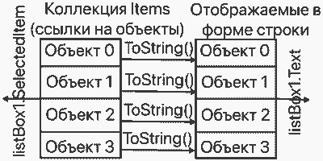

Рис. 17.4. Коллекция элементов и их отображение в форме.

Если объектами коллекции являются строки типа `String`, то содержимое коллекции и его отображение в элементе управления совпадают, то есть свойства `Text` и `SelectedItem` будут возвращать одинаковые значения. Естественно, для объектов-строк метод `ToString` системой не используется. Чтобы в качестве коллекции использовать числа, можно создать эту коллекцию в окне «Свойства», а затем открыть файл `Form1.Designer.cs`, найти в нем код, сгенерированный для списочного элемента управления, и в методе `AddRange` заменить строки на числа, убрав символы ", например, "0" меняем на 0. Для строк-символов `(char)` заменяем символ "на одиночную кавычку ('). Теперь свойства `Text` и `SelectedItem` будут возвращать разные значения, например, для элемента, равного 2:

| --- | --- |
| --- | --- |
| listBox1.Text | возвратит строку "2" |
| int.Parse(listBox1.Text) | возвратит число 2 |
| listBox1.SelectedItem | возвратит ссылку на object |
| (int)listBox1.SelectedItem | возвратит число 2 |
| listBox1.SelectedItem.ToString() | возвратит строку "2" |

Как следует из примера, получить из строки исходное число достаточно просто. Чтобы для этого случая создать новый элемент, достаточно в методе Add указать новое значение, например listBox1.Items.Add(77).

Страница 153

**Второй случай**. Вернемся к программе, связанной с рис. 173, и рассмотрим список `listBox2`. Элементами коллекции являются объекты `Student`. Эти объекты отображаются как строки, возвращаемые методом `ToString`. Какие значения теперь будут возвращать свойства `Text`, `SelectedItem`? Например, для пятого элемента `(index = 4)` будут возвращены следующие значения:

- `listBox2.Text` возвратит строку "Юрьев +7(495) 708-56-60 1995"
- `listBox2.SelectedItem` возвратит ссылку на объект типа `object`
- `(Student)listBox2.SelectedItem` возвратит ссылку на объект типа `Student`
- `((Student)|ListBox2.SelectedItem).Name` возвратит строку "Юрьев"
- `((Student) listBox2.SelectedItem).Age` возвратит число 1995

Свойство `SelectedIndex` не связано с содержимым элемента или его отображением — оно всегда возвращает индекс выделенной строки, который также равен индексу выделенного элемента. Если строка не выделена, возвращается -1.

**Добавление нового объекта в список**. Создать новый элемент списка можно, используя кнопку и текстовые поля для ваших аргументов конструктора, например:

```
private void button1_Click(object sender, EventArgs e)
{
    listBox2.Items.Add(
        new Student {
            Name - textBox1.Text
            , Phone = textBox2.Text
            , Age = int.Parse(textBox3.Text)
        }
    );
}
```

Далее рассмотрим индивидуальные особенности каждого списочного элемента управления.

Страница 154

# 17.2. Элемент управления ListBox.

Элемент управления `ListBox` отображается в виде списка строк, из которых пользователь может выбрать нужную щелчком мыши. Список ограничивает выбор пользователя. Во всех списках выбранная строка выделяется цветом и остается такой, пока не будет выбрана другая строка. Часто элемент управления `ListBox` используют вместо многострочного элемента `TextBox` для вывода информации. И для этого есть причины: во-первых, не нужно заботиться о разделении строк и, во-вторых, нужную строку можно выделить и получить ее для обработки. Пользователь не может свернуть список или как-то уменьшить его в размерах, поэтому простой список, как правило, занимает достаточно много места на форме. По этой причине на формах простые списки можно встретить нечасто. Элемент управления `ListBox` содержит свойство `MultiColumn`, с помощью которого можно отобразить список элементов в виде нескольких вертикальных столбцов. Такой способ позволяет отобразить больше элементов списка и устраняет необходимость его прокрутки для поиска нужной позиции. Не путайте эту возможность с отображением разных свойств объекта в разных столбцах. Также `ListBox` может поддерживать выбор нескольких элементов, для чего предусмотрено свойство `SelectionMode`. Это свойство принимает одно из следующих значений одноименного перечисления:

- **None** — выделение элементов запрещено;
- **One** — разрешено выделение только одного элемента;
- **MultiSimple** - разрешено выделение нескольких элементов:
- **MultiExtended** — разрешено выделение нескольких элементов, и пользователь может производить выделение с помощью клавиши `SHIFT`, клавиши `CTRL` и клавиш со стрелками.

Страница 155

Поскольку одновременно может быть выделено несколько элементов, в списке, кроме основной коллекции `Items`, созданы еще две коллекции, заданные свойствами:

- **SelectedItems** - содержит коллекцию выделенных элементов;
- **SelectedIndices** - содержит коллекцию индексов выделенных элементов.

Если множественное выделение не задано, то перечисленные коллекции либо будут пустыми, либо будут содержать только по одному значению, которое можно выбрать с помощью свойств `SelectedItem` и `SelectedIndex`. На рис. 17.5 изображены коллекции элемента управления `ListBox` и указаны типы этих коллекций. В каждой из перечисленных коллекций нумерация элементов начинается с нуля, например, коллекция индексов включает значения 1, 3 и 5, которые соответственно имеют индексы 0, 1 и 2. **Примечание**. Рис. 17.5 упрощен, так как в первых двух списках находятся не элементы, а ссылки на соответствующие объекты. Число элементов в соответствующей коллекции традиционно определяется свойством `Count`. `ListBox` имеет метод `ClearSelected`, который снимает выделение со всех позиций. Это тот случай, когда в списке не будет выбранной строки.

Страница 156

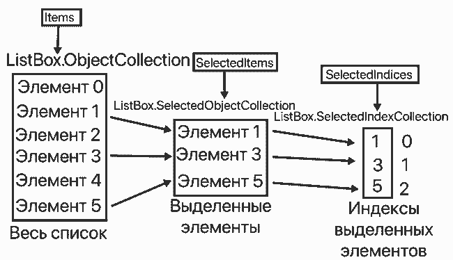

Рис. 17.5. Три коллекции элемента управления ListBox.

**Пример**. В следующем коде в обработчике события `button1_Click` выбирается три элемента из списка с помощью метода `SetSelected`. Для списка устанавливается множественный выбор. Затем отображаются значения второго элемента из коллекций `SelectedItems` и `SelectedIndices` (см. рис. 17.3, левый список).

```
private void button1_Click(object sender, EventArgs e)
{
    listBox1.SelectionMode = SelectionMode.MultiExtended;
    listBox1.SetSelected(1, true);
    listBox1.SetSelected(3, true);
    listBox1.SetSelected(5, true);
    label1.Text = listBox1.SelectedItems[1].ToString();
    label2.Text = listBox1.SelectedIndices[1].ToString();
}
```

Метод `ListBox.SetSelected` выделяет указанный элемент в `ListBox` или снимает с него выделение. С помощью этого свойства можно выделять несколько элементов в `ListBox` с множественным выбором. Если для списка с множественным выбором использовать свойства `Text`, `SelectedItem` или `SelectedIndex`, то они будут использовать только первый элемент списка.

Страница 157

**Отдельный вопрос** — как добавить в простой список новый элемент во время выполнения программы с помощью интерфейса пользователя? Поскольку простой список не имеет своего текстового поля, то такое поле вместе с соответствующей кнопкой надо создать. Для удаления выбранного элемента пользователем также необходимо предусмотреть кнопку или обработку нажатия клавиши `Del`. Иногда для выполнения этих функций можно создать отдельную форму. В отличие от добавления новой строки, для удаления элемента, являющегося объектом, никаких затруднений нет. Для этого надо определить индекс удаляемой строки и по этому номеру удалить элемент. **Пример**. В приведённом коде после удаления элемента выделяется следующий элемент.

```
private void button2_Click(obiect sender, EventArgs e)
{
    if (listBox2.Text != String.Empty)
    {
        int i = listBox2.SelectedIndex;
        listBox2.Items.RemoveAt(i);
        if (i < listBox2.Items.Count)
        { listBox2.SelectedIndex = i;}
    }
}
```

Страница 158

В результате удаления элемента, как правило, происходит событие SelectedIndexChanged. При удалении последнего элемента обработчик этого события может выдать ошибку, так как текущий индекс будет равен -1, и выделенный элемент будет отсутствовать. Чтобы избежать ошибки, вставьте проверку на отрицательное значение индекса. **Пример**.

```
private void listBox2_SelectedIndexChanged(object sender, EventArgs e)
{
    if (listBox2.SelectedIndex != -1)
    {
        label1.Text = listBox2.Text;
        label2.Text = ((Student)listBox2.SelectedItem).Name;
    }
}
```

# 17.3. Элемент управления ComboBox.

Элемент управления ComboBox представляет собой комбинацию текстового поля и простого списка. Причем по умолчанию (свойство **DropDownStyle** равно **DropDown**) отображается только текстовое поле. Такое компактное представление комбинированного списка делает его популярным элементом управления. Благодаря таким особенностям комбинированный список часто называют полем с выпадающим списком. По щелчку кнопки со стрелкой список раскрывается. Щелчком мыши по строке соответствующий элемент становится выбранным, строка выделяется цветом и отображается в текстовом поле, после чего список закрывается (см. рис. 17.1 и 17.2). Благодаря отображению текущего значения в текстовом поле списка пользователь всегда видит выбранную строку. Кроме того, пользователь может вводить в текстовое поле как существующие, так и новые значения. (Исключение составляет случай, когда свойство DropDownStyle имеет значение DropDownList и ввод запрещен.)

Страница 159

Новое значение может быть добавлено в коллекцию, если это предусмотрено разработчиком. Собственно говоря, возможность вводить в текстовое поле комбинированного списка новые значения, не ограничивая выбор пользователя, и отличает комбинированный список от простого. Комбинированный список имеет три режима отображения, определяемые свойством `DropDownStyle`, которому можно присвоить одно из трех значений перечисления `ComboBoxStyle`:

- **DropDown** — указывает, что список отображается при нажатии кнопки «стрелка вниз», а текстовая часть является редактируемой (см. рис. 17.6, слева). Это значит, что пользователь может ввести любое значение, и он не ограничен выбором из существующих значений списка. Этот стиль используется по умолчанию. В учебнике предпочтение будет отдано этому режиму.
- **DropDownList** - указывает, что список отображается при нажатии кнопки «стрелка вниз», а текстовая часть является нередактируемой (см. рис. 17.6, в центре). Это означает, что пользователь не может ввести новое значение. Строку можно выбрать мышкой (клавиатурой), при этом ускорить поиск строки можно путем ввода первой буквы. Текстовое поле такого элемента управления отображается серым цветом.
- **Simple** — указывает, что список всегда раскрыт, а текстовая часть является редактируемой (см. рис. 17.6, справа). Такой список занимает почти столько же места, как и список `ListBox`. Пользователь может ввести любое значение и не ограничен выбором из существующих значений списка.

Примечание: когда Вы помещаете раскрытый список на форму, не забудьте растянуть его по вертикали, иначе списка Вы не увидите.

Страница 160

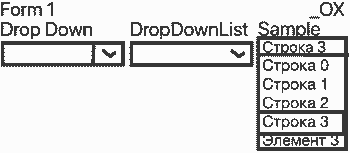

Рис. 17.6. Три режима отображения `ComboBox`

Свойство `ComboBox.AutoCompleteMode`, применяемое совместно со свойством `AutoCompleteSource`, возвращает или задает параметр, который управляет выполнением автоматического заполнения для текстового поля `ComboBox`. **Чтобы отобразить список**, в который нельзя добавить новые значения, используя текстовое поле списка, воспользуйтесь элементом управления `ListBox` или свойством `DropDownStyle` со значением `ComboBoxStyle.DropDownList`. **Поскольку текстовое поле** комбинированного списка позволяет вводить новые значения (для скалярных данных), то разработчик должен предусмотреть соответствующий интерфейс пользователя. Например, добавить новый элемент через текстовое поле можно по специальной кнопке Button, по клавише Enter, по факту потери списком фокуса и т. д. Для удаления текущего элемента также можно использовать отдельную кнопку или предусмотреть удаление по клавише Delete. Рассмотрим эти варианты.

Страница 161

# Добавление новых строк.

Когда список содержит коллекцию объектов, имеющих несколько открытых свойств (полей), для добавления нового объекта его необходимо создать. Если объект большой, эту работу проще всего выполнить в отдельном окне. Если одного значения текстового поля комбинированного списка достаточно для создания элемента коллекции `ComboBox`, то для добавления в список элемента можно использовать один из приведенных ниже примеров. **Пример**. Добавление в список новой строки, введенной в текстовое поле `ComboBox`, в обработчике события `Leave`. Это событие происходит при потере элементом фокуса ввода.

```
private void comboBox1_Leave(object sender, EventArgs e)
{
    if (comboBox1.Text | = String.Empty)
    {
        if (comboBox1.FindStringExact(comboBox1.Text) == -1)
        {
            comboBox1.Items.Add(comboBox1.Text);
        }
    }
}
```

В обработчике осуществляется поиск строки в списке, и если строка не найдена, значит это новая строка, и она добавляется в список. Добавленная строка становится текущей. Для поиска строки используется метод **FindStringExact**, возвращающий индекс строки списка, полностью совпадающей со строкой, заданной в методе. Метод не учитывает регистр! Иногда может быть полезен и метод `FindString`, который ищет вхождение подстроки. Метод возвращает индекс строки списка, в которой будет найдена заданная в методе подстрока (поиск вхождения). Метод не учитывает регистр. Оба метода возвращают значение -1, если строка или подстрока не найдена, или значение 0, если исходная строка пустая `(Empty)`. **Пример**. Добавим в список новую строку по кнопке `Button`. Рекомендуется создать кнопку с текстом "+".

```
private void button1_Click (object sender, EventArgs e)
{
    //...
    // Те же строки, что и в предыдущем примере.
}
```

Страница 162

**Пример**. Добавление в список новой строки, введенной в текстовое поле `ComboBox`, по клавише `Enter`. Чтобы отреагировать на эту клавишу, необходимо обработать событие `KeyDown`. Это событие происходит при нажатии любой клавиши, если текстовое поле комбинированного списка имеет фокус ввода. В представленном ниже обработчике выполняется проверка нажатой клавиши и, если это Enter, выполняется добавление значения.

```
private void comboBox1_KeyDown(object sender, KeyEventArgs e)
{
    if (comboBox1.Text != String.Empty)
        if (e.KeyCode == Keys.Enter)
            if (comboBox1.FindStringExact(comboBox1.Text) = = -1)
                comboBox1.Items.Add(comboBox1.Text);
}
```

# Удаление текущего элемента.

Ниже приведены универсальные алгоритмы удаления элементов. Эти алгоритмы пригодны как для списков с простыми значениями, так и для списков с объектами, имеющими несколько открытых свойств (полей). **Пример**. Удаление выбранного элемента клавишей `Delete` в обработчике события `KeyDown`.

```
private void comboBox1_KeyDown(object sender, KeyEventArgs e)
{
    int i = comboBox1.SelectedIndex;
    if (i > -1 && e. KeyCode = = Keys.Delete)
        comboBox1.Items.RemoveAt(i);
}
```

**Пример**. Удаление выбранной строки по кнопке Button. Рекомендуется создать кнопку с текстом "_".

```
private void button 1_Click object sender, EventArgs e)
{
    int i = comboBox1.SelectedIndex;
    if (i > -1)
        comboBox1.Items.RemoveAt(i);
}
```

Страница 163

**Пример**. Удаление выбранной строки по кнопке `Button` с выделением следующей строки. При последовательном удалении нескольких смежных элементов пользователь будет вынужден после каждого удаления открывать комбинированный список и выделять очередную строку. Для преодоления этого неудобства разработчику целесообразно добавить программное выделение строки, следующей за удаленной. Когда удаляется последний элемент списка, его строковое представление продолжает отображаться в текстовом поле `ComboBox`, поэтому в примере это поле очищается.

```
private void button1_Click(object sender, EventArgs e)
{
    int i = comboBox1.SelectedIndex;
    if (i > -1)
    {
        comboBox1.Items.RemoveAt(i);
        if (i < comboBox1.Items.Count )
        { comboBox1.SelectedIndex = i;}
        else {comboBox1.Text = String.Empty;}
    }
}
```

Страница 164

# 17.4. Элемент управления CheckedListBox.

Список с флажками (CheckedListBox) — это постоянно раскрытый список ListBox, где слева от каждой строки отображается флажок (см. рис. 17.1, 17.2). Заголовок класса CheckedListBox: `public class CheckedListBox : ListBox`. Как следует из заголовка, элемент управления `CheckedListBox` является расширением элемента управления `ListBox`. Он выполняет практически все функции списка, а кроме того, в нем может отображаться галочка рядом со строкой списка. Другое различие между этими элементами управления заключается в том, что в списках с отмеченными элементами можно выделить только один элемент или не выделить ни одного. Установить или сбросить флажок можно только у выбранного (выделенного) элемента. Чтобы установить или сбросить флажок, можно использовать также двойной щелчок мышки на невыделенном элементе. Элемент с установленным флажком называется отмеченным. Текущее выделение элемента снимается, когда выделяется другой элемент, однако это не изменяет состояние флажка. В списке могут одновременно находиться несколько элементов с установленными флажками и только один с выделенным текстом. На рис. 17.1 показаны два элемента с отмеченными флажками и один элемент выбранный. Если выбранный элемент с неотмеченным флажком щелкнуть, то флажок будет установлен (см. рис. 17.2). Если флажок у выбранного элемента был ранее установлен, то он будет сброшен. Поскольку элемент управления `CheckedListBox` наследует члены класса `ListBox`, то для работы с коллекцией всех элементов `(CheckedListBox.ObjectCollection)` используются те же средства, что и для элемента управления `ListBox`: `Items`, `Text`, `SelectedIndex`, `SelectedItem`, `Sorted`, `UseTabStops` и др.

Страница 165

Каждый элемент списка CheckedListBox, независимо от того, выделен он или нет, может иметь одно из трех состояний, определяемых флажком. Эти значения являются членами перечисления CheckState: во-первых, Unchecked — флажок снят (не отмечен); во-вторых, Checked — флажок установлен (отмечен); в-третьих, Indeterminate — флажок находится в неопределенном состоянии. Такой флажок обычно затенён (недоступен). По умолчанию это значение не используется. Установить это значение можно только в коде, например, с помощью метода SetItemCheckState. Отмеченные элементы (включая элементы в неопределенном состоянии) образуют коллекцию CheckedListBox.CheckedItemCollection, а индексы этих элементов — коллекцию CheckedListBox.CheckedIndexCollection. Эти коллекции доступны через свойства CheckedItems и CheckedIndices соответственно.

# Работаем с коллекцией отмеченных элементов.

Заметим, свойства SelectedItem и SelectedIndex не определяют помеченный элемент: они определяют выделенный элемент. Приведем список членов класса CheckedListBox, не совпадающих с унаследованными членами класса ListBox и используемых ниже для работы с отмеченными элементами. Методы: Если Вы не собираетесь использовать состояние `Indeterminate`, то Вам могут пригодиться следующие методы: GetItemChecked — возвращает значение, указывающее, отмечен ли заданный элемент. SetItemChecked — устанавливает для состояния CheckState элемента с заданным индексом значение Checked или Unchecked. Параметры метода: индекс элемента и значение true, чтобы задать элемент как отмеченный (Checked); в противном случае — значение false. Если Вы собираетесь использовать состояние Indeterminate, Вы наверняка будете использовать следующие методы: GetItemCheckState — возвращает значение, указывающее состояние проверки текущего элемента. SetItemCheckState — задает состояние проверки элемента с указанным индексом. Параметры метода: индекс элемента, для которого требуется задать его состояние, и одно из значений перечисления CheckState. Метод $SetItemCheckState вызывает событие ItemCheck.

Страница 166

**Свойства**: **CheckedIndices** — коллекция отмеченных индексов в данном элементе управления `CheckedListBox`. **CheckedItems** — коллекция отмеченных элементов в данном элементе управления `CheckedListBox`. **CheckOnClick** — получает или задает значение `(true/false)`, указывающее, следует ли переключить флажок, когда выбирается элемент. По умолчанию — не следует `(false)`. **События**: **SelectedIndexChanged** — происходит при щелчке мыши по любой части строки списка, включая флажок. **ItemCheck** — происходит при изменении состояния флажка. Сначала происходит событие, а затем отображается новое состояние флажка. Обработчику события передается параметр е с двумя важными свойствами: **Index** — индекс элемента, флажок которого меняет состояние; **NewValue** — новое состояние флажка (`Checked`/`Unchecked`), которое будет установлено вместо текущего. Доступ к коллекции отмеченных элементов можно получить с помощью свойства `CheckedItems`. Также можно перебрать элементы исходного списка с помощью метода `GetItemChecked`, чтобы определить, какие элементы помечены. Метод `GetItemChecked` принимает номер элемента в качестве аргумента и возвращает значение `true` или `false`.

Страница 167

**Пример**. Вывод всех помеченных элементов. В примере осуществляется перебор элементов коллекции `Checkeditems` и вывод сообщения в формате: «Помеченный элемент: Строка 3» ...

```
private void button1_Click(object sender, EventArgs e)
{
    string s = "";
    foreach (var v in checkedListBox1.CheckedItems)
        s += "\пПомеченный элемент: " + v;
    MessageBox.Show(s);
}
```

Если разработчик хочет в цикле поменять состояние какого-либо флажка, то вместо `foreach` необходимо использовать цикл `for`:

```
for (int i = 0; i < checkedListBox1.CheckedItems.Count; i++)
    s += "\пПомеченный элемент: " + checkedListBox1.CheckedItems[i];
```

**Пример**. Вывод всех помеченных элементов. Этот пример отличается от предыдущего тем, что здесь осуществляется перебор всех элементов исходной коллекции `Items` и вывод помеченных элементов. Для определения состояния флажка элемента используется метод `GetItemChecked`.

```
private void button1_Click(object sender, EventArgs e)
{
    string s = "';
    for (int i = 0; i < checkedListBox1.Items.Count; i++)
        if (checkedListBox1.GetItemChecked(i) == true)
            s += "\пПомеченный элемент: " + checkedListBox1.Items[il;
    MessageBox.Show(s);
}
```

Страница 168

**Пример**. В приведённом обработчике события `ItemCheck` отслеживается переход всех флажков в состояние `Unchecked`. Если отмеченных флажков нет, то кнопка button1 (см. предыдущий пример) становится неактивной. Как только появится первый отмеченный флажок, кнопка снова станет активной. Для решения этой задачи проверяется, станет ли текущий элемент неотмеченным. Если при этом в списке отмеченных элементов находится всего один элемент, то после выхода из обработчика события `ItemCheck` список станет пустым. Для пустого списка кнопка `button1` становится неактивной.

```
void checkedListBox1_ItemCheck(object sender, ItemCheckEventArgs e)
{
    if (e.NewValue == CheckState.Unchecked)
        if (checkedListBox1.CheckedItems.Count == 1)
        { button1. Enabled = false; }
        else { button1. Enabled = true; }
}
```

**Пример**. Программное изменение состояния флажков четных элементов. Для изменения используется метод `SetItemChecked`.

```
private void button1_Click(object sender, EventArgs e)
{
    for (int i = 0; i < checkedListBox1.Items.Count; i += 2)
    { checkedListBox1.SetItemChecked(i, true); }
}
```

Страница 169

# 17.5. Изменение объектов коллекции.

Если коллекция списочного элемента управления состоит из значимых типов данных, то их изменение сразу же отображается на экране. Например, после выполнения следующего оператора `listBox1.Items[11] = 777;` на экране появится новое значение. Однако, если коллекцией списочного элемента управления являются объекты, а точнее, ссылки на объекты, то при изменении какого-либо объекта на экране продолжает отображаться старое значение и перерисовать его не удается, даже если использовать методы `Refresh` или `Update`. Рассмотрим это явление на примере. Пусть у нас имеется простейший класс:

```
class MyClass
{
    public int P1 { get; set; }
    public int P2 { get; set; }
}
```

В обработчике `Form1_Load` мы заполняем элемент управления `listBox` ссылками на объекты класса `MyClass`:

```
private void Form1_Load(object sender, EventArgs e)
{
    listBox1.Items.Add(new MyClass { P1 = 0, P2 = 90 });
    listBox1.Items.Add(new MyClass { P1 = 1, P2 = 91 });
    listBox1.Items.Add(new MyClass { P1 = 2, P2 = 92 });
    listBox1.Items.Add(new MyClass { P1 = 3, P2 = 93 3);
    listBox1.Items.Add(new MyClass { P1 = 4, P2 = 94 });
    listBox1.DisplayMember = "P1";
    listBox1.SelectedIndex = 0;
}
```

Страница 170

Если мы изменим поле какого-либо объекта, например второго (индекс = 1), следующим образом: `((MyClass)listBox1.Items[1]).P1 = 555;` то в элементе управления по-прежнему будет отображаться значение 1. Но это противоречие как раз объяснимо: мы меняем поле в неподконтрольном элементу управления объекте. Необъяснимым является, почему методы `listBox1.Refresh() и listBox1.Update()` не обновляют вывод, хотя они предназначены для перерисовки элемента управления. Рекомендуется из этой ситуации выходить следующим образом: сначала удаляем объект из списка, а затем вставляем измененный объект на место удаленного:

```
private void Изменить_Click(object sender, EventArgs e)
{
    listBox1.Items.RemoveAt(1);
    listBox1.Items.Insert(1, new MyClass { P1 = 777, P2 = 91 });
}
```

Другой способ: после всех изменений заново определить свойство `DisplayMember`:

```
((MyClass)listBox1.Items[1]).P1 = 555;
comboBox1.DisplayMember = null;
comboBox1.DisplayMember = "P1";
```

Страница 171

# 17.6. Задания для самостоятельной работы.

**Задача 1**. Разработать Windows-приложение, в котором создать класс Book с полями: название книги, автор, жанр, год издания. Создать библиотеку книг (`List<Book>`) и отобразить ее в табличном виде: в многострочном `TextBox`; в списке `ListBox`; Название книги должно вводиться в `TextBox`, автор выбираться из `ComboBox`, жанр задаваться переключателями `RadioButton`, а год издания вводиться в `TextBox`. Предусмотреть возможность добавления и удаления авторов.

**Задача 2**. Разработать Windows-приложение, в котором создать класс `Student`. Поля класса: фамилия, средний балл, характеристика успеваемости (отстающий, посредственный, хорошист, отличник), несданные предметы (математика, информатика, экономика). Для создания объектов использовать элементы управления: для отображения фамилий — `ComboBox`, для отображения несданных предметов — `CheckedListBox`, для отображения характеристики успеваемости — `RadioButton`, среднего балла — `TextBox`. После выборки значений из перечисленных элементов управления по кнопке `Button` включить студента в список `List<Student>` и отобразить список студентов в `ListBox`.

**Задача 3**. Разработать Windows-приложение для предметной области «Коммунальные платежи». В форме обязательно использовать следующие элементы управления: списки `ListBox`; комбинированный список `ComboBox` с возможностью добавления и удаления абонентов; переключатели; рамки; надписи; кнопки.

Страница 172

Разработать базовый абстрактный класс «Платеж» и производные классы «Электро» и «Газ». Базовый класс «Платеж» должен иметь следующие члены: **во-первых**, поле (свойство) фамилия плательщика; **во-вторых**, абстрактные методы: вычисление суммы оплаты; формирование сводной информации в виде строки по одному платежу. Производный класс «Электро», описывающий платеж за электроэнергию, должен иметь следующие члены: поля (свойства): **во-первых**, текущее показание счетчика; **во-вторых**, предыдущее показание счетчика; **в-третьих**, тариф (стоимость одного киловатта). **Производный класс** «Газ», описывающий платеж за газоснабжение, должен иметь следующие члены: поля (свойства): количество проживающих человек; тариф (стоимость оплаты за одного проживающего). Абстрактные методы базового класса в производных классах должны быть реализованы. Все платежи должны накапливаться в базе, которая должна имитироваться динамическим массивом `List<Платеж>`, занесение платежа в базу выполняется пользователем по кнопке. Вместо списка `List<Платеж>` для хранения платежей можно использовать непосредственно списки `ListBox`. Количество платежей заранее неизвестно. Пользователю должны быть предоставлены следующие функциональные возможности: **во-первых**, занесение в базу платежа; **во-вторых**, получение справки обо всех платежах за электроэнергию; **в-третьих**, получение справки обо всех платежах за газоснабжение; **в-четвертых**, вычисление итоговой суммы по всем платежам.

Страница 173

Текстовые поля, не относящиеся к текущему виду энергии, должны быть недоступны. Примерный вид формы показан на рис. 17.7. Внешний вид формы не является примером для подражания, он может быть улучшен. Например, информацию в списки желательно выводить в табличном виде с выровненными по вертикали колонками.

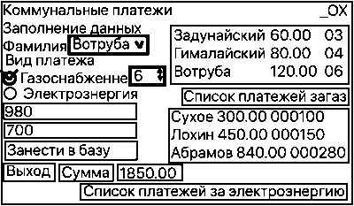

Рис. 17.7. Окно программы.

Страница 174

# 18. ПРИВЯЗКА К ИСТОЧНИКУ ДАННЫХ.

### 18.1. Общие сведения

Рассматривая ранее списочные элементы управления, мы не раз отмечали, что эти элементы могут заполняться данными из внешнего источника. Это заполнение можно выполнить вручную, с помощью циклов. Например, пусть в нашем распоряжении имеется список list типа List и мы хотим отобразить строки этого списка в элементе управления comboBox1, для чего разрабатываем следующий метод:

```
//--Создать список ComboBox--
private void CreateComboBoxList<string> list)
{
    comboBox1.Items.Clear();
    foreach (var g in list)
        if (IcomboBox1.Items.Contains(g))
            comboBox1.Items.Add(g);
}
```

Метод `CreateComboBox` получает в качестве аргумента список и записывает его уникальные строки в элемент управления `comboBox1`. Метод `Contains` определяет, входит ли указанный элемент в данную коллекцию, при этом метод учитывает регистр, то есть строки «жасмин» и «Жасмин» — это разные строки.

Страница 175

**Примечание**. В данном учебнике в примерах часто используются имена элементов управления, генерируемые по умолчанию средой разработки Visual Studio. Эти имена образуются от типа элемента управления с добавлением порядкового номера элемента в форме. Например, элементы управления `label1` и `label2` — это первый и, соответственно, второй объекты типа `Label`. Аналогично: `textBox1` и `textBox2` — это первый и, соответственно, второй объекты типа `TextBox`. То же правило применяется и к другим элементам управления. Используя такие имена объектов, мы будем считать, что читатель понимает, от какого класса они созданы. Следует отметить, что если какой-либо один или оба списка будут изменяться в процессе выполнения программы, то разработчик должен решить задачу синхронизации списков: изменится один список, требуется изменить и другой. Поэтому использование внешних данных для разработчика представляет определенную трудность. Но, к счастью, система программирования для решения этой задачи предоставляет специальный механизм, позволяющий выполнить так называемую привязку элемента управления к источнику данных, используя специальные свойства элемента управления. При этом разработчик освобождается от решения вопросов загрузки данных и их синхронизации. Под привязкой визуального элемента управления к источнику данных понимают процесс, при котором элемент управления выбирает данные из указанного для него источника. При этом исходная коллекция элементов перед привязкой очищается.

Механизм привязки устанавливает взаимосвязь между элементом управления и данными его источника, при этом изменение данных в источнике приводит к изменению их отображения в элементе управления. Это в идеале. На практике для многих поточников надо использовать специальный метод, который приводит к обновлению привязки и отображению элемента управления. В зависимости от того, каким является элемент управления — простым (не содержащим коллекции элементов) или списочным (содержащим коллекции элементов), — используются разные механизмы привязки. К простым элементам управления относятся `TextBox`, `Label` и др., к списочным — `ListBox`, `ComboBox`, `DataGridView` и др. Для привязки простых элементов управления используют простую привязку к одиночному значению, а списочных — сложную привязку к списку значений. Для простой привязки используется класс Binding, а для сложной — BindingSource. Эти классы исследуют источник данных, причем во внимание принимаются только открытые свойства. Открытые поля игнорируются. Поскольку для реализации простой привязки рекомендуется использовать класс BindingSource, рассмотрим сначала сложную привязку как наиболее востребованную. Особое место в технологии привязок занимает окно «Источники данных». В этом окне отображаются источники данных в проекте, такие как базы данных, веб-службы и объекты. Можно создавать элементы управления с привязкой к данным, перетаскивая элементы из окна «Источники данных» на форму. Можно также осуществить привязку существующих элементов управления к данным путем перетаскивания объектов из окна источников данных на существующие элементы управления.

Страница 176

# 18.2. Сложная привязка ОСНОВНЫЕ СВЕДЕНИЯ.

Привязка называется «сложной» не потому, что она является сложной для использования разработчиком (как раз здесь всё просто), а потому что источник данных является сложной, многострочной структурой данных. Чаще всего — это список (массив) объектов, которые заданным образом необходимо отобразить в многострочном элементе управления. К элементам управления, поддерживающим сложную привязку к источнику, относятся `ListBox`, `ComboBox`, `DataGridView`, `DataView`, `BindingSource` и др. Для реализации привязки элементов управления к источнику данных эти элементы предоставляют свойство DataSource, которое возвращает или задает источник данных для элемента управления (компонента).

Страница 177

### Примечание

Поскольку независимо от списочного элемента управления для привязки используются одни и те же свойства, все примеры будут приведены для элемента управления `listBox` типа `ListBox`. В качестве источника данных будем рассматривать список `list` типа `List<MyClass>`, содержащий объекты следующего класса:

```
class MyClass
{
    public int P1 ( get; set;
    public int P2 ( get; set; )
}
```

Используются два способа сложной привязки элемента управления: непосредственно к источнику данных и через посредника.

**Пример**. Привязать `listBox1` непосредственно к списку объектов `list` типа `List<T>`. `listBox1.DataSource = list;` При использовании привязки элемента управления к источнику данных возникает ряд проблем. Главная из них состоит в следующем: как известно, источник данных в процессе работы программы чаще всего претерпевает изменения: добавляются новые объекты, какие-то удаляются, свойства объектов получают новые значения. Если источник изменился, то необходимо, чтобы привязанный к этому источнику элемент управления был об этом извещен. Тогда элемент управления перерисует отображение объектов на экране. Так должно быть. Однако на практике многие источники данных — массивы, списки `List<T>` и др. — никаких уведомлений не посылают. К числу источников данных, которые уведомляют привязанные элементы управления, относятся `BindingList`, `BindingSource` и некоторые другие.

Страница 178

Кроме того, источники данных могут иметь разную природу и отличаться друг от друга. Не со всеми источниками данных одинаково успешно может взаимодействовать элемент управления. Поэтому для решения этой проблемы был разработан компонент `BindingSource`, который можно использовать в качестве универсального связующего средства между элементами управления в форме и источником данных (см. рис. 18.1). То есть `BindingSource` является посредником, который берет на себя функции детального исследования источника данных и уведомления привязанного к нему элемента управления о необходимости перерисовать список. Класс `BindingSource` иногда называют соединителем.

- Элемент управления <-> BindingSource <-> Источник данных

Рис. 18.1. Использование посредника в сложной привязке.

При использовании соединителя элемент управления с помощью свойства `DataSource` привязывается не к источнику данных, а к компоненту `BindingSource`, который для элемента управления становится источником данных. Компонент `BindingSource` (объект `bindingSource1`), в свою очередь, привязывается к источнику данных с помощью своего свойства `DataSource`.

**Пример**. Использование соединителя для привязки элемента управления `listBox1` к списку `list`.

```
bindingSource1.DataSource = list.
listBox1.DataSource = bindingSource1;
```

# Источники данных.

В качестве источников данных для сложной привязки можно использовать массивы `Агау`, коллекции `ArrayList`, `List<T>` и `BindingList<T>`, таблицы `DataTable` и представления `DataView ADO.NET` и многие другие. Можно не перечислять все источники, а ограничиться следующим комментарием: при сложной привязке обычно требуется, чтобы объект поддерживал интерфейс `IList` или `IListSource`. Так как эти интерфейсы определяют список объектов, организованных в коллекцию, то сложная привязка данных также называется привязкой на основе списка.

Страница 179

Если при привязке используется компонент `BindingSource`, можно выполнить привязку к объекту, поддерживающему также интерфейс `IEnumerable`. Таким объектом, например, является последовательность, возвращаемая `LINQ`-запросом. (Присвятой LINQ To Objects.) Компонент `BindingSource` копирует все элементы `IEnumerable` в отдельный список `List`, предназначенный исключительно для привязки. Все коллекции и массивы (а также класс `CollectionBase`) реализуют интерфейс `IList`. Эти классы представляют собой индексированные списки объектов типа `Object`. Такие элементы управления называют объектами на основе списков. Обратите внимание, какое количество интерфейсов наследует класс `List<T>`:

```
public class List<T> : IList
    , IList<T>
    , ICollection, ICollection<T>
    , IEnumerable, IEnumerable<T>
```

Как видите, если есть универсальный интерфейс, то должен быть и неуниверсальный. Класс, реализующий интерфейс `IListSource`, обеспечивает привязку на основе списка для объектов, не являющихся списками. Метод `GetList` объекта `IListSource` используется, чтобы возвратить связываемый список из объекта, не наследующего от списка `IList`. Объект `IListSource` используется классом `DataSet`. Компонент `BindingSource` расширяет перечень доступных для привязки источников данных. К примеру, такие элементы управления, как `DataGridView` и `ComboBox`, не поддерживают привязку непосредственно к источникам данных `IEnumerable`, однако такую привязку можно осуществить посредством компонента `BindingSource`. В этом случае компонент `BindingSource` преобрадует источник данных в интерфейс `IList`. Можно создать источники данных из баз данных, служб или объектов. Можно перетащить элементы из окна «Источник данных» в рабочую область конструирования проекта для создания элемента управления с привязкой данных к свойствам выбранного объекта. Список значений в качестве источника данных можно создать с помощью запроса Linq.

Страница 180

# Отображаемое и возвращаемое свойства источника.

У элементов управления ListBox и ComboBox есть несколько полезных свойств, часто используемых совместно с привязкой:

- **DisplayMember** — определяет свойство источника данных, значение которого будет отображаться в элементе управления.
- **ValueMember** - возвращает или задает свойство источника данных, значение которого извлекается из текущего объекта.
- **SelectedValue** — возвращает или задает значение свойства, определенного свойством ValueMember.

У сетки DateGridView и компонента BindingSource перечисленных свойств нет, но есть свойство DataMember, которое указывает подсписок или таблицу источника данных. **Если объекты** источника данных имеют несколько открытых свойств, то требуется уточнение — какое свойство источника следует отображать на экране в списке ListBox или ComboBox, а какое свойство будет возвращать значения. Это уточнение делается с помощью таких свойств списка, как DisplayMember и (соответственно) ValueMember. Значением каждого из этих свойств является имя свойства источника, представленное в виде строки, например, для свойств класса, приведённого выше, конкретизация свойств может выглядеть следующим образом:

```
listBox1.DisplayMember = "P1";
listBox1.ValueMember = "P2";
```

Следует отметить, значение свойства P2 выбирается из объекта, соответствующего выбранной, то есть текущей строке списочного элемента управления.

Страница 181

# Члены класса BindingSource и область их применения.

Приведем описание некоторых членов класса `BindingSource`. В описании используется термин «базовый источник данных». Этим источником является список объектов, к которому привязан `BindingSource`.

### Свойства класса `BindingSource`:

- **this[индекс]** - индексатор. Возвращает или задает элемент базового списка по указанному индексу.
- **List** — получает базовый список, к которому привязан соединитель.
- **Count** — получает общее число элементов в базовом списке.
- **Current** — получает текущий элемент в базовом списке.
- **DataMember** — возвращает или задает список в источнике данных, к которому в настоящий момент привязан соединитель.
- **DataSource** — возвращает или задает источник данных, к которому привязан соединитель.
- **Position** - возвращает или задает индекс текущего элемента в базовом списке.

Свойством по умолчанию в классе `BindingSource` является свойство `DataSource`. Методы `BindingSource` для работы со списком источника данных:

- **Add** — добавляет существующий элемент в базовый список.
- **AddNew** — создает новый объект с помощью конструктора по умолчанию и добавляет его в базовый список.
- **ApplySort** — сортирует источник данных, используя задавные описания сортировки.
- **CancelEdit** - отменяет текущую операцию редактирования
- **Clear** — удаляет все элементы из базового списка, представ ленного свойством `List`, и устанавливает свойство `Count` в значение О.
- **СоруТо** — копирует содержимое списка, представленно свойством List, в указанный массив, начиная с указанного индекса. Этот метод служит для объединения элементов из нескольких неточников в один массив.
- **EndEdit** - применяет незавершенные изменения к базовому неточнику данных.
- **Fin** — возвращает индекс элемента в базовом списке, имеющего заданное имя свойства и значение.
- **IndexOf** - осуществляет поиск указанного объекта и возвращаст индекс первого вхождения в пределах списка.
- **Insert** — вставляет элемент в список по указанному индексу.
- **Remove** — удаляет заданный элемент из базового списка.

Страница 182

- **RemoveAt** — удаляет элемент по указанному индексу из базового списка.
- **RemoveCurrent** - удаляет текущий элемент из базового списка.
- **RemoveFilter** - удаляет фильтр, сопоставленный с компонентом `BindingSource`.
- **RemoveSort** — удаляет сортировку, сопоставленную с компонентом `BindingSource`.
- **ResetBindings** — вызывает в элементе управления, привязанном к компоненту `BindingSource`, повторное считывание всех элементов списка и обновление их отображаемых значений.
- **ResetCurrentItem** — вызывает в элементе управления, привязанном к компоненту `BindingSource`, повторное считывание выбранного элемента списка и обновление его отображаемого значения.
- **ResetItem** — вызывает в элементе управления, привязанном к компоненту `BindingSource`, повторное считывание элемента списка по указанному индексу и обновление его отображаемого значения.
- **ResumeBinding** - вызывает привязку данных.

В классе `BindingSource` есть несколько событий. Событием по умолчанию является `CurrentChanged`. Если элемент управления `listBox1` привязан к соединителю `bindingSource1`, который в свою очередь привязан к списку `list` типа `List<T>` или `BindingList<T>`, то выполняются следующие зависимости:

```
bindingSource1.DataSource эквивалентно list
bindingSource1.List эквивалентно list
bindingSource1.DataSource эквивалентно bindingSource1.List
listBox1.Items[1] эквивалентно list[1]
listBox1.Items не эквивалентно list
```

То есть соединитель в своих свойствах List и DataSource хранит ссылку непосредственно на источник данных. Списковый элемент управления также хранит ссылки на объекты источника.

Страница 183

# Примеры сложной привязки.

Приведем несколько примеров сложной привязки, отличающихся источниками данных. Предполагается, что объект `bindingSource1` типа `BindingSource` создан автоматически при перетаскивании компонента на форму.

**Пример**. В приведённом фрагменте программы осуществляется создание списка `list` объектов `MyClass`. Далее выполняется сложная привязка элемента управления `ListBox` к списку `list`. Отображаемым в `ListBox` свойством источника определено свойство `Р1`, а возвращающим значение — `P2`.

```
List<MyClass> list;
private void Form1_Load(object sender, EventArgs e)
{
    list = new List<MyClass>();
    list.Add(new MyClass { P1 = 0, P2 = 90 });
    list.Add (new MyClass { P1 = 1, P2 = 91 });
    list. Add(new MyClass { P1 = 2, P2 = 92 }):
    list.Add(new MyClass { P1 = 3, P2 = 93 });
    list.Add(new MyClass { P1 = 4, P2 = 94 });
    bindingSource1.DataSource = list;
    listBox1.DataSource = bindingSource1;
    listBox1.DisplayMember = "P1";
    listBox1.ValueMember = "P2";
}
```

Страница 184

Для сложных источников данных, таких как таблицы базы данных или списки списков, можно дополнительно указать в свойстве `DataMember` определенный столбец в таблице или список в источнике данных. Затем выполнить привязку элемента управления к компоненту `BindingSource`.

**Пример**. Сложная привязка ComboBox к колонке «ИмяПродукта» таблицы «Продукты».

```
// Привяжем объект bindingSource1 к таблице "Продукты"
// базы данных MyDataSet.
bindingSource1.DataSource = MyDataSet;
// Выбираем конкретную таблицу.
// bindingSource1.DataMember = "Продукты";
// Так как ComboBox отображает в каждой строке
// только одно значение, то привяжем ComboBox к bindingSource1
// и укажем столбец "ИмяПродукта" для вывода в список
comboBox1.DataSource = bindingSource1;
comboBox1.DisplayMember = "ИмяПродукта";
```

Страница 185

**Пример**. Привязка сетки `DataGridView` ко всей таблице «Продукты». Каждая колонка `DataGridView` отображает один столбец таблицы, поэтому `DisplayMember` задавать не нужно.

```
bindingSource1.DataSource = MyDataSet;
bindingSource1.DataMember = "Продукты";
dataGridView1.DataSource = bindingSource1;
```

**Пример**. Сложная привязка `ComboBox` к перечислению `SeriesChartType`.

```
bindingSource1.DataSource = Enum.GetValues(typeof(SeriesChartType));
comboBox1.DataSource = bindingSource1;
```

Особенность привязки к перечислению состоит в том, что, несмотря на то что привязка осуществляется к числовым значениям констант перечисления, отображаются не числа, а имена этих констант. Связано это с тем, что перед отображением числовых значений применяется метод ToString, а он возвращает имя константы. Однако свойство comboBox1.SelectedValue возвращает числовое значение: chartType = (SeriesChartType)comboBox1.SelectedValue; Если выполнить привязку к массиву имен: bindingSource1.DataSource = Enum.GetNames(typeof(SeriesChartType)); то свойством SelectedValue будет возвращаться имя.

# Изменение источника данных.

Ряд из перечисленных выше методов обеспечивает косвенное обращение компонента BindingSource к источнику данных, например, метод RemoveAt компонента перенаправляется источнику данных. Поэтому источники данных, например List, должны содержать соответствующие методы, что гарантируется унаследованными интерфейсами.

**Пример**. В следующих операторах осуществляется добавление нового объекта в базовый список и удаление из этого списка объекта с индексом 0. Метод `Add` соединителя выполняет как минимум две функции: вызывает метод `List<MyClass>.Add` базового списка, используя ссылку на него в свойстве `BindingSource.List`, и уведомляет элемент управления об изменении базового списка: элемент управления будет перерисован.

```
bindingSource1.Add(new MyClass { P1 = 555, P2 = 555 });
bindingSource1.RemoveAt(0);
```

Таким образом, соединитель BindingSource упрощает взаимодействие элемента управления с источником данных за счет создания уведомлений об изменении списка источника, который (список) не создает уведомлений. Для решения задач изменения списка источника данных можно использовать методы не соединителя, а самого списка.

Страница 186

**Пример**. В следующих строках демонстрируется работа с базовым списком, минуя соединитель. Осуществляется добавление нового объекта и удаление объекта, находящегося на нулевой позиции.

```
list.Add(new MyClass { P1 = 66, P2 = 97 });
list.RemoveAt(0);
```

**Обратите внимание**: свойство `List` соединителя возвращает ссылку на базовый список, через которую можно получить доступ к членам класса источника данных. К таким членам относятся, например, методы `Add` и `RemoveAt`, использование которых было продемонстрировано в примере.

**Пример**. Ниже приведены операторы, которые вызывают те же методы, что и в предыдущем примере, но через свойство `List` соединителя.

```
bindingSource1.List.Add(new MyClass { P1 = 555, P2 = 555 });
bindingSource1.List.RemoveAt(0);
```

Если списочный элемент привязан к источнику данных, то нельзя изменять список этого элемента управления (добавлять, удалять, присваивать новое значение). Как уже говорилось, изменять надо источник данных. По этой же причине привязанные элементы управления не выполняют и сортировку своего списка. Чтобы отобразить отсортированные данные в элементе управления, необходимо отсортировать источник данных.

**Примечание**. Данные ограничения не в полной степени справедливы для элемента управления `DataGridView`. К элементу управления `CheckedListBox` невозможно привязать список. Вместо этого для привязки используйте элемент управления `ComboBox` или `ListBox` или выполняйте заполнение списка `CheckedListBox` вручную.

Страница 187

# ПЕРЕРИСОВКА ЭЛЕМЕНТА УПРАВЛЕНИЯ.

Страница 188

**Пример**. Ниже приведены три оператора, одинаковым образом изменяющие свойство `Р1` первого объекта списка типа `List<T>` или `BindingList<T>`. Первый оператор использует индексатор списка `list`, второй — индексатор соединителя, возвращающий ссылку на объект, и третий — индексатор свойства `List` соединителя, возвращающего ссылку на список.

1. list[0].P1=77;
2. ((MyClass)bindingSource1[0]).P1 = 77;
3. ((MyClass)bindingSource1.List[0]).P1 = 77;

Никакого уведомления эти строки не создают. Дело в том, что в примере меняется свойство P1 пользовательского класса, и при этом на выполнение вызывается не системный метод (типа `Add`, `Remove` и др.), а аксессор `set` этого свойства. В пользовательском классе `MyClass`, используемом в примерах, в аксессорах `set` механизм извещений не реализован. Так как пользовательские классы, как правило, не содержат код, уведомляющий привязку об изменении значений своих свойств, то рекомендуется после каждого изменения значения свойства обновлять отображение элемента управления. Для обновления привязки и перерисовки элемента управления компонент `BindingSource` содержит методы: `ResetItem`, `ResetCurrentItem` и `ResetBindings`. Эти методы вызывают повторное считывание (одной или всех строк) из источника данных и обновление отображения считанных данных в элементе управления, привязанном к компоненту `BindingSource`. Обновить можно: отдельный элемент с указанным индексом (`ResetItem`); текущий элемент (`ResetCurrentItem`); все элементы (`ResetBindings`). Повторное считывание уведомляет элемент управления о необходимости обновить отображение (одной или всех строк).

Страница 189

- **Пример**. Обновим и перерисуем нулевую строку элемента управления. `bindingSource1.ResetItem(0);`
- **Пример**. Обновим и перерисуем все строки элемента управления. `bindingSource1.ResetBindings(false);`

Если вместо вызова метода `bindingSource1.ResetBindings` (или подобного) Вы попытаетесь обновить привязку, повторно присвоив свойству `bindingSource1.DataSource` ссылку на источник данных, то `BindingSource` это проигнорирует, так как ссылка на источник не изменилась. Компонент `BindingSource` автоматически обнаруживает изменения в источнике данных, когда тип, содержащийся в этом источнике, реализует интерфейс `INotifyPropertyChanged` и вызывает события `PropertyChanged` при изменении значения свойства. Это очень удобно, поскольку элементы управления, связанные с компонентом `BindingSource`, будут автоматически обновляться при изменении значений источника данных.

Страница 190

# Добавление нового объекта в ComboBox.

При добавлении нового объекта в список источника данных, привязанный к элементу управления ComboBox, происходит обновление привязки, и это приводит к тому, что в текстовом поле `(ComboBox.Text)` элемента управления всегда будет отображаться первый объект списка, а не добавленный. Покажем, как можно решить эту проблему. Ниже приведен обработчик, добавляющий новый объект по клавише `Enter`.

```
private void comboBox1_KeyDown(object sender, KeyEventArgs e)
{
    if (comboBox1. Text ! = String.Empty)
        if (e.KeyCode == Keys. Enter)
            if (comboBox1.FindStringExact(comboBox1.Text) = = -1)
            {
                list.Add(int.Parse(comboBox1.Text));
                comboBox1.SelectedIndex = comboBox1.Items.Count - 1;
            }
}
```

Поскольку добавленная в список строка является последней, она и выбирается в текстовое поле с помощью свойства `SelectedIndex`.

Страница 191

# РЕЖИМ ВИЗУАЛЬНОЙ ПРИВЯЗКИ.

Компонент `BindingSource` находится в окне элементов, поэтому его можно перетащить на форму. При этом автоматически создастся объект, а на панели компонентов отобразится имя этого объекта. Далее Вы можете выполнить привязку соединителя к источнику данных, используя окно свойств. На этом этапе Вы можете привязаться, как правило, только к типу объектов источника данных. Такую привязку рекомендуется выполнять для элемента управления `DataGridView`, в котором открытые свойства объектов источника отображаются в виде столбцов с заголовками, соответствующими именам свойств.

**Пример**. В примере выполняется привязка сетки `DataGridView` к типу `Student`.

```
bindingSource1.DataSource = typeof(Student);
dataGridView1.DataSource = bindingSource1;
```

После привязки сетки DataGridView к типу Student отобразится таблица со столбцами, озаглавленными именами открытых свойств источника данных. Несмотря на то что таблица будет пустой, можно продолжить её настройку в визуальном режиме. Например, можно откорректировать ширину столбцов, их заголовки, цвет текста и т. д. Позже в программе нужно будет выполнить привязку к реальному списку объектов типа Студент, например:

```
List<Студент> list = new List <Студент>);
...
bindingSource1.DataSource = list;
```

Подробно такая привязка будет изучена при рассмотрении элемента управления `DataGridView`. Выбор для свойства `DataSource` в окне свойств (в визуальном режиме) источника данных возможен нечасто, например, если этот источник отображается на панели компонентов или является пользовательским классом, определенным в приложении, или доступен в окне Источники данных. Например, объект `bindingSource1` доступен для привязки элементам управления. Доступен и класс `MyClass`, но список `list` не доступен. Связано это с тем, что среда Visual Studio во многих случаях ничего «не знает» о существовании Вашего источника данных. Во многих случаях разработчик должен делать инициализацию свойства DataSource самостоятельно в коде программы (как правило, в Form1_Load).

Страница 192

# BindingSource КАК САМОСТОЯТЕЛЬНЫЙ ИСТОЧНИК ДАННЫХ.

Компонент `BindingSource` имеет внутренний список, который может быть использован в качестве самостоятельного источника данных. Если начать добавление элементов к компонентy `BindingSource`, не указав список для привязки (`bindingSource1.DataSource` равен `null`), то компонент будет работать в качестве списочного источника данных и принимать добавляемые элементы. Все рассмотренные ранее методы, которые работали с базовым (внешним) источником данных, переключаются на внутренний. Компонент реализует множество интерфейсов (`IBindingList`, `IList`, `ICollection`, `IBindingListView`, `TypedList` и др.), позволяющих ему выступать в качестве полноценного нетипизированного источника данных без какого-либо внешнего хранилища.

**Пример**. В приведённом коде выполняется создание внутреннего списка компонента `BindingSource` из объектов типа `MyClass`. Комментарием `//bindingSource1.DataSource = null;` показано, что привязка отсутствует и будет использоваться внутренний список. На рис. 18.2 приведено два состояния окна и после изменения объектов источника данных.

```
BindingSource bindingSource1;
private void Formi Load(object sender, EventArgs e)
{
    bindingSource1= new BindingSource();
    bindingSource1.Add(new MyClass { P1 = 0, P2 = 90 });
    bindingSource1.Add(new MyClass { P1 = 0, P2 = 90 });
    bindingSource1.Add(new MyClass { P1 = 1, P2 = 91 });
    bindingSource1.Add(new MyClass { P1 = 2, P2 = 92 });
    bindingSource1.Add(new MyClass { P1 = 3, P2 = 93 });
    binding Source1.Add(new MyClass { P1 = 4, P2 = 94 });
    //bindingSource1.DataSource = null;
    listBox1.DataSource = bindingSource1;
    listBox1.DisplayMember = "p1";
    listBox1.ValueMember = "P2";
}
```

Страница 193

```
private void Изменить_Click(object sender, EventArgs e)
{
    bindingSource1.RemoveAt(0);
    ((MyClass)bindingSource1[1]).P1 = 777;
    label1.Text = ((MyClass)(bindingSource1[0])).P1.ToString();
    label2.Text = ((MyClass)(bindingSource1.List[1])).P1,ToString();
    bindingSource1.ResetItem(1);
}
```

[figure not shown]

[figure not shown]

Рис. 18.2. Отображение внутреннего списка: слева — до изменения, справа — после изменения.

У соединителя может быть только один список — или внутренний, или внешний. Как только соединитель через свойство `DataSource` будет привязан к внешнему источнику данных, внутренний список будет очищен. Внутренний список должен содержать однородные типы. Элементы внутреннего списка имеют тип `System.Object`, однако если свойство `DataSource` еще не задано, то первый объект, добавляемый в список, определяет тип списка. Это значит, что не удастся добавить в список объект другого типа. Однако можно через свойство DataSource соединителя задать базовый тип объектов списка.

Страница 194

**Пример**. В примере создается внутренний список из трех кистей. Каждая кисть имеет свой тип. Базовый класс кистей — `Brush`.

```
void Form1_Load(object sender, EventArgs e)
{
    // Так как объекты разного типа
    bindingSource1.DataSource = typeof(System.Drawing.Brush);
    // Теперь можем добавить кисти
    bindingSource1.Add(new SolidBrush(Color.Red));
    bindingSource1.Add(new TextureBrush(new Bitmap(typeof(Button), "Button.bmp")));
    bindingSource1.Add(new HatchBrush(HatchStyle.Cross, Color.Blue));
}
```

# BindingNavigator

Для источников данных, привязанных к компоненту данных `BindingSource`, также доступны операции навигации и управления в классе BindingNavigator, который предоставляет пользовательский интерфейс в стиле видеомагнитофона для переходов по элементам в пределах списка. На рис. 18.3 показаны элемент управления BindingNavigator со вставленными стандартными элементами. Ненужные элементы рекомендуется удалить.

Страница 195

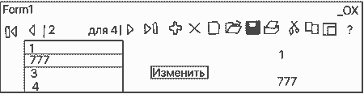

Рис. 18.3. Внешний вид элемента `BindingNavigator` с дополнительными кнопками.

Объект `BindingNavigator` можно привязать к любому источнику данных, но он прежде всего предназначен для интеграции с компонентом `BindingSource` через свойство `BindingNavigator.BindingSource`. `BindingNavigator` предоставляет пользовательский интерфейс для управления текущими элементами компонента `BindingSource`. По умолчанию элемент управления `BindingNavigator` предлагает кнопки, отвечающие методам навигации компонента `BindingSource`, но, щелкнув кнопку со стрелочкой, разработчик может добавить на панель стандартные элементы. **Кнопки** «`Добавить`» и «`Удалить`» имеют уже готовую реализацию, однако не всегда она удовлетворяет разработчиков. Так, по кнопке «Добавить» добавляется объект по умолчанию (метод `AddNew`), поэтому лучше добавить обработчик события `Click` для этой кнопки и вручную создать новый объект, определив значения всех параметров конструктора, щелкните днажды кнопку `+`, отобразится обработчик. **Пример кода**.

```
private void bindingNavigatorAddNewltem_Click(object sender, EventArgs e)
{
    // Создайте здесь объект и добавьте его в источник.
    Form2 frm2 = new Form2();
    frm2.ShowDialog();
    bindingSource1.Add(frm2.newObj);
}
```

Создайте новый объект в дочерней форме. Объект по умолчанию можно без проблем создавать в DataGridView, так как пользователь в режиме редактирования строки во многих случаях может ввести все нужные значения в автоматически созданный объект.

Страница 196

# ФИЛЬТРАЦИЯ СТРОК ИСТОЧНИКА ДАННЫХ.

Для фильтрации объектов источника данных можно использовать свойство `BindingSource.Filter`, которое рекомендуется применять для классов `DataTable` и `DataView ADO.NET`. Если значение свойства `Filter` не равно `null`, объект `BindingSource` передает это свойство в базовый список. Если задать это свойство во время инициализации объекта, вызов будет отложен до момента завершения инициализации. Чтобы задать значение фильтра, нужно указать имя столбца, после которого следует оператор, а затем значение, по которому выполняется фильтрация. Значение фильтра необходимо заключать в кавычки, например, `"LastName = 'Smith'"`. Допустимый синтаксис зависит от базового источника данных. Если базовый источник данных имеет тип `DataSet`, `DataTable` или `DataView`, можно задавать логические выражения с помощью синтаксиса, приведённого в документации по свойству `DataColumn.Expression`. Значение свойства `Filter` будет сохраняться во время изменения источника данных. Чтобы прекратить фильтрацию свойства `DataSource`, вызовите метод `RemoveFilter`. **Пример**. В приведённом ниже фильтре рассматриваются только записи таблицы со значениями столбца `artist`, равными «Броневой», `source1.Filter = "artist = 'Броневой'";`. Фильтр для таблиц должен удовлетворять синтаксису предложения `Where` языка `SQL`. **Пример**. Сложное условие фильтрации. `source1.Filter = "artist Like '*Mat*' or artist Like '*Mer*'";`

Страница 197

# ИСПОЛЬЗОВАНИЕ yield ДЛЯ ФОРМИРОВАНИЯ ИСТОЧНИКА ДАННЫХ.

Класс `BindingSource` позволяет привязать данные, реализующие в упрощённом виде лишь один интерфейс `IEnumerable`. Поэтому возможна, например, привязка, в которой очередное значение возвращается из перечислителя с помощью ключевого слова `yield`.

**Пример**. Ниже приведена программа, в которой объекты создаются в цикле и предоставляются с помощью ключевого слова `yield` для привязки.

```
public partial class Form1 : Form
{
    public Form1()
    {
        InitializeComponent();
        // bindingSource1 - объект типа BindingSource
        bindingSource1.DataSource = new PersonCollection();
        listBox1.DataSource = bindingSource1;
        listBox1.DisplayMember = "Name";
    }
}
public class PersonCollection: IEnumerable
{
    public IEnumerator GetEnumerator()
    {
        for(uint i = 0; i <= 5; i++)
        yield return new Person("Студент" +i.ToString(), 20+i, 'M');
    }
}
```

Страница 198

```
public class Person
{
    public string Name {get; set;};
    public uint Age {get; set; };
    public char Gender {get; set;};
    public Person(string name, uint age, char gender)
    { Name = name; Age = age; Gender = gender; }
{
```

Оператор `yield` запоминает состояние цикла на момент выхода из него по `return` или `break` и при повторном входе в цикл продолжает его выполнение с ранее запомненного состояния. При этом компилятор автоматически создает все необходимые средства класса `IEnumerator` для работы с объектами, возвращаемыми циклом. Фактически цикл с `yield` — это коллекция. Оператор `yield` используется в блоке итератора для предоставления значения объекта перечислителя или для сообщения о конце итерации. Синтаксис оператора yield:

```
yield return ‹expression>;
yield break;
```

Выражение `expression` вычисляется и возвращается в виде значения объекту перечислителя; выражение `expression` должно неявно преобразовываться в тип результата итератора. На внутреннем уровне (за «кулисами») при обработке ключевого слова `yield` компилятор динамически генерирует в рамках соответствующего класса определение вложенного класса. В этом классе создаются метод `MoveNext` и свойство `Current`. (`Метод Reset` не генерируется.) Оператор `yield` не обязан быть последним в блоке цикла. Если он находится в середине, то выполнение блока продолжается со следующего оператора после `yield`.

Страница 199

# ВСТРОЕННЫЕ И ССЫЛОЧНЫЕ ТИПЫ ИСТОЧНИКА ДАННЫХ.

Изменения данных в источнике по-разному отражаются на списке элемента управления в зависимости от того, являются данные значимыми или ссылочными типами. Если источник содержит данные значимого (элементарного) типа (int, float и т.д.), то эти данные копируются методом Add в списочный элемент управления (передача параметра по значению). Поэтому изменение данных в источнике не влияет на данные в списочном элементе управления. Рассмотрим следующий пример кода:

```
List<int> list;
private void Form1_Load(object sender, EventArgs e)
{
    list = new List<int>();
    list.Add(0);
    list.Add(1);
    list.Add(2);
    list.Add(3);
    list.Add(4):
    bindingSource1.DataSource = list;
    listBox1.DataSource = bindingSource1;
    list[2] = 777; // Изменяем значение в источнике данных.
    label1.Text = ((int) listBox1.Items[2]).ToString);
}
```

Страница 200

В примере после создания источника с данными значимого типа и привязки элемента управления посредством соединителя к этому источнику осуществляется изменение третьего элемента в источнике данных. Вывод на экран (в label1) третьего числа коллекции элемента управления показывает, что это число осталось прежним. Это состояние показано на рис. 18.4. Исходное значение также не изменилось.

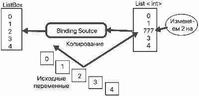

Рис. 18.4. Списки значимого типа.

Аналогично ведёт себя и тип string, поскольку он является неизменяемым типом данных. Можно сделать вывод, что из элемента управления, привязанного к списку значимого типа, не обновив привязку, нельзя использовать значение — используйте метод ResetBindings или подобный ему. **Другим решением проблемы** является использование коллекции `BindingList<T>` вместо `List<T>`. В этом случае можно привязать списочный элемент управления непосредственно к коллекции `bindingList` типа `BindingList<T>: comboBox1.DataSource = bindingList;` **Если данные источника являются объектами**, то в результате привязки в коллекцию элемента управления и в коллекцию источника данных копируются (как на рис. 18.4) ссылки на эти объекты. В отличие от значимых типов ссылки можно удалить, добавить, но не изменить. Теперь, если какой-либо объект будет изменен, ссылка в коллекции элемента управления будет указывать на измененные значения. Этот процесс проиллюстрирован на рис. 18.5.

Страница 201

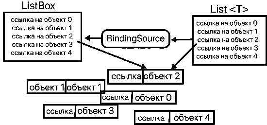

Рис. 18.5. Списки ссылочного типа.

Из рис. 18.5 следует, что если какой-либо объект будет изменен, то даже если элемент управления будет отображать старое значение, ссылка будет указывать на тот же объект, но с измененным(и) полем(полями). Остается только его перерисовать, используя метод `ResetBindings`. **Комментарий**. Почему строки типа string, являясь ссылочными, ведут себя как значимый тип? Строка является встроенным и неизменяемым типом данных, то есть при попытке изменить строку с помощью методов или операции присваивания создается новая строка. Рис. 18.4 иллюстрирует ситуацию, когда после изменения строки в источнике данных будет создана новая строка, а в элементе управления останется старая. $$***$$ В заключение отметим следующее: **во-первых**, благодаря своим преимуществам компонент `BindingSource` является предпочтительным способом привязки сложных элементов управления `Windows Forms` к источникам данных. **Во-вторых**, не забывайте в нужном месте выполнять обновление привязки и отображения данных с помощью методов `ResetBindings`, `ResetCurrentItem` или `ResetItem`.

Страница 202

# 18.3. Простая привязка ОСНОВНЫЕ СВЕДЕНИЯ.

Для привязки простого элемента управления к источнику данных следует использовать свойство DataBindings этого элемента управления. (Речь идет об элементах управления, у которых отсутствует свойство DataSource.) Свойство DataBindings используется для доступа к коллекции ControlBindingsCollection привязок свойств элемента управления к источникам данных. Привязка является объектом типа Binding, который определяет параметры привязки, то есть коллекция ControlBindingsCollection состоит из этих объектов. В отличие от сложной привязки списочных элементов управления, простая привязка является двусторонней: изменяется источник — изменяется и элемент управления, изменяется элемент управления — изменяется и источник. Однако в обратную сторону — от элемента управления к источнику — привязка срабатывает не всегда, как хотелось бы. Предлагаю читателю поэкспериментировать со свойствами Text двух элементов управления TextBox, привязывая один к другому. Достоинство привязки заключается в том, что где бы в программе ни изменялось свойство элемента управления или его источник данных, разработчик, если он установил привязку, освобождается от контроля за этими изменениями. Замечание. Следует понимать, что речь идет об источниках, свойства которых оповещают привязку об изменениях своих значений. К таким источникам относятся, например, свойства элементов управления. Если Вы привяжете элемент управления к свойству, не поддерживающему привязку, то это свойство не будет оповещать элемент управления о своих изменениях. Свойство DataBindings определяет не один элемент, а коллекцию привязок. Причиной этого является то, что у одного элемента управления есть несколько свойств, каждое из которых может быть привязано к своему источнику данных. Например, для свойства Text элемента label1 может использоваться одна привязка в коллекции, а для свойства ForeColor этого элемента — другая. Однако одно свойство элемента управления не может быть привязано к нескольким источникам данных. Для добавления объекта Binding в коллекцию используется метод Add коллекции, который имеет 7 перегрузок. Приведем первые четыре версии метода Add, используемые в данном учебнике:

Страница 203

```
public void Add(Binding binding)
```

Добавляет заданный объект Binding в коллекцию.

```
public Binding Add (string propertyName, Object dataSource, string dataMember)
```

Создает привязку (объект Binding), используя имя свойства заданного элемента управления, источник данных и член данных (свойство), и добавляет эту привязку в коллекцию.

```
public Binding Add(string propertyName, Object dataSource, string data Member, bool formatting Enabled)
```

Создает привязку заданного свойства элемента управления с заданным членом (свойством) указанного источника данных, используя сведения о том, включено ли форматирование, и добавляет привязку в коллекцию.

```
public Binding Add(string propertyName, Object data Source, string dataMember, bool formatting Enabled, DataSourceUpdateMode update Mode)
```

Создает привязку, связывающую заданное свойство элемента управления с заданным членом (свойством) указанного источника данных, при необходимости включая форматирование и учитывая настройку обновления. Привязка добавляется в коллекцию.

Страница 204

**Параметры**:

- **propertyName** — имя свойства элемента управления, которое привязываем к источнику данных.
- **dataSource** — объект `object`, предоставляющий источник данных. **dataMember** - привязываемое свойство (член данных) или список источника данных. Параметр может быть пустой строкой (""), одним именем свойства или иерархией имен, разделенных точками. Пример иерархии имен: `Regions.regionsToCustomers.CustomerFirstName` Каждый член иерархии, как правило, является свойством
- **formattingEnabled** — значение true разрешает форматирование выводимых данных, false — не разрешает.
- **dataSourceUpdateMode** — член одноименного перечисления, указывает, в каких случаях должно производиться обновление ис точника данных при изменениях в связанном элементе управления. Члены перечисления `DataSourceUpdateMode`:
- **OnValidation** — источник данных обновляется при проверке свойства элемента управления. После проверки у значения в свойстве элемента управления также будет изменен формат.
- **OnPropertyChanged** - источник данных обновляется при каждом изменении свойства элемента управления.
- **Never** — источник данных никогда не обновляется и значения, введенные в элементе управления, не анализируются, не проверяются и не переформатируются.

Страница 205

Если в перечисленных выше версиях метода `Add` со второй по седьмую мы заменим в тексте подстроку `Binding Add` на `Binding`, то получим перегрузки конструктора `Binding` — шесть версий. **Первая версия** метода `Add` принимает готовый объект `Binding`. В версиях со второй по седьмую методы `Add`, используя свои аргументы, сами создают объекты типа `Binding`, конструкторам которых передают те же аргументы и в той же последовательности. **Исходя из вышесказанного**, следующие два метода Add равносильны:

```
label1.DataBindings.Add("Text", textBox1, "Text");
```

-И-

```
label1.DataBindings.Add(new Binding("Text", textBox1, "Text"));
```

В приведенных выше вызовах метода `Add` осуществляется простая привязка свойства `Text` элемента управления `label1` к свойству `Text` элемента управления `textBox1`. **Несмотря на то что** методы `Add` без «new Binding» короче в написании, среда разработки `Visual Studio`, генерируя привязку в файле `Form1.Designer.cs`, всегда использует первую версию метода `Add`, создавая объект `Binding` внутри вызова (см. последний пример выше). На рис. 18.6 показана связь элементов простой привязки.

Страница 206

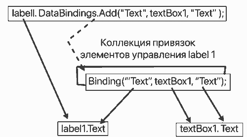

Рис. 18.6. Связь элементов простой привязки.

# ПРИМЕРЫ ПРОСТОЙ ПРИВЯЗКИ.

**Пример**. Свойство `Text` элемента управления `label1` привязывается к свойству `Text` элемента управления `textBox1`. В примере демонстрируется создание объекта `Binding` отдельным оператором.

```
Binding bnd1 = new Binding("Text", textBox1, "Text", true);
label1.DataBindings.Add(bnd1);
```

В результате такой привязки при вводе символов в текстовое поле они тут же отображаются в `label1`. **Пример**. Два свойства элемента управления `label1` — `Text` и `ForeColor` — привязываются к разным источникам. Создаётся коллекция привязок, состоящая из двух объектов `Binding`.

```
label1.DataBindings.Add("Text", textBox1, "Text");
label1.DataBindings.Add("ForeColor", textBox1, "ForeColor");
```

Страница 207

**Пример**. В качестве источника данных используется другая привязка. Ниже показано, как `textBox2.Text` привязывается к `textBox1.Text`, а `label1.Text` — к `textBox2.Text`. По сути, элемент `textBox1` является общим источником данных.

```
textBox2.DataBindings.Add("Text", textBox1, "Text");
label1.DataBindings.Add("Text", textBox2, "Text");
```

На практике `label1` целесообразнее было бы привязать к `textBox1`.

**Пример**. Свойство `Text` элемента управления `textBox1` привязывается к свойству `P1` объекта `myObj` типа `MyClass`. (Определение класса `MyClass` дано в разделе 17.5.)

```
MyClass myObj = new MyClass (10, 20); // Создаем объект.
textBox1.DataBindings.Add("Text", myObi, "P1");
```

Свойство `P1` в примере будет изменяться вслед за изменением свойства `Text`, однако свойство `Text` не будет изменяться вслед за изменением свойства `P1`.

**Пример**. Свойство `Text` элемента управления `textBox1` привязывается к свойству `S` формы.

```
public stringS { get; set; }
public Form1()
{
    InitializeComponent();
    s = "123";
    textBox1.DataBindings.Add("Text", this, "S");
}
```

Свойство `S` будет отслеживать изменения содержимого текстового поля.

**Пример**. Свойство BackColor формы (this) привязывается к свойству параметра FormBackColor объекта mySet.

```
this.DataBindings.Add(
    BackColor"
    , mySet
    , "FormBackColor" true
    , DataSourceUpdateMode.OnPropertyChanged
);
```

Параметры программы используются в технологии сохранения состояния программы в файле. Простая привязка свойств элементов управления к параметрам программы подробно рассматривается во втором томе учебника. Такая привязка не работает, если в методе `Add` не указан аргумент `DataSourceUpdateMode.OnPropertyChanged`.

**Пример 6**. Свойство `Text` элемента управления `TextBox` привязывается к свойству `Value` элемента управления `DateTimePicker`.

```
textBox4.DataBindings.Add("Text", dateTimePicker1, "Value");
```

Страница 208

# ПРОСТАЯ ПРИВЯЗКА К СЛОЖНОМУ ОБЪЕКТУ.

Класс `Binding` служит для создания и поддержания простой привязки свойства элемента управления не только к свойству отдельного объекта, но и к свойству текущего объекта в списке объектов.

```
dataSet.textBox1.DataBinaings.Add("Text", dataset, "студенты.студІD");
```

Объект `dataSet` — это набор данных, включающий реляционные таблицы. Набор данных чаще всего является отображением базы данных в оперативную память. Таблица состоит из коллекции строк, одна из которых является текущей.

Страница 209

**Пример**. Свойство `Text` элемента управления `textBox1` привязывается к текущему элементу массива:

```
Student[] студенты = new Student[3];
студенты[0] = new Student ("Иванов", 125, "Москва");
студенты[1] = new Student ("Петров", 1386, "Курск");
студенты[2] = new Student ("Сидоров", 63, "Тула"):
textBox1.DataBindings.Add("Text", студенты, "Name");
```

Свойство `Name` определяет фамилию студента. В этом примере текущим объектом является первый (индекс 0). Для перехода к другому объекту нужно предпринять дополнительные усилия. Со сложными элементами управления типа `ListBox` или `ComboBox` таких проблем не возникает. **Если привязка** выполняется к свойству текущего объекта в списке, и этот список привязан к источнику данных с помощью соединителя `BindingSource`, то рекомендуется этот соединитель использовать в качестве источника данных в простой привязке.

**Пример**. Свойство `Text` элемента управления `label1` привязывается к столбцу `ProductName` через компонент `BindingSource`, таблице который привязывается к таблице `Products` базы данных `NorthwindDataSet`.

```
//bindingSource1 = new BindingSource(components);
// Привяжем соединитель к базе данных.
binding Source1.DataSource = NorthwindDataSet;
// Выбираем конкретную таблицу.
bindingSource1.DataMember = "Products";
// Привяжем свойство label1.Text к столбцу ProductName таблицы,
// к которой привязан соединитель bindingSourcel.
// Значение выбирается из текущей записи.
label1.DataBindings.Add ("Text", bindingSource1, "ProductName", true);
```

Страница 210

```
bindingSource1. DataSource = list;
listBox1.DataSource = bindingSource1;
listBox1.DisplayMember = "P1";
```

Мы видим, что возвращаемое свойство не определено (нет оператора `listBox1.ValueMember="Свойство"`), поэтому свойство `SelectedValue` элемента управления ListBox возвращает вместо значения ссылку на текущий объект. Чтобы из объекта выбрать свойство Р2, необходимо в привязке, в цепочке свойств, указать это свойство через точку. `textBox1.DataBindings.Add("Text", listBox1.SelectedValue.P2);` Если в качестве источника данных простой привязки указать DataBinding, то есть не ListBox, а исходный список, то вместо цепочки можно указать только «P2»: `textBox1.DataBindings.Add("Text", bindingSource1, "P2");`

**Пример**. Определим у списочного элемента управления свойство Р2 как свойство, возвращающее значение. Пусть предварительно выполнены следующие операторы:

```
bindingSource1. DataSource = list;
listBox1.DataSource = bindingSource1;
listBox1.DisplayMember = "P1";
listBox1.ValueMember = "P2";
```

В операторе привязки, приведённом ниже, свойство Text элемента управления `textBox1` привязывается к свойству `SelectedValue` элемента управления `listBox1`. Теперь в примере не требуется в параметре `dataMember` метода `Add` указывать имя `Р2`, так как его определяет свойство `listBox1.ValueMember.textBox1.DataBindings.Add("Text", listBox1, "SelectedValue");`

Страница 211

# СОБЫТИЯ КЛАССА Binding.

С объектом Binding связано три события:

- **Parse** — происходит при изменении значения элемента управления с привязкой к данным.
- **Format** - вызывается при передаче данных из источника данных в элемент управления. В обработчике события можно выполнить преобразованиие неформатированных данных из источника данных в форматированные данные для вывода на экран.
- **BindingComplete** - происходит, когда свойство FormattingEnabled получает значение true, и когда завершается операция привязки, например, при передаче данных из элемента управления в источник данных или наоборот.

**Пример**. В приведённом ниже коде показано, как подписаться на события для преобразования и форматирования выводимого значения, и приведены примеры соответствующих обработчиков, осуществляющих преобразование значения типа `decimal`. (Полный текст можно найти в справочной системе языка C#.)

```
private void Form1_Load(object sender, EventArgs e)
{
    Binding bind = new Binding(«Text», dataSet, "студенты студОценки.Математика");
    bind.Parse += new
    ConvertEventHandler(CurrencyStringToDecimal);
    bind.Format += new ConvertEventHandler(DecimalToCurrencyString);
    text1.DataBindings.Add(bind);
}
```

Страница 212

```
private void CurrencyString ToDecimal(object sender,
{
    //Обьект ConvertEventArgs содержит ConvertEventArgs e)
    // передаваемое данное из источника.
    if(e.DesiredType ! = typeof(decimal)) return;
    e.Value = Decimal.Parse(e.Value. ToString(), NumberStyles.e, null);
    Console. WriteLine(e.Value);
}
private void DecimalToCurrencyString(object sender, ConvertEventArgs e)
{
    if(e.DesiredType != typeof(string)) return;
    e.Value = ((decimal) e. Value). ToString("c");
}
```

Страница 213

# ПРИВЯЗКА В РЕЖИМЕ ВИЗУАЛЬНОЙ РАЗРАБОТКИ.

Выше мы рассматривали примеры программирования простой привязки вручную. Однако окно «Свойства» для элементов управления содержит узел (DataBindings), члены которого позволяют выполнить привязку в режиме визуальной разработки. Рассмотрим, как элемент управления `TextBox` привязать к источнику данных. Предположим, что будет использована привязка к источнику данных, представленному списком типа BindingList. Класс MyClass содержит два свойства — Р1 и Р2. Во-первых, выделите элемент TextBox и в окне «Свойства» разверните узел «(DataBindings)» (см. рис. 18.7). Щелкните стрелку справа в строке свойства Text — откроется окно с источниками данных. Во-вторых, если источник данных ранее был настроен для проекта или формы, он будет показан. Выберите этот источник. Если источника в окне нет, то щелкните «Добавить источник данных проекта» для подключения к данным и создания источника данных. Откроется окно Мастера настройки источника данных (см. рис. 18.8).

Страница 214

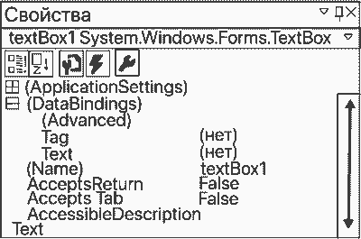

Рис. 18.7. Окно «Свойства» и узел (`DataBindings`)

На странице «Выберите тип источника данных» выберите «Объект», нажмите «Далее». Раскрывайте узлы приложения, пока не увидите требуемый источник. Отметьте его и нажмите кнопку «Готово» (см. рис. 18.8).

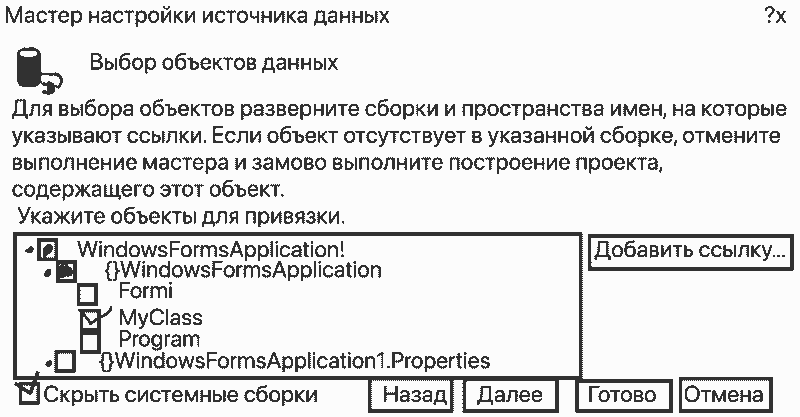

Рис. 18.8. Окно мастера настройки источника данных.

**В-третьих**. В окне «Свойства» снова щелкните стрелку рядом со свойством `Text`. В редакторе источника данных выберите источник, раскройте его и выберите свойство `P1` для привязки элемента `TextBox`. Редактор источника данных закроется, а объект `myClassBindingSource` будет добавлен на форму. В файле `Form1.Designer.cs` будут сгенерированы следующие строки (упрощены автором):

```
BindingSource myClassBindingSource;
myClassBindingSource.DataSource = typeof(WindowsFormsApplication1,MyClass);
textBox1.DataBindings.Add(new Binding("Text", myClassBindingSource, "P1", true));
```

Вы видите, что `myClassBindingSource` привязывается к классу, а не к объекту, поэтому в программе, в `Form1_Load`, надо переопределить эту привязку:

```
myClassBindingSource.DataSource = list;
```

Визуальный режим рекомендуется использовать для простой привязки к данным таблицы набора данных (DataSet) или представления, доступными в окне свойств.

Страница 215

Подведем итог. Простую привязку эффективнее использовать в тех случаях, когда текущее значение источника разработчику недоступно, например, пользователь выбирает строку в элементе управления ListBox и требуется отобразить соответствующее ей значение в элементе TextBox. Выше были приведены примеры такой привязки. Без привязки, для того чтобы постоянно отображалось текущее значение списка в элементе управления textBox1, потребуется использование обработчика listBox1_SelectedIndexChanged, который будет получать управление при каждом щелчке на строке списка. Если же разработчик определит простую привязку, он будет освобожден от отслеживания состояния источника данных. В тех случаях, когда источник не извещает механизм привязки о своих изменениях, удобнее, по мнению автора, отказаться от привязки.

# 18.4. Комплексный пример.

Продемонстрируем использование сложной и простой привязки элементов управления к списку объектов типа `List<Студент>`. Создадим форму с элементами: `ComboBox`, многострочный `TextBox`, однострочный `ТехВох` и пять кнопок `Button` (см. рис. 18.9). Тексты кнопок на рисунке определяют их функции. В программе, приведённой ниже, показано, как с помощью методов и свойств класса `BindingSource` осуществлять переход к очередному объекту списка, делая его текущим. Независимо от того, как получен базовый список компонента `BindingSource`, перемещение по его элементам выполняют такие методы класса `BindingSource`, как `MoveFirst`, `MovePrevious`, `MoveNext`, `MoveLast` и др. Получить текущий объект помогут и свойства `Current` и `Position`. Такое перемещение позволяет менять данные в простом элементе управления, привязанном к источнику.

Страница 216

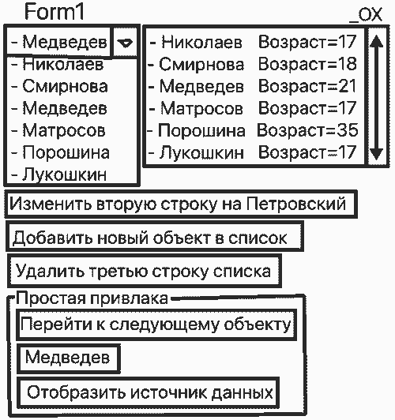

Рис. 18.9. Главное окно программы.

В программе также показаны следующие взаимосвязи источника данных и элементов управления, привязанных к этому источнику с помощью компонента `BindingSource`: **во-первых**. Изменяем текстовое поле — изменяется источник данных. Для того чтобы увидеть эти изменения, необходимо нажать кнопку «Отобразить источник данных». **Во-вторых**. Изменяем кнопкой вторую строку источника — изменяется текстовое поле, но `ComboBox1` при этом не изменяется. Для обновления `ComboBox1` выполняем метод `bindingSource1.ResetBindings(false)`. Метод `ResetBindings` автоматически вызывается каждый раз, когда другой элемент вносит существенные изменения в привязку данных, например задает свойства `DataSource` или `DataMember`. Однако, когда источник данных не выполняет уведомление об изменениях (как в нашем случае), программист должен вызвать этот метод явно. Содержимое файла `Form1.cs`:

```
using System;
using System.Collections.Generic;
using System.Windows.Forms;

namespace Привязка_ComboBox
{
    public partial class Form1 : Form
    {
        List <Студент> list = new List<Студент>();
        public Form1()
        {
            InitializeComponent();
```

Страница 217

```
            // Создание списка студентов
            list = new List<Студент>();
            list.Add(new Студент("Николаев", 17, 'М'));
            list.Add(new Студент("Смирнова", 18, 'Ж'));
            list.Add(new Студент("Медведев", 21, 'М'));
            list.Add(new Студент("Матросов", 17, 'М'));
            list.Add(new Студент("Порошина", 35, 'Ж'));
            list.Add(new Студент ("Лукошкин", 17, 'М'));
            ОтобразитьИсточникДанных();
            bindingSource1.DataSource = list;
            // Сложная привязка
            comboBox1.DataSource = bindingSource1;
            comboBox1.DisplayMember = "Фамилия";
            // Простая привязка
            textBox1.DataBindings.Add(new Binding("Text", bindingSource1, "Фамилия", true));
        }
```

Страница 218

```
        private void ОтобразитьИсточникДанных /)
        {
            textBox2.Text = "";
            for (int i = 0; i < list.Count; i++)
                textBox2.Text += list[i].Фамилия + "\tВозраст =" + list[i].Возраст.ToString() + "Ir\n";
        }
        private void button1_Click(object sender, EventArgs e) { ОтобразитьИсточникДанных(); }
        // Изменить второй объект списка
        private void button2_Click(object sender, EventArgs e)
        {
            list[1].Фамилия = "Петровский";
            bindingSource1.ResetBindings(false);
            ОтобразитьИсточникДанных ();
        }
        // Добавить объект
        private void button3_Click(object sender, EventArgs e)
        {
            list.Add(new Студент("Бонд Джеймс", 41, 'М'));
            bindingSource1.ResetBindings(false);
            ОтобразитьИсточникДанных();
        }
```

Страница 219

```
        // Удалить третью строку списка
        private void button4_Click(object sender, EventArgs e)
        {
            list.Remove(list[2]);
            bindingSource1.ResetBindings(false);
            ОтобразитьИсточникДанных();
        }
        // Перейти к следующему элементу списка
        private void button5_Click(object sender, EventArgs e)
        {
            if(bindingSource1.Position + 1 < bindingSource1.Count)
            { bindingSource1.MoveNext(); }
            else { bindingSource1.MoveFirst(); }
        }
    }
```

```
    class Студент
    {
        public string Фамилия { get; set; }
        public uint ГодРождения { get; set; }
        public char Пол { get; set; }
        public Студент(string name, uint age, char gender)
        {
            Фамилия = name;
            ГодРождения = age;
            Пол = gender;
        }
    }
```

Страница 220

# 18.5. Задания для самостоятельной работы.

- **Задача 1**. Усовершенствуйте приведенную в разделе 18.4 программу. Замените `List<Студент>` на `BindingList<Студент>` и откажитесь от `BindingSource`. Не забудьте убрать и вызов метода `ResetBindings`, так как `BindingList` уведомляет элемент управления о необходимости его перерисовки.
- **Задача 2**. Создайте коллекцию студентов (класс Студент). По кнопке «Следующий» прочитайте очередной объект из коллекции. Используя простую привязку, отобразите фамилию и телефон из прочитанного объекта в поле `TextBox` и `Label` соответственно.
- **Задача 3**. Создайте коллекцию студентов (класс Студент) и коллекцию дисциплин (класс Дисциплина). Свойства класса Дисциплина: Название, Объем_в_часах. Разместите на форме списки: три `ComboBox` и один `ListBox`. Используя сложную привязку, отобразите: **Во-первых**, в первом ComboBox фамилии студентов, **Во-вторых**, во втором ComboBox названия дисциплин, **В-третьих**, в третьем ComboBox оценки из массива оценок (по 5-бальной системе). Путем выбора значений из перечисленных списков сформируйте коллекцию «Зачетная неделя». Отобразите коллекцию в `ListBox` в виде таблицы с выровненными столбцами.
- **Задача 4**. Дополнительно к задаче 3 реализуйте добавление и удаление объектов из списка студентов. Обеспечьте отображение измененной коллекции в списке.
- **Задача 5**. Исследуйте обновление ListBox при повторных привязках BindingSource к тому же источнику данных (списку).

Страница 221

# 19. ГЛАВНОЕ И КОНТЕКСТНОЕ МЕНЮ.

К числу часто используемых элементов управления, но вместе с тем достаточно простых с точки зрения их обычного применения, относятся меню и панель инструментов. Меню может быть главным, состоящим из ниспадающих (раскрывающихся) пунктов, и контекстным, вызываемым по правой кнопке мыши. Рассмотрим эти элементы управления.

# 19.1. Главное меню.

Пользователи достаточно часто сталкиваются с меню в различных приложениях, например в `Microsoft Office`. Среда `Visual Studio` позволяет создать меню, аналогичное `Microsoft Word`. По сути, меню — это одна или несколько коллекций элементов, чаще всего представленных кнопками. Каждая кнопка называется командой, а элемент, объединяющий кнопки, — родительским меню. На рис. 19.1 приведен пример меню, в котором Меню1 и Меню11 являются родительскими ниспадающими (раскрывающимися) меню, а остальные элементы — командами. Родительские меню имеют непустые контейнеры. Элемент меню иногда будем также называть пунктом меню. Основное достоинство меню заключается в его компактном отображении: команд не видно, пока Вы их не раскроете, щелкнув родительское меню. **Примечание**. На рис. 19.1 нельзя визуально определить, каким элементом является Меню2 — оно может быть как ниспадающим меню, так и командой. Это же справедливо и для ряда других элементов.

Страника 222

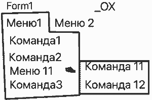

Рис. 19.1. Пример главного меню.

Вся система меню является элементом управления MenuStrip, который представляет контейнер для структуры меню формы. Из рис. 19.1 следует, что в контейнере MenuStrip содержатся элементы Меню1 и Меню2. Тип MenuStrip наследует класс Control, однако отображается он не на форме, а на панели компонентов. Используя свойство Dock, Вы можете расположить полоску меню в другом месте. Как правило, каждый элемент, входящий в систему меню, имеет тип ToolStripMenuItem и отображается в строке в виде текста и/или значка. Этот тип ведет себя как кнопка. Но в качестве элемента меню также можно использовать разделитель пунктов меню (класс ToolStripSeparator), комбинированный список (класс ToolStripComboBox) и текстовое поле (класс ToolStripTextBox). Списки и текстовые поля чаще всего используются в панели инструментов, которая является объектом класса ToolStrip, но этот же класс наследуется и классом MenuStrip, поэтому списки и текстовые поля становятся доступными и в меню. На рис. 19.2 показаны все типы элементов меню. Чтобы отобразить указанный на рис. 19.2 список, необходимо нажать на кнопку у. Из приведенного на рис. 19.2 перечня типов, кроме элемента Menultem (установленного по умолчанию), часто используется объект Separator.

Страница 223

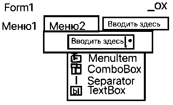

Рис. 19.2. Выбор типа элемента меню.

**Обработка нажатия (выборки) элемента меню**. Двойной щелчок элемента меню в форме `Visual Studio` приводит к созданию обработчика события `Click` с соответствующим именем, например: `void команда1ToolStripMenuItem_Click(object sender, EventArgs e)`. **Как видите**, первая часть имени обработчика — это имя элемента меню. Рекомендуется это имя сократить. **Все команды меню должны иметь свои обработчики**. Для ниспадающего меню редко создают обработчик события `Click`, так как при выборке такого элемента выполняется стандартная операция: осуществляется отображение вложенных в контейнер элементов. Однако, если обработчик определен для меню, он будет вызван. **Во время выполнения** программы команда меню может быть выполнена с помощью щелчка левой кнопкой мыши, с помощью горячих клавиш (сочетания клавиш) и клавиши быстрого вызова. Удобство использования меню можно также повысить с помощью добавления флагов и значков.

Страница 224

Добавление изображения в элемент меню. Свойству Image элемента меню присвойте имя изображения. Чтобы изображение отображалось, присвойте соответствующее значение свойству DisplayStyle. Это свойство имеет тип ToolStripItemDisplayStyle, которое является ToolStripItemDisplayStyle: перечислением. Члены перечисления: Во-первых, None — указывает, что для данного ToolStripItem не требуется прорисовывать ни изображение, ни текст. Во-вторых, Text — указывает, что для данного ToolStripItem требуется прорисовать только текст. В-третьих, Image — указывает, что для данного ToolStripItem требуется прорисовать только изображение. В-четвертых, ImageAndText — указывает, что для данного ToolStripItem требуется прорисовать и изображение, и текст. Из списка значений перечисления следует, что если свойство DisplayStyle команды меню равно Text или None, то изображение отображаться не будет.

**Отображение галочки в команде меню**. Если Вы хотите, чтобы элемент меню (команда или ниспадающее меню) всегда был отмечен галочкой вне зависимости от его выборки, то установите для свойства `Checked` значение `true`. При этом свойству `CheckState` присваивается значение `true`. Для отображения галочки, изменяющей состояние по каждому щелчку, свойству `CheckOnClick` элемента меню присвойте значение `true`. Кроме того, если свойству `Checked` изображения присвоено значение `true`, то во время выполнения граница изображения будет заштрихованной. **Быстрый доступ к элементу меню с помощью горячих клавиш**.

К любому элементу меню можно обратиться с помощью сочетания клавиш клавиатуры (горячих клавиш). Для этого свойству `ShortcutKeys` команды меню присвойте желаемое сочетание клавиш, например CTRL+О для команды меню «Открыть», а свойству `ShowShortcutKeys` (отображать клавиши) присвойте значение true. Сочетания клавиш позволяют выполнить быстрый доступ к элементу меню, даже если это меню не раскрыто. На рис. 19.3 показаны два пункта меню (Команда1 и Команда2), которые можно выбрать с помощью клавиш Ctrl+Q и Ctrl+A. **Если Вы хотите** заменить текст, выводимый свойством `ShowShortcutKeys=true`, на какой-то другой, можете воспользоваться свойством `ShortcutKeysDisplayString`. Это свойство можно использовать также независимо от наличия горячих клавиш, например, чтобы вывести многоточие, обозначающее вызов диалогового окна (см. рис. 19.3, Команда3).

Страница 255

[figure not shown]

Рис. 19.3. Отображение горячих клавиш.

**Отображение клавиши быстрого вызова для команды меню**. Если перед буквой текста элемента меню ввести символ "&", то к такому пункту можно перейти, нажав клавишу с этой буквой (после нажатия клавиши ALT). Эта буква становится частью встроенного клавиатурного интерфейса Windows. На экране символ "&" отображаться не будет, однако следующая за ним буква будет выделена подчеркиванием, обозначая тем самым клавишу быстрого вызова (опять же после нажатия клавиши ALT). Например, если в свойстве Text пункта меню указать &Ореп, команда меню будет иметь вид Open. **Необходимо**, чтобы вся цепочка элементов меню до требуемого, начиная с самого верхнего уровня, имела клавиши быстрого вызова. Нажимая клавишу ALT, Вы передаете фокус `MenuStrip`. **При этом у соответствующих букв** элементов меню верхнего уровня появятся подчеркивания. Теперь можно отпустить клавишу ALT и далее, по иерархии, нажимать клавиши быстрого вызова элементов, пока не достигнете требуемой команды. Чтобы не было неоднозначности, не следует определять одинаковые клавиши быстрого вызова несколько раз в одной системе меню.

Страница 226

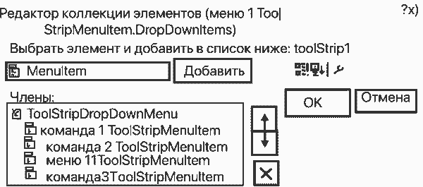

Рис. 19.4. Окно редактора коллекции элементов меню.

**Изменение меню во время визуальной разработки**. Если Вы уже создали меню и возникла необходимость вставить новый элемент, например разделитель, то можно переделать ниспадающее меню, используя свойство `DropDownItems` в окне «Свойства». Вызвав редактор коллекции (см. рис. 19.4), Вы можете добавить элемент в конец коллекции, а затем поменять местами элементы меню. Изменение меню во время выполнения программы. Во время выполнения программы Вы можете работать с коллекцией элементов меню, как с любой другой коллекцией, то есть используя методы `AddRange`, `Add`, `Insert`, `Clear`, `Remove` и др. Смотрите файл `Form.Designer.cs` и изучайте технику работы с меню. **Пункты меню типа `ToolStripComboBox` и `ToolStripTextBox`**. Особенность этих пунктов состоит в том, что для них, как правило, не создают обработчики события `Click`, так как такие пункты предназначены для ввода и хранения информации, которая может быть прочитана в нужный момент. Кроме того, элементы `ToolStripComboBox` и `ToolStripTextBox` можно поместить в ниспадающее меню и тем самым скрыть их от пользователя. На рис. 19.5 показаны примеры пунктов этих типов.

Страница 227

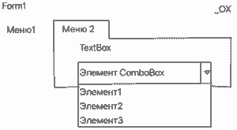

Рис. 19.5. Пункты типа `ToolStripComboBox` и `ToolStripTextBox`

Когда возникнет необходимость получить значения текстовых полей элементов типа `ToolStripComboBox` и `ToolStripTextBox`, надо просто прочитать свойства `Text` этих элементов. Например:

```
string txt = toolStripTextBox1.Text;
string comboTxt = toolStripComboBox1.Text;
```

**Сокращение имен пунктов меню**. Пункты меню имеют слишком длинные имена, поэтому рекомендуется их переименовывать. Для этого в окне свойств следует использовать свойство (`Name`), установив для него новое значение, например: Рекомендуется пунктам присваивать имена, производные от свойства `Text` этих элементов.

Страница 228

# 19.2. Контекстное меню.

**Контекстное меню** — это меню, которое выводится по щелчку правой кнопки мыши на элементе управления, поэтому вид контекстного меню должен соответствовать этому элементу. **Контекстное меню**, как правило, дублирует какое-либо ниспадающее меню главного меню программы. Ряд элементов управления (`TextBox`, `ComboBox`) имеют встроенное контекстное меню. Например, на рис. 19.6 показан элемент управления `TextBox` и его системное контекстное меню, дублирующее действия подменю `Edit`. Контекстное меню представлено классом `ContextMenuStrip`. По определению оно может состоять только из одной древовидной структуры элементов меню, поэтому оно наследует не класс `ToolStrip`, а класс `ToolStripDropDownMenu`. Пункты контекстного меню добавляются точно так же, как и для главного меню (см. рис. 19.7), но на этапе визуальной разработки контекстное меню размещается под главным меню. Добавим элемент управления `ContextMenuStrip` из панели элементов на форму (см. рис. 19.7). Этот элемент отобразится на панели компонентов и на форме. После разработки контекстного меню нужно определить, с каким элементом управления оно должно быть связано.

Страница 229

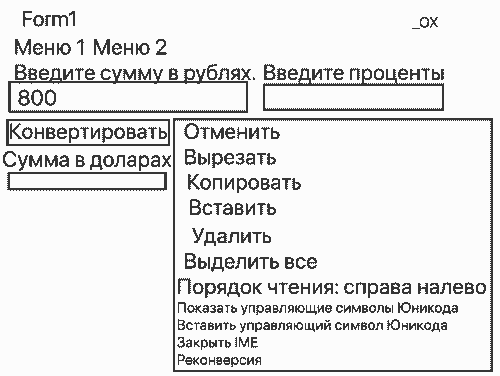

Рис. 19.6. Встроенное контекстное меню элемента `TextBox`

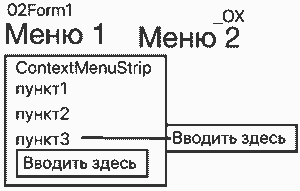

Рис. 19.7. Проектирование контекстного меню.

Страница 230

**Привязка контекстного меню к элементу управления**. Многие элементы управления имеют свойство `ContextMenuStrip`, с помощью которого можно прикрепить контекстное меню к элементу. Привяжем наше контекстное меню к кнопке `button1` (см. рис. 19.8).

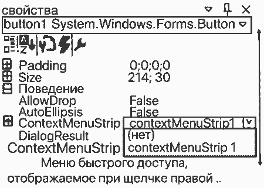

Рис. 19.8. Привязка контекстного меню к элементу управления Button.

Ориентацию контекстного меню относительно элемента управления определяет свойство `LayoutStyle` объекта `ContextMenuStrip`. Запустим программу и щелкнем кнопку `button1` правой клавишей мыши, получим окно, представленное на рис. 19.9. Если мы точно так же привяжем наше контекстное меню к элементу управления `TextBox`, то встроенное контекстное меню пропадет. Одно контекстное меню можно связать с несколькими элементами управления, но каждому элементу управления должно соответствовать только одно контекстное меню. Часто элементы контекстного меню заимствуются из главного меню. Однако нельзя ссылки на объекты одного меню использовать в другом (включая контекстное).

Страница 231

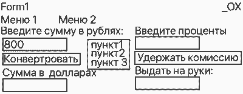

Рис. 19.9. Окно с контекстным меню кнопки.

В старой версии главного и контекстного меню использовались классы `MainMenu`, `Menultem`, `ContextMenu`. В новой версии этим классам соответствуют классы `MenuStrip`, `ToolStripMenultem` и `ContextStrip`. Разработчики заявляют, что в новые классы добавили новую функциональность, сохранив старую. Однако это не совсем так. Например, чтобы объекты `Menultem`, отображаемые в меню `MainMenu`, можно было использовать в `ContextMenu`, необходимо создать копию меню с помощью метода `CloneMenu` класса `Menultem`.

Например: `contextMenu1.MenuItems.Add(menultem1.CloneMenu());` **В новой версии** метода CloneMenu нет. А преобразовать старые классы в новые с помощью приведения типов не получается. **Также в старой** версии можно объединить команды меню и их подменю в один объект `Menultem` с помощью метода `MergeMenu` класса `Menultem`. В новой версии для этого надо использовать свойство `MergeAction` элемента `ToolStripMenultem`. **В заключение** следует отметить, что техника работы с пунктами главного меню во многих случаях может использоваться и для контекстного меню.

Страница 232

# 19.3. Задания для самостоятельной работы.

**Задача 1**. Разработать приложение с формой, содержащей меню со следующими пунктами: **во-первых**, «О программе»; **во-вторых**, «О разработчике»; **в-третьих**, «Выход». Для вывода информации использовать диалоговое окно `MessageBox`. При выборе пункта «Выход» для завершения программы использовать метод `Close()`. Перед закрытием программы запросить у пользователя подтверждение.

**Задача 2**. Разработать приложение с формой, содержащей кнопку `Button` с текстом «Выход» и поле `ТехВох` для ввода фамилии пользователя. Добавить на форму меню со следующими пунктами: **во-первых** Цвет фона; **во-вторых** Цвет текста. Для каждого из этих пунктов создайте дочерние пункты: **во-первых**, Белый; **во-вторых**, Черный; **в-третьих**, Желтый; **в-четвертых**, Красный; **в-пятых**, Синий; **в-шестых**, Зеленый. При выборе цвета фона или цвета текста выполнить перекраску кнопки и текстового поля.

**Задача 3**. Разработать приложение для вычисления частного от деления двух вещественных чисел. Исходные числа вводить в текстовые поля. Результат отображать в элементе управления `Label`. Для определения количества дробных цифр в частном использовать контекстное меню с пунктами 1, 2, 3 и 4.

Страница 233

# 20. ПАНЕЛЬ ИНСТРУМЕНТОВ.

### 20.1. Общие сведения.

В начале данного учебника был рассмотрен ряд наиболее часто встречающихся в программах элементов управления. К таким элементам управления также относится и панель инструментов, представленная классом `ToolStrip`. Класс `ToolStrip` предоставляет контейнер для объектов панели инструментов, к которым относятся: **во-первых**, ToolStripButton; **во-вторых**, ToolStripLabel; **в-третьих**, ToolStripSplitButton; **в-четвертых**, ToolStripDropDownButton; **в-пятых**, ToolStripSeparator; **в-шестых**, ToolStripComboBox; **в-седьмых**, ToolStripTextBox; **в-восьмых**, ToolStripProgressBar. Перечисленные типы наследуют от абстрактного класса `ToolStripItem`. К контейнеру можно получить доступ с помощью свойства `ToolStrip.Items`. Классы `ToolStrip` и `ToolStripItem` предоставляют гибкую расширяемую систему для отображения пунктов меню, панели инструментов (`ToolStrip`) и строки состояния (`StatusStrip`). После перетаскивания `ToolStrip` на форму на панели компонентов появится имя экземпляра панели инструментов, а на форме, под меню (или заголовком), появится макет первого элемента панели. Если Вы щелкните значок макета, то будет создан элемент-кнопка (тип `ToolStripButton`). Если Вы щелкните на макете кнопку со стрелкой, то будет раскрыт список допустимых элементов (см. рис. 20.1).

Страница 234

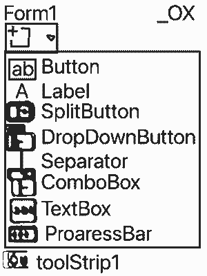

Рис. 20.1. Типы элементов контейнера панели ToolStrip.

Перечисленные на рис. 20.1 элементы (инструменты) представлены классами, имя которых начинается с `ToolStrip`, за которым следует название элемента из списка рис. 20.1, например, элемент `SplitButton` представлен классом `ToolStripSplitButton`. То же самое справедливо и для элементов списка на рис. 20.2. В несложных приложениях все элементы панели инструментов чаще всего являются кнопками. `ToolStrip` является базовым классом для классов `MenuStrip`, `StatusStrip` и `ContextMenuStrip`. Ссылка на экземпляр `ToolStrip` отображается на панели компонентов (см. рис. 20.1), однако `ToolStrip` наследует класс `Control`, поэтому этот элемент является элементом управления. В графических программах панели инструментов, как и меню, являются основным элементом интерфейса, так как они занимают мало места. Очень часто элементы панели инструментов дублируют команды меню. Кнопки на панели обычно изображаются в виде значков с текстом и без текста, другие элементы изображаются в соответствии со своим типом. На рис. 20.2 на панели слева направо отображены элементы в порядке их перечисления в списке типов (см. рис. 20.1): `Button`, `Label`, `SplitButton` и т.д.

Страница 235

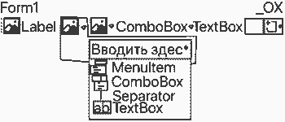

Рис. 20.2. Типы в меню `ToolStripDropDown`

`Separator` отображается в виде вертикальной или горизонтальной черты, разделяющей группы элементов. На рис. 20.2 разделитель изображен перед элементом `ComboBox`, на рис. 20.3 — после элемента `Menultem2`. Если после создания элемента `SplitButton` или `DropDownButton` щелкнуть кнопку со стрелкой справа от значка, то появится макет «Вводить здесь у» для ввода текста (см. рис. 20.2). Эта строка по умолчанию имеет тип `ToolStripMenuItem`. Кроме этого типа, есть еще три типа элементов: `ToolStripComboBox`, `ToolStripSeparator`, `ToolStripTextBox`, которые можно отобразить, щелкнув кнопку у макета «Вводить здесь у» (см. рис. 20.2). На рис. 20.3 приведен пример, в котором для инструмента `ToolStripDropDown` созданы 5 элементов: две команды меню, разделитель, текстовое поле и комбинированный список. В чем состоит отличие `SplitButton` от `DropDownButton`? Класс `ToolStripSplitButton` представляет сочетание стандартной кнопки слева и кнопки раскрывающегося списка справа (или наоборот, если значение `RightToLeft` равно `Yes`). Для этого элемента щелчок значка генерирует событие `Click`. Кнопка у не генерирует события, она только раскрывает список. Класс `ToolStripSplitButton` сочетает функциональные возможности обычной кнопки и кнопки раскрывающегося списка. Для синхронизации события `Click` выбранного раскрывающегося элемента с изображенным на кнопке элементом используйте свойство `DefaultItem`.

Страница 236

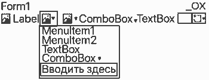

Рис. 20.3. Пример меню `ToolStripDropDown`

Класс `ToolStripDropDownButton` представляет элемент управления, после щелчка которого выводится дочернее меню, из которого пользователь может выбрать элемент. `ToolStripDropDownButton` выглядит аналогично `ToolStripButton`, но отображает раскрывающуюся область, когда пользователь щелкает по нему. В элементе `ToolStripDropDownButton` значок и стрелка — это одно целое. Поэтому стрелку раскрывающегося списка можно скрыть или показать. Для этого используется свойство `ShowDropDownArrow`. В элементе `ToolStripDropDownButton` размещается кнопка `ToolStripOverflowButton`, отображающая элементы, выходящие за пределы `ToolStrip`. В элементе `ToolStripDropDownButton` размещается кнопка `ToolStripOverflowButton`, отображающая элементы, выходящие за пределы `ToolStrip`. Доступ ко всем элементам `ToolStripDropDownButton` или `IpolStripSplitButton` можно получить с помощью коллекции `DropDownItems`. Установите свойство `ShowDropDownArrow` в значение `true`, чтобы более явно сообщить пользователю о том, что в раскрывающемся списке доступны дополнительные параметры. За каждым элементом раскрывающегося списка `TooiStripSplitButton` и `ToolStripDropDownButton` может быть закреплен свой обработчик события.

Страница 237

# 20.2. Практика использования компонента `ToolStrip`

Перетащите на форму из окна элементов компонент `ToolStrip`. Под заголовком формы появится макет элемента со значком по умолчанию. Щелкнув этот значок, Вы получите первую кнопку панели `ToolStrip`. Однако Вас вряд ли устроит такой значок. Возникает вопрос: откуда взять значок, соответствующий функции кнопки? Есть три способа решения этой задачи. Во-первых, в ряде папок операционной системы есть файлы с расширением `ісо` или bmp, которые могут Вам подойти. Во-вторых, панель `ToolStrip` предлагает на выбор стандартный набор элементов со своими значками. Для этого выделите панель и щелкните кнопку (стрелка вправо без дрефка) в правом верхнем углу панели. Появится меню с командой «Вставить стандартные элементы» (см. рис. 20.4). Выберите эту команду, и в панели отобразятся все стандартные элементы (см. рис. 20.5).

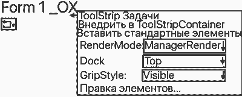

Рис. 20.4. Меню выбора стандартных элементов.

Удалите все ненужные Вам кнопки и добавьте новые элементы, если в этом есть необходимость. **В-третьих**, создать значок для кнопки можно с помощью внешнего растрового редактора или встроенного в `Visual Studio`. Наиболее распространенный формат файла со значком — `bmp`. Если Вы создаете значок во встроенном редакторе, то рекомендуется удалить значки неподходящего размера, оставив, например, только 16х16. Для этого в меню «Изображение» сначала сделайте удаляемый значок текущим («Текущие типы изображений значков»), а затем выбранный тип удалите («Удалить тип изображений»).

Страница 238

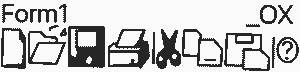

Рис. 20.5. Стандартные элементы.

Контекстное меню любой кнопки панели инструментов позволяет с помощью пункта «Задать рисунок...» открыть окно «Выбор ресурса» и импортировать рисунок из файла (см. рис. 20.6).

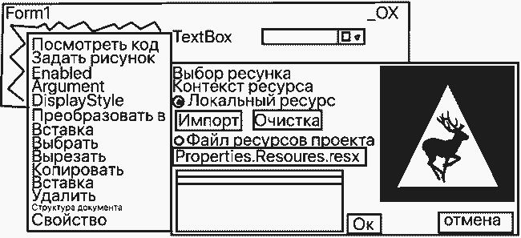

Рис. 20.6. Выбор значка.

**Добавление инструмента на панель с помощью свойства `Items`**. Добавить элемент на панель инструментов можно двумя способами: **во-первых**, с помощью щелчка значка макета или его стрелки с последующим выбором типа добавляемого элемента; **во-вторых**, используя свойство Items в окне «Свойства» компонента ToolStrip. Первый способ был продемонстрирован в начале данного раздела, поэтому рассмотрим второй способ. Выделите панель ToolStrip и выберите свойство Items. Появится окно «Редактор коллекции элементов» (см. рис. 20.7).

Страница 239

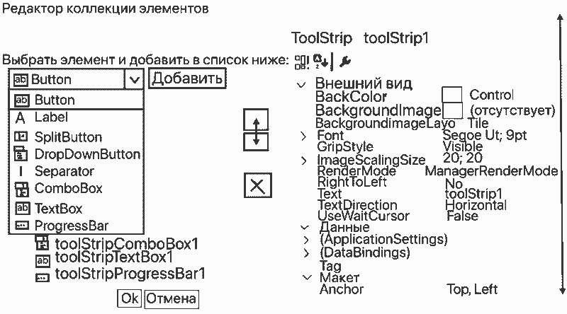

Рис. 20.7. Окно редактора коллекции элементов.

В окне «Редактор коллекции элементов» перечислены ранее добавленные элементы и предлагается добавить новый элемент. В правой части окна перечислены свойства выбранного элемента. Это те же свойства, что и в окне свойств, поэтому, каким окном пользоваться, разработчик решает самостоятельно. Для каждого добавляемого инструмента можно изменить его свойства `Text` и `Name`. Используя свойство `Image` инструмента, откройте окно «Выбор ресурса» (см. рис. 20.6) и импортируйте изображение из существующего файла. В обоих способах для каждого инструмента создайте либо свой обработчик события, либо укажите обработчик пункта меню, соответствующего инструменту.

Страница 240

# 20.3. Пример использования ToolStrip.

Рассмотрим простой пример применения компонента `ToolStrip`. Создадим панель инструментов, состоящую из элементов `ComboBox`, `SplitButton`, `DropDownButton` и `Button`. Добавим на форму элемент `Label` (см. рис. 20.8).

Form1 _OX

- Петров ↓ картинка ↓ картина ↓ картинка ↓

Студент Петров по дисциплине «Математика» получил «зачтено».

Рис. 20.8. Окно с панелью инструментов.

Необходимо выбрать из списка `ComboBox` панели инструментов фамилию студента, из списка элемента `SplitButton` — название дисциплины и из списка элемента `DropDownButton` — оценку. Заполним первые два списка произвольными данными, а третий СПИСОК значениями «Зачтено» и «Не зачтено». На рис. 20.8 показан пример, в котором перед нажатием кнопки `Button` были выбраны значения «Петров», «Математика» и «Зачтено».

Страница 241

Определим три переменные для хранения выбранных из списков значений: `string name = ""`, `dis = ""`, `zach = ""`; Создадим обработчик события `Click` для первого значения списка `SplitButton`. Переименуем этот обработчик в имя дисциплина `ToolStrip_Click`. Для остальных значений списка будем использовать этот же обработчик. Аналогично поступим для значений списка `DropDownButton`. Обработчики будут выглядеть следующим образом:

```
private void дисциплинаТоо|Strip_Click(object sender, EventArgs e)
{ dis = sender.ToString(); }
private void зачтено ToolStripMenuItem_Click(object sender, EventArgs e)
{zach = sender.ToString();}
```

Строковое представление первого аргумента `sender` возвращает текст выбранного элемента списка. В обработчике кнопки выполним серию проверок, исключающих использование невыбранных значений.

Страница 242

Полный текст Form1.cs:

```
using System;
using System.Windows.Forms;
namespace WindowsFormsApplication24
{
    public partial class Form1 : Form
    {
        public Form 1() { Initialize componente; }
        string name = "";
        dis="";
        zach = "";
        private void дисциплинаТоо/StripMenuItem_Click(object sender, EventArgs e)
        { dis = sender.ToString(); }
        private void зачтеноТооlStripMenuItem_Click(object sender, EventArgs e)
        { zach = sender.ToString();}
```

```
        private void toolStripButton1_Click(object sender,EventAras e)
        {
            name = toolStripComboBox1.Text;
            if (name == "")
            { MessageBox.Show("Не выбрана фамилия."); return; }
            if (dis == "")
            { MessageBox.Show("Не выбрана дисциплина."); return; }
            if (zach == "")
            { MessageBox.Show("Не выбрана оценка."); return; }
            label1.Text = "Студент" + name + " по дисциплине " + dis + " получил \"" + zach + "\";
        }
    }
}
```

В других программах для каждого значения списка может быть создан свой обработчик событий.

Страница 243

# 20.4. Дополнительные возможности `ToolStrip`

Использование элементов управления `ToolStrip` имеет богатый опыт разработки, включая активацию на месте и редактирование, пользовательский макет и совместное использование горизонтального или вертикального пространства в указанном `ToolStripContainer`. Класс `ToolStrip` предоставляет множество элементов, обеспечивающих управление рисованием, вводом с помощью мыши и клавиатуры, а также функции перетаскивания. Для получения больших возможностей настройки и контроля стиля оформления и макета для всех элементов управления `ToolStrip` в `Windows Form` можно использовать класс `ToolStripRenderer` совместно с классом `ToolStripManager`. Можно объединить элементы управления `ToolStrip` в рамках заданного объекта `ToolStripContainer` и произвести слияние элементов управления `ToolStrip` друг с другом. Для приложений многодокументного интерфейса (`MDI`) используйте `ToolStripPanel` вместо объекта `ToolStripContainer`. Обычно объект `ToolStrip` не применяется в последовательности перехола, за исключением случаев, когда он имеет абсолютное положение, а не закреплен или находится в `ToolStripPanel`.

Страница 244

Используйте класс `ToolStripControlHost` для размещения любых других элементов управления `Windows Forms` в объекте `ToolStrip`. Элемент управления `ToolStrip` имеет множество свойств, методов и событий, что позволяет легко настроить внешний вид и поведение панели инструментов. Ниже приведены некоторые значимые члены:

- **Dock** — возвращает или задает край родительского контейнера, к которому прикрепляется элемент управления `ToolStrip`.
- **AllowItemReorder** — возвращает или задает значение, указывающее, будут ли операции перетаскивания и переупорядочения элементов обрабатываться классом `ToolStrip` в закрытом режиме.
- **LayoutStyle** — возвращает или задает значение, указывающее, как элемент управления `ToolStrip` выполняет размещение своих элементов.
- **Overflow** — возвращает или задает значение, указывающее, вложен ли элемент управления `ToolStripItem` к элементу управления `ToolStrip` или `ToolStripOverflowButton` или он может перемещаться между ними.
- **IsDropDown** - возвращает значение, указывающее, отображает ли элемент управления `ToolStripItem` другие элементы в раскрывающемся списке при выборе элемента управления `ToolStripItem`.
- **OverflowButton** — возвращает значение элемента `ToostripItem`, который является кнопкой переполнения для элемента управления `ToolStrip` с включенной функцией переполнения.
- **Renderer** — возвращает или задает значение для элемента управления `ToolStripRenderer`, используемого для настройки внешнего вида и поведения элемента управления `ToolStrip`.
- **RenderMode** - возвращает или задает стили оформления для злемента управления `ToolStrip`.
- **RendererChanged** — используется при изменении свойства `Renderer`.

Страница 245

Кроме классов `MenuStrip`, `StatusStrip`, `ContextMenuStrip.ToolStripItem`, с классом `ToolStrip` связано несколько сопутствующих классов, повышающих гибкость панели инструментов. Ниже приведены некоторые из них:

- **ToolStripContainer** — предоставляет контейнер с панелями на каждой стороне формы, в которых можно по-разному расположить элементы управления.
- **ToolStripRenderer** - предоставляет функциональные возможности для форматирования объектов `ToolStrip`.
- **ToolStripProfessionalRenderer** - обеспечивает внешний вид, аналогичный `Microsoft Office`.
- **ToolStripManager** - управляет отрисовкой и нависанием элемента управления `ToolStrip`, а также слиянием объектов `MenuStrip`, `ToolStripDropDownMenu` и `ToolStripMenuItem`.
- **ToolStripManagerRenderMode** - определяет стиль оформления (настраиваемый, `Windows ХР` или `Microsoft Office Professional`), который применяется к нескольким содержащимся в форме объектам `ToolStrip`.
- **ToolStripRenderMode** — определяет стиль оформления (настраиваемый, `Windows ХР` или `Microsoft Office Professional`), который применяется к одному содержащемуся в форме объекту `ToolStrip`.
- **ToolStripControlHost** — размещает другие элементы управления, которые не входят в состав элемента управления `ToolStrip`, но для которых необходимо использовать функции элемента управления `ToolStrip`.
- **ToolStripItemPlacement** — указывает расположение элемента `ToolStripItem`: на главном элементе управления `ToolStrip`, на переполнении `ToolStrip` или ни один из этих вариантов.

Страница 246

# 20.5. Задания для самостоятельной работы.

**Задача 1**. Разработать приложение с формой, содержащей меню со следующими пунктами: `О программе`, `О разработчике`, `Выход`. Для вывода информации использовать диалоговое окно `MessageBox`. При выборе пункта «Выход» для завершения программы использовать метод `Close`. Перед закрытием программы запросить у пользователя подтверждение. Продублировать перечисленные пункты меню элементами панели инструментов. Значки разработать самостоятельно.

Страница 247

**Задача 2**. Разработать приложение с формой, содержащей кнопку `Button` с текстом «Выход» и поле `TextBox` для ввода фамилии пользователя. Добавить на форму панель инструментов со следующими элементами типа `ToolStripComboBox`: `Цвет фона`; `Цвет текста`. Каждый комбинированный список должен содержать следующие элементы: `Белый`; `Черный`; `Желтый`; `Красный`; `Синий`; `Зеленый`. При выборе цвета фона или цвета текста выполнить перекраску кнопки и текстового поля. Значки выбрать из числа стандартных.

**Задача 3**. Разработать приложение для вычисления частного от деления двух вещественных чисел. Исходные числа вводить в текстовые поля. Результат отображать в элементе управления `Label`. Для определения количества дробных цифр в частном использовать панель инструментов с четырьмя элементами типа `ToolStripButton`. Значки элементов должны обозначать длину дробной части и, соответственно, отображать цифры: 1, 2, 3 и 4.

Страница 248

# 21. СТРОКА СОСТОЯНИЯ.

**Пример**. Создать строку состояния с двумя элементами типа `ToolStripStatusLabel`. В первом элементе отобразить текущую дату, а во втором — версию программы. Перетащите на форму `StatusStrip` и добавьте следующий текст в обработчик `Form1_Load`:

```
private void Form1_Load(object sender, EventArgs e)
{
    toolStripStatusLabel1.Text = DateTime.Now.ToLongDateString();
    toolStripStatusLabel2.Text = " Версия программы 2.1";
}
```

Окно, соответствующее этому примеру, приведено на рис. 21.1.

Страница 249

Form1 $\_OX$

24 февраля 2018 г. Версия программы 2.1

Рис. 21.1. Окно со строкой состояния

Страница 250

Подробно элемент управления ProgressBar описан во втором томе учебника. Изучите ProgressBar и компонент Timer, прежде чем использовать элемент управления ToolStripProgressBar.

Рис. 21.2. Окно с непрерывной полосой `ProgressBar`

Часто те или иные процессы разработчики моделируют с помощью компонента `Timer`. В этом случае протекание процесса иногда демонстрируют с помощью `ToolStripProgressBar`.

Страница 251

# 22.1. Общие сведения.

Таймер для приложений `Windows Forms` представлен компонентом `Timer`, находящимся в пространстве имен `System.Windows.Forms`. Данный таймер разработан для однопоточной среды `Windows`. Класс `Timer` достаточно значим, так как ряд задач не может быть решен без использования таймера. Основное назначение таймера — вызов события `Tick` через определенные пользователем интервалы времени и вызов обработчика этого события. В режиме визуального проектирования, после перетаскивания таймера на форму, создается обработчик событий `Тіск`. Как правило, это выполняется с помощью двойного щелчка таймера на панели компонентов. После истечения временного интервала таймер не прекращает свою работу, а начинает очередной отсчет интервала. В разделе 23.4 приведен пример программы, в которой создается окно, плавно появляющееся и плавно исчезающее с экрана. Плавность достигается путем постепенного изменения прозрачности формы в обработчике событий таймера. **Класс `Timer`** имеет небольшое количество важных членов, к числу которых относятся следующие:

- **Свойство `Interval`** — определяет временной интервал между событиями `Tick` в миллисекундах.
- **Свойство `Enabled`** - запускает (`true`) или останавливает (`false`) таймер.
- **Метод `Start`** — запускает таймер. Начинает вызывать событие `Tick`, задавая для свойства `Enabled` значение `true`.
- **Метод `Stop`** — прекращает вызывать событие `Тіск`, задавая для свойства `Enabled` значение `false`.

**Работа таймера** заключается в генерации событий `Tick` через период времени `Interval`. Таймер может быть запущен, если `Interval` > 0. Таймер можно остановить, обнулив значение свойства `Interval`.

Страница 252

**Пример**. Разработаем приложение для отображения текущего времени. После создания проекта и отображения формы перетащим на форму компонент `Timer`, кнопки для запуска и остановки часов, а также элементы управления `Label` и `TextBox`. Щелкнем дважды элемент `timer1` — будет создан обработчик событий `Тіск`. Код программы приведен ниже:

```
public partial class Form1 : Form
{
    public Form1()
    {
        InitializeComponent();
        timer1.Interval = 1000; // 1 секунда.
        timer1.Enabled = false;
    }
    private void timer1_Tick(object sender, EventArgs e)
    { textBox1.Text = DateTime.Now.ToString("HH:mm: ss"); }
    private void buttonStart _Click(object sender, EventArgs e) CE
    { timer1.Enabled = true; }
    private void buttonStop_Click(object sender, EventArgs e)
    { timer1. Enabled = false; }
}
```

Во время выполнения программы отображается окно, представленное на рис. 22.1.

Страница 253

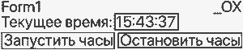

Рис. 22.1. Окно с часами.

При работе с таймером следует обращать внимание на продолжительность обработки события Тіск. Предположим, Вы поместили в обработчик вызов диалогового окна `MessageBox`:

```
int i = 1;
private void timer1_Tick(object sender, EventArgs e)
{
    textBox1.Text = DateTime.Now.ToString("HH:mm:ss");
    MessageBox.Show("Вход в обработчик №" + i++);
}
```

Тогда, пока Вы не выйдете из диалога, может произойти множество событий `Тіск`. Каждое событие будет вызывать на выполнение обработчик, параметры которого будут накапливаться в стеке вплоть до его переполнения (см. рис. 22.2).

Страница 254

Смотри рисунок Рис. 22.1. Окно с часами. На этом рисунке всё то же самое, только несколько поверх наложенных друг на друга всплывающих окон с сообщением «А вы вошли в обработчик номер шесть, нажмите ОК».

Рис. 22.2. Параллельное выполнение экземпляров обработчика.

Чтобы не происходили параллельные выполнения экземпляров обработчика события `Тіск`, необходимо придерживаться следующего правила: время выполнения обработчика должно быть меньше временного интервала, заданного свойством `Interval`. Если это условие не выполняется, то следует в обработчике события `Tick` остановить таймер, выполнить обработку и затем снова запустить таймер. Например:

```
int i = 1;
private void timer1__Tick(object sender, EventArgs e)
{
    textBox1.Text = DateTime.Now.ToString("HH:mm:ss");
    timer1.Enabled = false;
    MessageBox.Show("Вход в обработчик Nº" + |++);
    timer1.Enabled = true;
}
```

При таком подходе новое событие `Тіск` не произойдет, пока не будет обработано предыдущее (см. рис. 22.3).

Страница 255

Смотри рисунок Рис. 22.1. Окно с часами. На этом рисунке всё то же самое, только несколько поверх наложенных друг на друга всплывающих окон с сообщением «А вы вошли в обработчик номер пять, нажмите ОК».

Рис. 22.3. Последовательное выполнение вызовов обработчика.

На рис. 22.3 показано, что обработка пятого события `Tick` происходит после завершения обработки предыдущих четырех событий. Кроме таймера, разработанного для `Windows Forms`, есть еще несколько таймеров: таймер из пространства имен `System.Timers` и таймер из пространства имен `System.Threading`. **Компонент `Timer`** пространства имен `System.Windows.Forms` является однопоточным и ограничен точностью в 55 миллисекунд. Если необходим многопоточный таймер с большей точностью, используйте класс `Timer` пространства имен `System.Timers`. Компонент `Timer` пространства имен `System.Timers` представляет собой серверный таймер, позволяющий задать повторяющийся интервал (свойство `Interval`), по прошествии которого в приложении будет вызываться событие `Elapsed`. После генерации это событие можно обработать. Серверный `Timer` предназначен для использования с рабочими потоками в многопоточной среде. По набору свойств данный таймер похож на таймер пространства имен `System.Windows.Forms`. Поскольку серверного таймера нет на панели элементов, создание экземпляра и подписку на событие Elapsed необходимо делать вручную.

Страница 256

**Пример**. Модифицируем пример для однопоточного таймера с целью использования многопоточного таймера.

```
public partial class Form1 : Form
{
    System.Timers.Timer timer1;
    public Form1()
    {
        InitializeComponent();
        timer1 = new System.Timers.Timer();
        timer1.Elapsed += OnTimedEvent;
        timer1.Interval = 1000; // 1 секунда.
        timer1.Enabled = false;
    }
    private void OnTimedEvent(object sender, EventArgs e)
    { textBox1.Text = DateTime.Now. ToString("HH: mm:ss"); }
    private void buttonStart_Click(object sender, EventArgs e)
    { timer1.Enabled = true; }
    private void buttonStop Click(object sender, EventArgs e)
    { limert. Enabled = false; }
}
```

Страница 257

Страница 248

Перетащим кнопку и таймер на форму. Скопируем в программу следующий код программы.

```
using System;
using System.IO;
using System.Threading;
using System.Windows.Forms;
namespace WindowsFormsApplication
{
    public partial class Form1 : Form
    {
        bool NET = false; // Папка не найдена: сеть отключена.
        public Form1() { InitializeComponent); }
        private void button1_Click(object sender, EventArgs e)
        {
            // Запустить таймер на ожидание подключения к сети.
            timer1.Interval = 3000;
            timer1.Enabled = true;
        }
```

Страница 259

```
        private void timer1_Tick(object sender, EventArgs e)
        {
            timer1. Enabled = false;
            // Временно отключаем таймер.
            Thread t1 = new Thread(TestNet);
            t1.IsBackground = true;
            t1.Start(); // Запустить проверку сети на разрыв.
            if (!t1.Join(3000)) // Ждать завершение потока.
            {
                // Поток НЕ завершился, значит, папка НЕ обнаружена!
                // К сети не подключился.
                t1.Abort();
                // Не дождались завершения потока: сеть разорвана.
                timer1.Enabled = true; // Снова включаем таймер.
                return;
            }
            if (NET = = false)
            {
                timer1.Enabled = true; // Снова включаем таймер,
                return; // Папка не найдена.
            }
            // ----Появилась сеть.
            MessageBox.Show ("Компьютер подключен к сети!");
        }
```

```
        // Потоковый метод.
        public void TestNet()
        {
            try
            {
                // Проверить доступность корневого каталога.
                if (Directory. Exists("0:\\"))
                    NET = true; // Папку нашли.
            }
            else { NET = false;} // Папку НЕ нашли.
        }
        catch
        {
            // Неясная ситуация! Папку НЕ нашли.
            NET = false;
        }
```

Страница 260

На рис. 22.4 показан вывод сообщения о подключении компьютера к сети.

Форма первая с кнопкой запустить таймер по верхнюю всплывающую окно компьютер подключен к сети с кнопкой.

Рис. 22.4. Вывод сообщения о подключении компьютера к сети.

Поскольку интервал проверок не превышает время ожидания реакции системы, таймер в обработчике события `Tick` перед ожиданием отключается и снова включается для продолжения проверок. Для выполнения приведённой выше программы на локальном компьютере, не подключённом к сети, достаточно перед запуском программы переименовать проверяемую папку, а после запуска вернуть папке исходное имя.

# 22.3. Задания для самостоятельной работы.

**Задача 1**. Разработать приложение с формой, содержащей строку состояния с элементом типа ToolStripStatusLabel для отображения текущего времени. Значение времени обновлять через секунду, для чего запустить таймер с интервалом в 1 сек. и в обработчике события `Тіск` осуществлять вывод в строку состояния текущего времени.

**Задача 2**. Разработать приложение с формой, содержащей кнопку `Button` с текстом `Start`. Кнопка должна примыкать к левой границе формы. По этой кнопке запустить таймер с интервалом в 2 сек. В обработчике события `Тіск` осуществить увеличение координаты кнопки по оси `Х` на 4 пикселя. Кнопка должна двигаться по горизонтальной оси вправо. Перед началом движения заменить текст `Start` на текст `Stop`. Для остановки движения и возврата кнопки в исходное состояние использовать эту же кнопку.

Страница 261

**Задача 3**. Разработать приложение, выводящее бегущую строку. Процесс перемещения смоделировать с помощью таймера.

- **Вариант 1**: использовать перемещение `Label`.
- **Вариант 2**: использовать движение текста внутри `TextBox`.

**Задача 4**. Разработать приложение, выводящее в центр окна произвольный текст. По кнопке `Button` с помощью таймера запустить процесс мерцания текста.

**Задача 5**. (Для «продвинутых» студентов.) Создать приложение, определяющее момент разрыва вычислительной сети, а также определяющее момент появления сети.

Страница 262

# 23.1. Что такое `SDI-` и `MDI-`интерфейсы.

В зависимости от характера поставленной задачи разработчик может создать многооконное приложение с однодокументным (`SDI`) или многодокументным интерфейсом (`MDI`). Приложения с многооконным интерфейсом `MDI` позволяют отображать несколько документов сразу, при этом каждый документ отображается в отдельном окне, как в приложении `MS Word`. Приложения `SDI` позволяют одновременно открывать только одно окно документа. Понятие «документ» для интерфейса `SDI` является условным, так как зачастую никаких документов приложение не обрабатывает. Если не замыкаться на документах, то можно дать такое определение: в многооконном приложении с интерфейсом `SDI` все окна являются модальными; в многооконном приложении с интерфейсом `MDI` отдельные окна являются немодальными. **Модальное окно** — это такое активное окно приложения, с которого нельзя переключиться на любое другое окно этого приложения, пока не будет закрыто текущее. **Пример**. Окно, отображаемое следующим вызовом, является модальным. `MessageBox.Show("Модальное окно");`

**Немодальное окно** не препятствует пользователю переключаться на другие окна данного приложения, не закрывая активное. Такая модель как нельзя лучше подходит для приложений, запрограммированных для одновременной обработки нескольких документов. Приложения с интерфейсом `SDI` — это традиционные приложения, они проще приложений с интерфейсом `MDI`, поэтому мы начнем изучение взаимодействия окон с изучения интерфейса `SDI`. Независимо от вида интерфейса приложения, все окна являются объектами базового класса `Form`, имеющего богатую функциональность. Изучению этой функциональности посвящен следующий подраздел. Если одна форма создает другую, то первая является **родительской**, а вторая — **дочерней**.

Страница 263

# 23.2. Базовый класс Form.

**Класс `Form`** является представлением любого окна, отображаемого в приложении. Этот класс используется для создания стандартных окон, окон инструментов, не обрамленных и перемещаемых окон. Класс `Form` также используется для создания модальных окон, например диалоговых окон. Особым видом формы является форма интерфейса `MDI`, содержащая другие формы, называемые дочерними `MDI`-формами. `MDI`-форма создается посредством задания для свойства `IsMdiContainer` значения `true`. Дочерние `MDI-формы` создаются с помощью установки свойства `MdiParent` в значение, равное ссылке на родительскую `MDI-форму`, которая будет содержать дочернюю форму. **Класс `Form`** является наследником многих классов, включая `Control` и `Component`, и с этой точки зрения является отображаемым элементом управления. Однако в окне элементов этот класс не представлен, так как одна форма не может включать в свой контейнер другую форму. Тем не менее форма может создать другую, дочернюю форму и передать ей управление в одном из своих обработчиков событий. **С помощью свойств**, доступных в классе `Form`, имеется возможность определить внешний вид, размер, цвет и компоненты управления создаваемого окна или диалогового окна. Свойство `Text` позволяет задавать заголовок окна в строке заголовка. С помощью свойств `Size` и `DesktopLocation` определяются размер и положение окна при его отображении. Имеется возможность использовать свойства `Font` и `ForeColor` для изменения назначенного по умолчанию шрифта и цвета текста всех элементов управления, помещенных в форму. Свойство `BackColor` меняет цвет фона формы. Свойства `FormBorderStyle`, `MinimizeBox` и `MaximizeBox` позволяют управлять возможностью свертывания, развертывания или изменения размера формы во время выполнения.

Страница 264

Помимо свойств, для управления формой используются методы класса `Form`. Например, метод `ShowDialog` используется для отображения формы как модального диалогового окна. Имеет возможность использовать метод `SetDesktopLocation` для размещения формы на рабочем столе. **События класса `Form`** позволяют отвечать на действия, выполненные с формой. Часто используют событие `Load` для выполнения таких операций, как загрузка данных, отображаемых в элементах управления формы при ее активации. **Как и любое** консольное приложение, приложение `Windows Forms` имеет точку входа, определяемую методом `Main`. В методе `Main` содержится код для создания и отображения главной формы приложения. Если главная форма закрывается, закрывается также и приложение. Если закрывается дочерняя форма, то управление возвращается в родительскую (`SDI`-интерфейс). **В случае** создания многооконного приложения дочерних форм может быть несколько. Каждая форма может содержать свои элементы управления. В среде `Visual Studio` новую форму можно добавить в проект, используя окно шаблонов «Добавить новый элемент...». Для этого щелкните правой кнопкой строку проекта и в контекстном меню выберите «Добавить». Далее выберите пункт «Форма Windows». Отобразится окно шаблонов, настроенное на форму. Измените имя формы, если это необходимо. Нажмите кнопку «Добавить». После этого отобразится новое окно для его проектировання.

Страница 265

Первая форма приложения по умолчанию имеет имя `Form1`, в `Visual Studio` отображается в виде пустого окна, готового для заполнения элементами управления. Имя `Form1` — это имя пользовательского класса, описывающего форму. Класс находится в файле `Form1.cs`. Выделите в Обозревателе решения строку `Form1.cs` и щелкните кнопку <> — в окно Редактора кода будет выведено следующее содержимое файла:

```
public partial class Form1: Form
{
    public Form 1()
    {
        InitializeComponent();
    }
}
```

Мы видим, что форма `Form1` является наследником системного класса `Form`. Класс `Form1` является частичным классом; в `Visual Studio` открывается ее первая часть, содержащая заголовок класса и конструктор `Form1`. Конструктор вызывает метод `InitializeComponent`, определенный во второй части класса, размещенной в файле `Form1.Designer.cs`. Вторая часть создается автоматически в режиме визуальной разработки, поэтому бездумно изменять ее содержимое не рекомендуется. Мы рассмотрим содержимое второй части класса `Form1` после добавления нескольких элементов управления, так как тогда будет понятна архитектура класса. Первая часть класса адресуется разработчику для создания пользовательских членов: полей, свойств, методов и обработчиков событий. Главная форма, как и любая другая, во время выполнения может создать и отобразить дочернюю форму. Для этого необходимо определить, в каком обработчике события должен находиться код для создания и отображения дочернего окна. После этого в выбранном обработчике необходимо создать экземпляр новой формы и вывести ее на экран с помощью метода `ShowDialog`.

Страница 266

**Пример**. Ниже, в обработчике события `button1_Click`, отображается форма `Form2`. Предполагается, что форма `Form2` была добавлена в проект способом, описанным выше. Экземпляру формы в примере присвоено имя `form2`.

```
private void button1_Click(object sender, EventArgs e)
{
    // Создать новый экземпляр формы.
    Form2 form2 = new Form2();
    // Отобразить форму как модальное диалоговое окно.
    form2.ShowDialog();
}
```

Главная форма приложения создается в методе `Main` в результате вызова её конструктора в операторе `Application.Run(new Formi);`. Метод `Main` определен в классе `Program` и находится в файле `Program.cs`. Можно изменить эти имена. Конструктор формы получает управление и вызывает метод `InitializeComponent`, в котором осуществляется инициализация всех элементов управления и самой формы. После выхода из конструктора возникает несколько событий, форма становится видимой, и ей передается фокус ввода. Размер формы по умолчанию — 300 пикселей в высоту и 300 пикселей в ширину.

После инициализации формы в конструкторе события происходят в следующей последовательности:

1. Load — форма существует, но не отображена. Событие возникает один раз перед отображением формы.
2. Activated — форма становится видимой и текущей. Событие может возникать несколько раз за время существования окна в зависимости от действий пользователя, например, при разворачивании свернутого окна.

Страница 267

Разработчики часто вставляют свой код в конструктор и (или) в обработчик `Form_Load`. Поскольку форма еще не отображена, здесь удобно выполнять подготовительные работы, например создание источника данных, чтение параметров из файла и т. д. Однако некоторые операции зависят от того, в каком месте они выполняются. К такой операции, например, относится установка доступности всех элементов управления формы (свойство `Enabled`). Если в конструкторе формы для свойства `Enabled` установить значение `false`, все элементы управления формы будут недоступны, кроме стандартных кнопок в заголовке формы (кнопки «Редактор скриптов», свертывания, максимизирования, закрытия и системной кнопки). Например:

```
public Form1()
{
    InitializeComponent);
    Enabled = false;
}
```

Если для `Enabled` указать значение `false` в обработчике какого-либо события, например `Load` или `Activated`, перечисленные кнопки заголовка формы будут отключены. Такую форму можно будет закрыть либо диспетчером задач, либо из другой активной формы. **Метод `ShowDialog`** отображает дочернюю форму в виде модального диалогового окна. При вызове этого метода родительская форма передает управление в дочернюю форму, и код, следующий за методом `ShowDialog`, не выполняется до закрытия дочерней формы. Так как `ShowDialog` не создает новых экземпляров, то его можно выполнять повторно — все старые значения формы будут видны. Немодальные окна отображаются с помощью других средств.

Страница 268

# ОСНОВНЫЕ СОБЫТИЯ ФОРМЫ.

К основным событиям формы, с которыми разработчики чаще всего имеют дело, относятся:

- **Load** — возникает перед отображением формы на экране,
- **FormClosing** - возникает перед закрытием окна. Закрытие окна может быть инициировано методом `Close` или системной кнопкой Закрыть. В обработчике этого события можно выполнить некоторые проверки и по результатам проверки отменить закрытие окна, в результате чего событие `FormClosed` не произойдет.
- **FormClosed** - возникает после закрытия окна, если это событие не было отменено при обработке события `FormClosing`.

Все элементы управления, которые должны отображаться на форме, должны быть добавлены методом Add в коллекцию `Controls` формы. Такой код в `Visual Studio` генерируется автоматически. Случаи, когда требуется вручную добавлять элементы управления в форму, весьма редки, тем не менее приведем пример такой работы.

**Пример**. В следующем фрагменте кода создается новая форма и используется метод `Add` коллекции `Controls` формы для добавления двух элементов управления типа `Button`.

```
Form form2 = new Form();
form2.Text = "Диалоговое окно";
// Создать кнопки и установить их свойства.
Button button 1 = new Button();
button1.Text = "OK";
witonl.Location = new Point (10, 10);
Button button2 = new Button ();
Witon2.Text = "Cancel";
cutton2.Location = new Point (button1.Left,button1.Height + button1.Top + 10);
// Добавить кнопки в коллекцию формы.
form2.Controls.Add(button1);
form2.Controls.Add(button2);
// Вывести окно.
form2.ShowDialog();
```

Страница 269

# 23.3. Закрытие модального окна.

Как было отмечено выше, родительская форма может отобразить дочернее модальное окно методом `ShowDialog`. При этом родительская форма блокируется до завершения работы с дочерней. Завершить свою работу дочерняя форма может, закрыв себя методом `Close` или системной кнопкой закрытия. При закрытии формы происходит несколько событий в следующей последовательности: `FormClosing` — попытка закрыть форму; `FormClosed` — после закрытия формы; `Deactivate` — после закрытия формы. Если обработчик события `FormClosing` установит `e.Cancel = true`, то форма останется открытой, `e.Cancel = false` — форма закроется, и возникнут события `FormClosed` и `Deactivate`. Если дочерняя форма была отображена с помощью метода `ShowDialog` и она закрывается методом `Close`, окно скрывается с экрана, но не удаляется. При этом метод `Dispose`, определенный во второй части класса формы (в файле `Formx.Designer.cs`), не получает управления. Если требуется очистить все используемые управляемые ресурсы, вызовите метод `Dispose` вручную. Если же закрывается главная форма, метод `Dispose(true)` класса формы автоматически получает управление.

Страница 270

После вызова `Close`, выданного для закрытия текущего окна, окно исчезает с экрана, при этом программа продолжает свою работу с оператора, следующего за `Close`. То есть форма не прекращает свое выполнение! Это может повлечь серьезные проблемы. Рассмотрим следующий пример, код которого приведен ниже. Пусть форма закрывается, если некоторый файл, например `File1.txt`, существует, иначе файл создается.

```
private void button1_Click(object sender, EventArgs e)
{
    if (File.Exists("File1.txt"))
        Close();
    // Файла нет, создаем новый.
    File.Create("File1.txt");
    // Файла нет, создаем новый.
    File.Create("File1.txt");
}
```

Если файл `File1.txt` существует, то форма закрывается, то есть становится невидимой, однако обработчик `button1_Click` продолжит выполнение операторов. Следующим оператором после `Close` выполнится создание нового файла `File1.txt`, что приведет к очистке существующего файла, то есть пользователь потеряет информацию, хранящуюся в файле. Следовательно, код примера является некорректным. Правильным решением является следующее:

```
private void button1_Click(object sender, EventArgs e)
{
    if (File.Exists("File1.txt"))
    {
        Close();
        return;
    }
    // Файла нет, создаем новый.
    File.Create("File 1,txt");
}
```

Таким образом, после оператора `Close` рекомендуется выполнить действия, приводящие к выходу из обработчика. Это может быть или использование оператора `return`, или передача управления на конец обработчика. По той же причине не рекомендуется помещать `Close` во внутренние методы, вызываемые из обработчиков событий. Приведем пример некорректного завершения программы из внутреннего метода. Пусть обработчик `button1_Click` вызывает метод `Method1`, в котором выполняется закрытие формы.

```
private void button1_Click(object sender, EventArgs e)
{
    Method1();
    // Эти операторы будут выполнены после Close().
}
private void Method1() { Close(); }
```

Страница 271

В этом примере, после закрытия формы в методе `Method1`, обработчик `button1_Click` продолжит выполнение операторов, расположенных ниже вызова метода (отмечены многоточием). Рассмотрим процесс закрытия формы более подробно. Вызов метода `Close` приводит к выполнению обработчиков событий `FormClosing` и `Form1_FormClosed`, если они есть. Для главной формы выполняется метод Dispose, находящийся в файле `Designer.cs`. Далее, окно скрывается с экрана (`Visible = false`). Если форма является главной, то в очередь сообщений записывается сообщение с кодом 0 для завершения программы. Для того чтобы обработать это сообщение, Ваша программа должна выйти из того обработчика событий, в котором находится в текущий момент времени. Обработка сообщения с кодом 0 приводит к уничтожению формы (`this = null`) и передаче управления в метод `Main` для его завершения. Один из способов удаления дочерней формы — удалить ссылку на неё. Если ссылка на дочернюю форму будет удалена, то она будет уничтожена сборщиком мусора (правда, не сразу). Другой способ принудительного завершения программы основан на возможности операционной системы завершить любой процесс. Для этого после Close используем функцию `Environment.Exit(exitCode);` Метод `Environment.Exit` завершает текущий процесс и возвращает операционной системе указанный код выхода. Ресурсы этот метод не освобождает; рекомендуется предварительно их освободить методом `Dispose`.

Страница 272

**Пример**. Ниже приведен обработчик события, вызывающий метод `Method`. Завершение программы происходит внутри этого метода. Перед завершением программы освобождаются ресурсы.

```
private void button1_Click(object sender, EventArgs e)
{ Method(); }
Private void Method()
{
    Dispose(true);
    Environment.Exit(O);
}
```

Страница 273

Вместо выполнения метода `Environment.Exit` целесообразнее было бы возвратить значение, указывающее на необходимость закрытия программы. Например:

```
private void button1_Click(object sender, EventArgs e)
{
    if(Method())
    {
        Close();
        return;
    }
}
private bool Method()
{
    return true;
    return false;
}
```

Последнее замечание: вызов метода `Close` в дочерней и в родительской форме дает разный эффект. Например, если дочерняя модальная форма закрыта в родительской (редкий случай), то повторный вызов метода `ShowDialog` без нового создания объекта формы вызывает исключение.

Страница 274

# 23.4. Настройка формы.

Рассмотрим использование отдельных свойств и методов класса `Form` для получения тех или иных эффектов.

# НАСТРОЙКА СТРОКИ ЗАГОЛОВКА.

Строка заголовка формы может иметь следующие составные части:

- значок, раскрывающий меню;
- текст;
- кнопка Справка — ?;
- кнопка свертывания — -;
- кнопка развертывания — п;
- кнопка закрытия — х (кнопка `Close`).

Для настройки строки заголовка формы можно использовать следующие свойства класса `Form`:

- **ControlBox** — возвращает или задает значение, указывающее, отображается или нет кнопка оконного меню в строке заголовка формы. Если `ControlBox=false`, то в строке отображается только текст заголовка.
- **HelpButton** — возвращает или задает значение, указывающее, отображается ли кнопка «Справка» в строке заголовка формы. Кнопка ? отображается, если кнопки развертывания и свертывания не отображаются.
- **MaximizeBox** — возвращает или задает значение, указываюшее, отображается ли кнопка «Развертывания» в строке заголовка формы.
- **MinimizeBox** — возвращает или задает значение, указывающее, отображается ли кнопка «Свертывания» в строке заголовка формы,
- **Showicon** - возвращает или задает значение, указывающее отображается или нет значок в строке заголовка формы.
- **Text** - получает или заласт текст заголовка формы.

На рис. 23.1 показано два окна со значениями свойств, отображенных в заголовке.

Страница 275

Форма. ControlBox=false; Кнопка выход.

Форма. HelpButton=true, MinimizeBox=MaximizeBox=false ; ? X

КНОПКА ВЫХОД.

Рис. 23.1. Изменение заголовка формы.

# ИЗМЕНЕНИЕ СТИЛЯ ФОРМЫ.

Свойство `FormBorderStyle` возвращает или задает стиль границы формы. Возможные значения стиля:

- **None** — нет границы;
- **FixedSingle** — фиксированная граница из одной линии;
- **Fixed3D** — фиксированная трехмерная граница;
- **FixedDialog** — толстая фиксированная граница стиля диалогового окна;
- **Sizable** — граница с изменяемыми размерами (значение по умолчанию);
- **FixedToolWindow** — неизменяемая граница окна инструментов. Окно инструментов не отображается ни на панели задач, ни в окне, появляющемся при нажатии пользователем сочетания клавиш `ALT+ТАВ`. Хотя формы, которые задают `FixedToolWindow`, обычно не отображаются в панели задач, необходимо также гарантировать, что для свойства `ShowinTaskbar` устанавливается значение `false`, так как его значение по умолчанию равно `true`;
- **SizableToolWindow** — изменяемая граница окна инструментов. Окно инструментов не отображается ни на панели задач, ни в окне, появляющемся при нажатии пользователем сочетания клавиш `ALT+TAB`.

Страница 276

Со стилем границы (свойство `FormBorderStyle`) связан внешний вид строки заголовка формы. Стиль определяет также наличие строки заголовка формы, значка и стандартных кнопок, а также внешний вид кнопки `Close`. Значения свойства `FormBorderStyle`, начинающиеся со слова `Fixed`, определяют форму `фиксированного` размера. Такую форму нельзя растянуть или сжать. При использовании стиля `Sizable` невозможно изменить размер окна ниже определенного минимального уровня, даже если установлено значение свойства `ControlBox` как `false`, а свойству `Text` присвоена строка нулевой длины. Рассмотрите возможность использования обходного пути посредством использования стиля `SizableToolWindow`. На рис. 23.2 показано, как выглядят окна при применении того или иного стиля формы. Последняя форма имеет стиль `None`. Название примененного стиля для остальных форм отображено в заголовке окна.

# ИЗМЕНЕНИЕ СОСТОЯНИЯ ОКНА.

Свойство `WindowState` возвращает или задает состояние окна формы. Состояние определяется членами одноименного перечисления:

- **Normal** — окно с размерами по умолчанию - 300×300 пикселей;
- **Minimized** — свернутос окто,
- **Maximized** - развернутое окно.

Страница 277

FixedSingle _OX

КНОПКА ВЫХОД.

Fixed3D _OX

КНОПКА ВЫХОД.

Sizabie _OX

КНОПКА ВЫХОД.

FixedDialog _OX

КНОПКА ВЫХОД.

FixedToclWindow X

КНОПКА ВЫХОД.

SizableToolWindow X

КНОПКА ВЫХОД.

КНОПКА ВЫХОД.

Рис. 23.2. Применение стиля формы

# СОЗДАНИЕ ОКНА НЕСТАНДАРТНОГО ВИДА.

Форма и элементы управления используют регионы для определения своей конфигурации. Регион — это графическая фигура, границы которой определяются объектом класса GraphicsPath. Операционная система не отображает части окна, лежащие вне региона окна. Для установления своих границ форма и элементы управления могут использовать свойство Region, унаследованное от класса Control. Свойство Region не отображается в окне свойств. Какой бы Вы ни задавали регион, область окна не может быть больше своего исходного размера, то есть регион может только уменьшить видимую область окна, но не увеличить.

Страница 278

**Пример**. Создание окна в виде полуэллипса.

```
private void Form1_Load(object sender, EventArgs e)
{
    GraphicsPath path = new GraphicsPath();
    path.AddEllipse(0, 0, this.Width * 2, this.Height);
    this.Region = new Region(path);
}
```

В примере сначала создается объект класса `GraphicsPath`, а затем в него добавляется эллипс. На экран выводится только та часть окна, которая видна через эллипс (рис. 23.3). Чтобы избавиться от границ окна, нужно уменьшить размер региона, но могут стать недоступными системные кнопки.

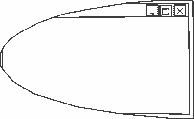

Рис. 23.3. Окно программы, ограниченное полуэллипсом.

**Пример**. Создание окна в виде эллипса (см. рис. 23.4). Создайте форму с элементами управления типа `Label` и `Button`. Присвойте свойствам `Text` элементов управления значения из рис. 23.4. Уберите рамку и заголовок формы, установив в окне свойств `FormBorderStyle=None`. Добавьте обработчики `Form1_Load`, `button1_Click`.

```
private void Form1_Load(object sender, EventArgs e)
{
    GraphicsPath myPath = new GraphicsPath();
    myPath.AddEllipse(0, 0, Width, Height);
    this.Region = new Region(myPath);
}
private void button1_Click(object sender, EventArgs e)
{ Close(); }
```

Это эллипсовидное окно.

Страница 279

Это эллипсовидное окно.

КНОПКА ВЫХОД.

Рис. 23.4. Окно программы, ограниченное эллипсом.

Недостатки такого окна очевидны. Во-первых, нет системной кнопки закрытия окна, поэтому такую кнопку необходимо продублировать, как на рис. 23.4. Во-вторых, нельзя изменить размер окна во время выполнения программы, так как нет прямоугольных границ. В-третьих, нет заголовка, используя который можно перемещать окно по экрану. Для решения последней, наиболее актуальной, проблемы можно добавить код, который позволил бы перемещать окно с помощью нажатой и удерживаемой клавиши мыши.

Страница 280

Модифицируем приведённый в примере код для решения этой задачи. Клавиша может быть нажата в любом свободном месте окна. Окно будет перемещаться вместе с перемещением курсора мыши.

```
using System;
using System.Drawing;
using System.Drawing.Drawing2D;
using System.Windows.Forms;
namespace WindowsEllipse
{
    public partial class Form1 : Form
    {
        int xPevScr, yPevScr;
        bool press = false;
        public Form1() { InitializeComponent); }
```

```
        private void Form1_Load(object sender, EventArgs e)
        {
            GraphicsPath myPath = new GraphicsPath();
            myPath.AddEllipse(0, 0, Width, Height);
            this.Region = new Region(myPath);
            xPevScr = Location.X;
            yPevScr = Location.Y;
        }
        private void Form1_MouseDown(object sender, MouseEventArgs e)
        {
            xPevScr = e.X + Location.X;
            yPevScr = e.Y + Location.Y;
            press = true;
        }
```

```
        private void Form1_MouseMove(object sender, MouseEventArgs e)
        {
            int CurScr = e.X + Location.X;
            int CurScr = e.Y + Location. Y;
            if (press)
            {
                Point pt = new Point(
                    Location. + xCurScr - xPevScr
                    , Location.Y + yCurScr - yPevScr
                );
                xPevScr = e.X + Location.X;
                yPevScr = e.Y + Location.Y;
                Location = pt;
            }
        }
        private void Form1_MouseUp(object sender, MouseEventArgs e)
        { press = false; }
        private void button1_Click(object sender, EventArgs e)
        { Close; }
    }
```

Страница 281

**Пример**. Вывод кнопки в виде эллипса с тенью (рис. 23.5). Создайте форму с кнопкой. Кнопка ограничивается эллипсом меньшего размера, чтобы не видеть её границ, поэтому исходная кнопка должна быть достаточно большой. Тень выводится путем вывода эллипса серого цвета со сдвигом вниз и вправо.

```
private void Form1_Paint (object sender, PaintEventArgs e)
{
    // Выводим эллипс серого цвета для изображения тени.
    e.Graphics.FillEllipse (Brushes.DarkGray
        , button1.Left + 15, button1. Top + 15
        , button1.Width - 10, button1. Height - 10
    );
    // Ограничиваем кнопку эллипсом меньшего размера.
    GraphicsPath shape = new GraphicsPath;
    shape.AddEllipse (5, 5
        , button1. Width - 10
        , button1. Height - 10
    );
    button1.Region = new Region (shape);
}
```

Результат выполнения приведённого фрагмента программы показан на рис. 23.5.

Страница 282

Form 1 _OX

НАДПИСЬ В Эллипсе НАЖМИ НА МЕНЯ

Рис. 23.5. Кнопка с тенью, ограниченная регионом

Во всех приведенных выше примерах в качестве региона использовался эллипс, хотя ограничивающей фигурой может быть любая, например звезда.

Страница 283

# ВСПЛЫВАЮЩЕЕ ОКНО.

Ниже показан способ плавного появления и плавного исчезновения окна. Таким окном может быть заставка с логотипом разработчика, названием приложения и т. д. Плавное появление и исчезновение окна базируется на использовании свойства `Form.Opacity`, которое определяет уровень прозрачности формы. Значение может меняться от 0.0 — совершенно прозрачная форма, до 1.0 — форма непрозрачная. Если менять прозрачность формы от 0.0 до 1.0 с некоторым шагом, то окно будет плавно проявляться на экране. **Плавное изменение** прозрачности может быть основано на использовании компонента `Timer`, который имеет два основных свойства: `Interval` и `Enabled`. Свойство `Interval` определяет временной интервал между событиями `Tick` в миллисекундах. А свойство `Enabled` запускает (`true`) или останавливает (`false`) таймер. Работа таймера заключается в генерации событий `Tick` через интервал `Interval`. **Приведем пример** фрагментов программы, выполняющей плавное появление и плавное исчезновение окна. Для этого создадим приложение с двумя формами — главной (`Form1`) и формой-заставкой (`Form2`). В главной форме создадим обработчик `Form1_Load`, в котором отобразим вторую форму на экране.

```
private void Form1_Load(object sender, EventArgs e)
{
    Form2 frm2 = new Form2();
    frm2.ShowDialog();
}
```

В форме-заставке, используя свойство `BackgroundImage` и свой рисунок, определите фон формы. Установите свойство формы `Opacity` в значение 0. Перетащите на форму таймер `Timer`. В окне свойств таймера установите начальные значения:

```
timer1.Enabled = true;
timer1.Interval = 25;
```

Страница 284

На панели компонентов щёлкните дважды мышкой на таймере. Будет создан обработчик событий `Tick` с именем `timer1.Tick`. В этот обработчик поместите код, приведённый ниже в методе `timer1.Tick`.

```
using System;
using System.Windows.Forms;
namespace ПрозрачнаяЗаставка
{
    public partial class Form2: Form
    {
        public Form2()
        { InitializeComponent); }
        bool Asc=true;
        private void timer1_Tick(object sender, EventArgs e)
        {
```

```
            if (Asc)
            {
                if (Opacity >= 0.98)
                    Asc = false;
                // Уменьшение прозрачности формы.
                Opacity += 0.01;
            } else
            {
                // Увеличение прозрачности формы.
                Opacity - = 0.01;
                if (Opacity == 0)
                {
                    timer1.Enabled = false;
                    Close();
                }
            }
        }
    }
}
```

Страница 285

Запустите программу. Вы увидите, как окно с заставкой плавно появится на экране и плавно исчезнет с экрана, после чего будет отображено основное окно. Если форма `Form2` не содержит никаких элементов управления, то можно отказаться от таймера и использовать облегченный вариант с методом `Thread.Sleep`, который приостанавливает работу текущего потока на заданное время. К сожалению, этот метод блокирует прорисовку элементов управления. Не забудьте в окне свойств формы установить `Opacity=0`.

```
private void Form2_Load(object sender, EventArgs e)
{
    Visible = true;
    while (Opacity < 0.99)
    {
        Opacity += 0.01;
        Thread.Sleep(25);
    }
    while (Opacity > 0)
    {
        Opacity -= 0.01;
        Thread.Sleep(25);
    }
    Close();
}
```

Страница 286

# ЗНАЧОК ДЛЯ ФОРМЫ.

Каждая форма может иметь свой значок, который устанавливается свойством `соп`. Это свойство задает или возвращает значение типа `Icon`. Тип `Icon` является растровым изображением определенного формата с прозрачным фоном. Значок представляет форму на панели задач, а также в заголовке формы. Свойство `Iсоп` не будет иметь никакого эффекта, если значение свойства `FormBorderStyle` определяет заголовок без значка (см. рис. 23.2). Значки содержатся в файлах с расширением `ісо`. **Один `ICO`-файл** содержит один или несколько значков, размер и цветность каждого из которых задаётся отдельно. Например, значок для операционной системы `Windows ХР`, изготовленный по рекомендациям фирмы `Microsoft`, содержит в себе 9 отдельных изображений. Это связано с тем, что при уменьшении растрового изображения оно теряет резкость, а при увеличении — детализацию. Это особенно заметно, когда уменьшению или увеличению подвергаются значки маленького размера.

**Как правило**, значки представляют собой растровые картинки квадратного формата стандартных размеров. В операционных системах `Microsoft Windows` наиболее употребимы значки со стороной 16, 32 и 48 пикселей. В различных средах также используются значки с размером 24, 40, 60, 72, 92, 108, 128 пикселей и другие. С ростом разрешения мониторов современные операционные системы включают поддержку всё более крупных размеров значков — до 256×256 для `Windows Vista`. **Начиная с `Windows 98/2000`**, поддерживается внедрение сжатых изображений в формате `JPEG` и `PNG`, но обычно данные значков хранятся в несжатом виде. Значки внедряются в программу в виде ресурса. Для создания значка с помощью встроенного в `Visual Studio` графического редактора необходимо щелкнуть правой кнопкой на проекте, далее выбрать: Add -> New Item... -> Icon File -> Добавить... Запустится графический редактор со своим главным меню и панелью инструментов. Особенности создания значка в этом редакторе было описано в разделе 2.

Страница 287

# ИСПОЛЬЗОВАНИЕ КЛАВИШ ENTER И ESC.

Обычно для завершения ввода текста с клавиатуры требуется щелкнуть клавишей мыши другой элемент управления, например кнопку Button, однако это связано с переключением руки с клавиатуры на мышь и с потерей времени на позиционирование курсора. К счастью, ввод можно завершить клавишей `Enter`, если с помощью свойства формы AcceptButton указать, какая кнопка формы будет срабатывать при нажатии этой клавиши. Срабатывание кнопки означает выполнение обработчика события этой кнопки. На рис. 23.6 показано, что при выборе свойства AcceptButton среда перечисляет для выбора все доступные на форме кнопки.

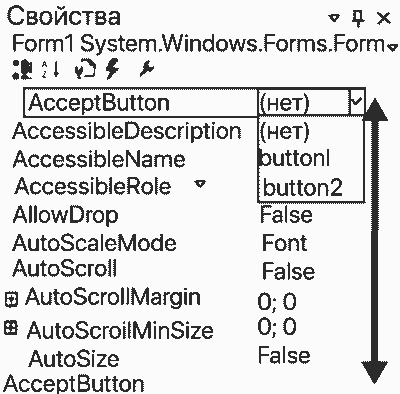

Рис. 23.6. Выбор кнопки для клавиши Enter.

Однако такой способ будет работать только в том случае, если в текущий момент на форме нет элемента управления, который перехватывает клавишу Enter и обрабатывает ее. Например, элемент управления многострочного текстового поля допускает нажатие клавиши Enter, если она выбрана для вставки нового строкового символа в элемент управления. Необходимо учитывать этот факт. Кроме клавиши Enter, с кнопкой Button можно связать и клавишу Esc. Что будет выполняться при нажатии клавиши Esc или соответствующей ей кнопки Button, решает разработчик. Например, можно очистить текстовое поле или выполнить закрытие формы. Свойство `CancelButton` может не работать, если другой элемент управления в форме перехватывает действие клавиши `Esc`. Например, если в форме открыто поле со списком `ComboBox`, нажатие клавиши `Esc` приведет к закрытию поля со списком `ComboBox`.

Страница 288

# КОГДА ПЕРВОЕ ОТОБРАЖАЕМОЕ ОКНО — ВСПОМОГАТЕЛЬНОЕ.

Как правило, главная форма приложения является основной формой, и в ней выполняется основная работа. Однако, если в начале работы программы требуется ввести в текстовые поля логин с паролем, то либо эти поля должны постоянно присутствовать на главной форме, либо в качестве главной формы надо использовать вспомогательное окно для ввода пароля. В последнем случае вспомогательная форма будет постоянно присутствовать на экране до конца работы программы. Ниже приведен альтернативный пример, когда главная форма, будучи не отображенной, вызывает в обработчике `Form1_Load` дочернее окно ввода пароля.

```
private void Form1__Load(object sender, EventArgs e)
{
    Form2 form2 = new Form2();
    form2.ShowDialoa():
    // Если пароль неправильный или не введен,
    // завершить работу.
    if (form2.password == false)
        Close();
}
```

В примере предполагается, что во второй форме по результатам ввода и анализа пароля формируется открытое поле `public bool password;`

Страница 289

Теряется эффектность, когда работа начинается с непрезентабельной вспомогательной формы. Поэтому можно принудительно отобразить главную форму и вывести на её фоне окно пароля, при этом все элементы управления главной формы можно сделать недоступными (хотя это и необязательно для модального диалога).

```
private void Form1_Load(object sender, EventArgs e)
{
    Enabled = false;
    // Все элементы недоступны.
    BackColor = SystemColors.ControlDark;
    Visible = true; // Отобразить родительскую форму.
    Form2 form2 = new Form2();
    form2.ShowDialog();
    // Если пароль неправильный или не введен,
    // завершить работу.
    if (form2.password == false)
    { Close(); }
    else
    {BackColor = SystemColors.Control;
    // Сделать элементы управления доступными.
    Enabled = true;
}
```

Страница 290

Вместо формирования поля `password` в диалоговой форме `form2` можно было воспользоваться формированием свойства формы `Form.DialogResult` и его анализом в родительской форме. Этот способ описан ниже, в подразделе «Использование возвращаемого значения».

# ПЕРЕДНИЙ И ЗАДНИЙ ПЛАНЫ.

Все элементы управления помещаются в контейнер формы, определяемый свойством `Form.Controls`. От порядка следования элементов зависит, какой из них будет на переднем плане, а какой — на заднем. Понятие «передний-задний план» имеет смысл для элементов, перекрывающих друг друга. Если элементы накладываются друг на друга, то, как правило, отображением одного из них управляют с помощью свойства `Visible`. Приведем следующий пример. Пусть для ввода в текстовое поле должен использоваться элемент управления `MonthCalendar` (календарь), который вызывается двойным щелчком текстового поля. Будем считать календарь вспомогательным элементом. По умолчанию календарь невидим (`monthCalendar1.Visible = false`), но в обработчике двойного щелчка текстового поля календарь будет отображен (`monthCalendar1.Visible = true`). Календарь занимает достаточно много места, поэтому чаще всего он перекрывает какие-либо элементы управления. Однако может случиться, что календарь отобразится на заднем плане, то есть его будут закрывать элементы управления. Возникает вопрос, как переместить календарь на передний план? Какой элемент управления будет на переднем плане, а какой на заднем, определяет последовательность добавления элементов в контейнер формы. Элемент, добавленный раньше, будет на переднем плане по сравнению с элементом, добавленным позже.

Страница 291

**Пример**. Разместить `textBox1` на передний план.

```
Controls.Add(textBox1);
Controls.Add(button1);
```

Разместить `button1` на передний план.

```
Controls.Add(button1);
Controls.Add(textBox1);
```

Элементы добавляются в контейнер формы во второй части класса `Formx`. Однако исправлять вторую часть формы не рекомендуется. Проще воспользоваться кнопками панели инструментов

Страница 292

**Пример**. Переместить календарь на передний план. `monthCalendar1.BringToFront()`; Еще одно замечание. Чтобы создать экземпляр какого-либо элемента управления вручную (без использования конструктора формы) и отобразить его, необходимо этот экземпляр перед его отображением добавить в контейнер формы или элемента управления.

**Пример**. В следующем фрагменте по щелчку кнопки отображается текстовое поле в элементе GroupBox.

```
TextBox tb = null;
public Form1()
{
    InitializeComponent();
    tb = new TextBox ();
    groupBox 1.Controls.Add(tb);
    tb.Visible = false;
}
private void button1_Click(object sender, EventArgs e)
{
    tb. Visible = true;
    tb.BringToFront();
    tb.Focus();
}
```

В приведённом примере не хватает настройки свойств текстового поля. Например, необходимо определить координаты левого верхнего угла текстового поля и его размер.

# РАСПОЛОЖЕНИЕ ФОРМЫ.

Свойство `StartPosition` возвращает или задает начальное положение окна на экране в режиме выполнения. Имеется возможность расположить форму в центре экрана или в центре ее родительской формы. Возможные значения свойства (константы перечисления `Form.StartPosition`):

- **Manual** - положение формы формы определяется свойством `Location`.
- **CenterScreen** — форма с заданными размерами располагается в центре текущего отображения.
- **WindowsDefaultLocation** - форма с заданными размерами размещается в расположении, определенном по умолчанию в `Windows` (значение по умолчанию). Как правило, каждая следующая форма размещается под заголовком предыдущей со сдвигом вправо.
- **WindowsDefaultBounds** - положение формы и ее границы определены в `Windows` по умолчанию. Форма может увеличить или уменьшить свой размер, так как по умолчанию он равен 300×300 точек.
- **CenterParent** - форма располагается в центре родительской формы.

Иногда необходимо получить размер окна, например, для того чтобы вычислить, не выйдет ли за границу динамически отображаемый элемент управления. Другая задача, которую приходится решать, — размещение формы в требуемом месте рабочего стола. Эту задачу можно решить с помощью свойства `Location` или следующего метода формы: `public void SetDesktopLocation(int x, int y)`, где х и у — координаты левого верхнего угла формы на рабочем столе. Свойство `Location` — возвращает или задает объект `Point`, который определяет верхний левый угол формы в экранных координатах.

Страница 293

**Пример**. Расположим дочернюю форму в координатах левого верхнего угла (100, 50) относительно левого верхнего угла родительской формы.

```
private void button1_Click(object sender, EventArgs e)
{
    Form2 f2 = new Form2();
    f2.StartPosition = FormStartPosition.Manual;
    f2.Location = new System.Drawing.Point(Location.X + 100, Location.Y + 50);
    f2.ShowDialog();
}
```

Свойство `StartPosition` может быть предварительно установлено в окне свойств.

Страница 294

# РАЗМЕРЫ ФОРМЫ.

При рисовании или размещении на форме каких-либо объектов часто бывает необходимо знать размеры формы и её частей. Форма сохраняет свои линейные размеры в свойствах. Ряд этих свойств перечислен ниже:

- **ClientRectangle** — получает прямоугольник, представляющий клиентскую область формы.
- **ClientSize** — возвращает или задает высоту и ширину клиентской области формы.
- **Size** — возвращает или задает высоту и ширину формы.
- **Bottom** — возвращает расстояние между нижним краем формы и верхним краем клиентской области контейнера. Значение данного свойства равно сумме значений свойств `Тор` и `Height`.
- **Bounds** — возвращает или задает размер и местоположение формы, включая не клиентские элементы. Местоположение определяется относительно клиентской области контейнера формы. Границы формы включают не клиентские элементы, такие как полосы прокрутки, границы, заголовки и меню. Метод `SetBoundsCore` вызывается для настройки свойства `Bounds`. Свойство `Bounds` не всегда удается изменить через метод `set`, поэтому следует переопределить метод `SetBoundsCore`, чтобы гарантировать выполнение кода в случае, если задано свойство `Bounds`.
- **Width** - возвращает или задает ширину формы.
- **Height** — возвращает или задает высоту формы.
- **Тор** - возвращает или задает координату по оси `Y` верхнего края формы (в точках).
- **Left** - возвращает или задает координату по оси `Х` левого края формы (в точках).
- **Right** — возвращает расстояние от правого края формы до левого края контейнера. Значение свойства `Right` равно сумме значений свойств `Left` и `Width`.

Поскольку многие из перечисленных свойств унаследованы от класса `Control`, то эти свойства доступны также и элементам управления. Свойство `ClientRectangle` возвращает прямоугольник, задающий клиентскую область (рабочую область) формы. Клиентская область формы располагается между границами формы, не включая в себя неклиентские элементы, такие как границы и головки окон. В клиентскую область формы входят полоски меню (`MenuStrip`), инструментов (`ToolStrip`), состояния (`StatusStrip`), полосы прокрутки (`VScrollBar`, `HScrollBar`) и т.д. Если форма имеет подзаголовочные полоски, то начало координат будет закрыто этими полосками.

Страница 295

**Пример**. Ниже приведен метод РабПоле, вычисляющий размер области, свободной для размещения объектов или рисовки. В методе осуществляется сдвиг начала координат в левый верхний угол этой области. Результат вычислений: ширинаПоля, высотаПоля.

```
int ширинаПоля, высотаПоля;
public void РабПоле(Control поле, params Control[] strips)
{
    ширинаПоля = поле.ClientRectangle. Width - 1;
    int высотаВсехStrip = 0;
    for (int i = 0; i < strips.Length; i++)
        высотаВсех += strips[i].Height;
    высотаПоля = поле.ClientRectangle. Height - высотаВсехStrip - 1;
    Graphics dc = поле.CreateGraphics();
    // Сдвинуть координаты.
    dc.TranslateTransform(0, высотаВсех);
}
```

Страница 296

Вызовем метод `РабПоле` для случая, когда под заголовком формы расположена одна строка меню и две панели инструментов: `РабПоле(this, menuStrip1, toolStrip1, toolStrip2);` В методе `РабПоле` параметр `this` определяет ссылку на форму. После этого параметра перечислены ссылки на полоску меню и две панели инструментов. Чтобы не учитывать элементы `MenuStrip`, `ToolStrip` и т.д., расположенные на форме, рекомендуется использовать для размещения объектов контейнеры, не содержащие этих полосок, например `Panel` или `GroupBox`. Их верхний левый угол по умолчанию имеет координаты (0;0). **В заключение следует описать** еще несколько полезных свойств. Свойство `SystemInformation.CaptionHeight` получает высоту (в точках) стандартной области заголовка окна. Класс `SystemInformation` предоставляет сведения о текущей системной среде. Свойства класса `SystemInformation`:

```
System.Windows.SystemParameters.PrimaryScreenWidth;
System.Windows.SystemParameters.PrimaryScreenHeight;
```

Эти свойства возвращают значения, указывающие (в точках) ширину и, соответственно, высоту экрана на основном мониторе. Для использования пространства имен `System.Windows` необходимо добавить в проект ссылку на сборку `PresentationFramework`.

# АВТОМАТИЧЕСКОЕ МАСШТАБИРОВАНИЕ ФОРМЫ.

Приложение может быть перенесено на другой компьютер, имеющий ряд параметров, не совпадающих с параметрами компьютера, на котором было разработано данное приложение. В том случае окна приложения могут выглядеть не так, как планировал разработчик. Однако класс `Form` может автоматически изменять свои размеры и свое содержимое в соответствии либо с текущим системным шрифтом, либо с разрешением экрана (в приках на дюйм). **Если разработчик установит** для формы `AutoScaleMode = None`, то окно не будет масштабироваться, и это приведет к тому, что на других компьютерах окно будет выглядеть либо слишком маленьким, либо слишком большим, а текстовые поля могут не вместиться (а в элементы управления. Например, если приложение разработано с использованием системного `шрифта Tahoma` размером 9 пунктов, то без коррекции окно будет выглядеть слишком маленьким на компьютере, на котором в качестве системного шрифта используется `шрифт Tahoma` размером 12 пунктов. Текстовые элементы, такие как заголовки, меню, содержимое текстовых полей и т.д., будут меньше, чем в других приложениях. **Аналогичная ситуация возникает**, когда приложение разработано для определенного экранного разрешения. Без коррекции окно приложения, особенно графическое, разработанное для одного разрешения, будет отображаться либо слишком большим, либо слишком маленьким при отображении на экране с другим разрешением. **Автоматическое масштабирование решает** эти проблемы путем автоматического изменения размеров формы и ее дочерних элементов управления согласно относительному размеру шрифтов и разрешению экрана. Для решения задач автоматического масштабирования используются следующие свойства: `AutoSizeMode`; `AutoSize`; `AutoScaleMode`. В современных средах `Visual Studio` по умолчанию устанавливаются следующие значения перечисленных свойств: `AutoScaleMode = Font`; `AutoSize = false`; `AutoSizeMode = GrowOnly`;

Страница 297

Страница 298

### Рассмотрим эти свойства.

Свойство `AutoScaleMode` получает или задает режим автоматического масштабирования формы. Значением свойства является одна из констант одноименного перечисления:

- **None** — автоматическое мясттабирование отключено.
- **Font** — масштаб элементов управления относительно размеров шрифта, используемого классами, который обычно является системным шрифтом.
- **Dpi** — масштаб элементов управления относительно разрешения дисплея. Обычно разрешение имеет значение 96 и 120 точек на дюйм.
- **Inherit** - масштаб элементов управления в соответствии с родительским режимом масштабирования классов. Если родительский объект отсутствует, автоматическое масштабирование отключено.

Масштабирование с использованием значения `Font` может оказаться полезным, если следует растянуть или сжать элемент управления или форму в соответствии с размером шрифтов операционной системы. Это масштабирование должно использоваться, если абсолютный размер элемента управления или формы не имеет значения. В большинстве бизнес-приложений должен использоваться режим автоматического масштабирования `Font`. Масштабирование с использованием Dрі полезно, если следует задать размер элемента управления или формы относительно экрана. Например, можно использовать масштабирование в точках на дюйм элемента управления, отображающего диаграмму или другой график, чтобы он занимал определенное процентное соотношение экрана. Режим масштабирования Dpi полезен для графических приложений.

Свойство `AutoSizeMode` возвращает или задает режим, с помощью которого форма или элемент управления может автоматически изменять свои размеры. Режим определяется одноименным перечислением, имеющим следующие значения:

- **GrowAndShrink** — размеры элемента управления увеличиваются или уменьшаются по размеру его содержимого. Размеры элемента управления невозможно изменять вручную.
- **GrowOnly** - размеры элемента управления могут изменяться в соответствие с его содержимым, однако они не уменьшаются до значения, меньшего заданного свойством Size. Размеры формы можно изменять, но их нельзя сделать настолько малыми, что какие-либо содержащиеся в ней элементы управления становятся скрытыми.

Страница 299

По умолчанию используется значение `GrowOnly`. Установка значения `GrowAndShrink` приводит к тому же поведению, которое имеет место для элементов управления с разрешенным свойством `AutoSize`, однако не имеющим свойства `AutoSizeMode`. Свойства `MinimumSize` и `MaximumSize` выполняются, но текущее значение свойства `Size` игнорируется. Свойство `AutoSize` изменяет размеры формы во время выполнения в соответствии со значением `AutoSizeMode`. Значение true задает автоматическое изменение размеров формы; `false` — размеры формы необходимо изменять вручную. По умолчанию `AutoSize=false`. Используйте `AutoSize=true`, чтобы принудительно изменить размеры формы для вмещения всего содержимого. Пример.

```
this.AutoSize = true;
this.AutoSizeMode = AutoSizeMode.GrowAndShrink;
```

Форма по-разному реагирует на значения свойств `AutoSizeMode` и `AutoSize` во время визуального проектирования и во время выполнения приложения. Форма не меняет размеры автоматически в конструкторе форм `Visual Studio` при установке значений указанных свойств. Однако во время выполнения форма правильно изменяет собственные размеры, основываясь на значениях свойств `AutoSizeMode` и `AutoSize`.

Страница 300

Свойство `AutoSize` имеет не только форма, но и ряд элементов управления, например `Button`. Это свойство получает или задает значение, указывающее, основано ли изменение размеров элемента управления на его содержимом. Значение `true` определяет автоматическое изменение размеров элемента управления в зависимости от его содержимого; в обратном случае — значение `false`. **В отличие от формы** элементы управления автоматически изменяют свои размеры как во время визуальной разработки, так и во время выполнения. **При использовании** `AutoSize` свойства `MinimumSize` и `MaximumSize` формы и элементов управления выполняются, но текущее значение свойства `Size` игнорируется.

Страница 301

# 24. ВЗАИМОДЕЙСТВИЕ ФОРМ ПРИЛОЖЕНИЯ.

Под взаимодействием форм понимается их взаимодействие по управлению и данным. Взаимодействие по управлению предполагает создание и отображение форм в соответствии со сформированными условиями. Взаимодействие по данным — это обмен данными между формами приложения. **Разработчик может создать приложение**, состоящее из нескольких главных форм, последовательно запускаемых в методе `Main`. Однако наиболее часто разработчики реализуют приложения, состоящие из одной главной формы и нескольких дочерних. Каждая из дочерних форм также может стать родительской, если создаст новую форму.

# 24.1. Взаимодействие родительской и дочерней форм.

Особенностью взаимодействия родительской и дочерней форм является создание в родительской форме дочерней и передача ей управления. Выполнение родительской формы приостанавливается (режим `SDI`). После закрытия дочерней формы управление возвращается назад. На рис. 24.1 приведен пример, в котором форма `Form1` является родительской по отношению ко всем остальным формам, а форма `Form3` — дочерней по отношению к форме `Form1` и родительской по отношению к форме `Form4`. Начинающие программисты наделяют форму какими-то магическими особенностями, хотя с точки зрения объектно-ориентированного программирования форма — это обычный объект. Таким образом, взаимодействие форм — это взаимодействие объектов.

Страница 302

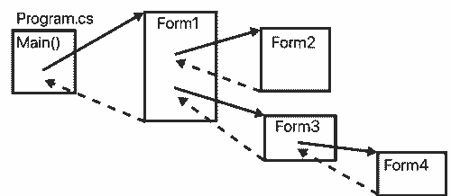

Рис. 24.1. Родительские и дочерние формы.

Возможно несколько способов организации взаимодействия форм как объектов. Перечислим основные из них:

1. взаимодействие с использованием открытых объектных членов;
2. взаимодействие с использованием открытых статических членов; Такие члены выступают в роли глобальных данных для всей программы.
3. взаимодействие с использованием возвращаемого формой Значения.

# ИСПОЛЬЗОВАНИЕ ОБЪЕКТНЫХ ЧЛЕНОВ.

Поскольку родительская форма создает дочернюю, то в распоряжении родительской формы, естественно, есть ссылка на дочернюю. Через эту ссылку, пока она не вышла из области видимости, родительская форма имеет доступ ко всем открытым нестатическим (объектным) членам дочерней формы. **Рассмотрим взаимодействие на примере**. Пусть в дочерней форме определены два открытых поля:

```
public string title;
public bool closeFlag;
```

Тогда родительская форма может до запуска дочерней передать ей значение для `title` и после закрытия дочерней формы получить значение поля `closeFlag`. Во фрагменте родительской формы, приведенном ниже, показано, как это можно сделать. В примере родительская форма закрывается, если в дочерней возникла непреодолимая ошибка.

Страница 303

Родительская форма:

```
// Создание дочерней формы.
Form2 form2 = new Form2();
// До запуска form2.
form2.title = "Финансовый университет";
// Передача управления дочерней форме form2.
form2.ShowDialoa():
// Сюда возвращается управление из дочерней формы.
// Здесь можно получить данные из дочерней формы.
if (form2.closeFlag) Close();
```

Чтобы дочерняя форма имела доступ к открытым нестатическим членам родительской формы, дочерняя форма должна получить ссылку на родительскую. Самый простой способ решения этой задачи — передать ей эту ссылку так, как это продемонстрировано в следующем примере. Перенесем открытое поле `closeFlag` из дочерней формы в родительскую. Определим в дочерней открытое поле `form1` типа `Form1`. Родительская форма:

```
public bool closeFlag;
// Создание дочерней формы.
Form2 form2 = new Form2();
// Конструктор получает управление.
// Передаем ссылку на себя в form2.
form2.form1 = this;
form2.ShowDialog(); // Отображаем form2.
```

Страница 304

Дочерняя форма:

```
public Form1 form1;
//......
// Использовать поле из родительской формы.
form1.closeFlag = true;
```

Дочерняя форма получает доступ к открытому полю `closeFlag` родительской формы, используя ссылку `form1`. Нельзя использовать ссылку на родительскую форму в конструкторе дочерней формы. Связано это с тем, что конструктор дочерней формы получает управление при создании экземпляра формы, а ссылка передается позже. Поэтому в конструкторе дочерней формы `form1 = null`. **В предыдущем примере** `form2` является локальной переменной обработчика события (метода), и эта переменная будет уничтожена после выхода из обработчика. Если открытые поля и свойства дочерней формы должны быть доступны в разных местах родительской формы, то рекомендуется объявление ссылки на дочернюю форму вынести на уровень полей класса, тогда дочерняя форма не будет уничтожена сборщиком мусора при выходе из обработчика события, создавшего дочернюю форму.

Например, родительская форма:

```
public Form2 form2;
// Объявление поля.
//...........
// Создание дочерней формы.
form2 = new Form2();
// Конструктор получает управление.
//...............
```

Использование метода `Application.OpenForms`. Ссылку необязательно передавать в дочернюю форму, ее можно получить, используя класс `Application`. Статическое свойство `OpenForms` этого класса возвращает коллекцию открытых форм, из которой можно выбрать ссылку на требуемую форму: `Form1 form1 = (Form1)Application.OpenForms["Form1"];`

Страница 305

# ИСПОЛЬЗОВАНИЕ СТАТИЧЕСКИХ ЧЛЕНОВ.

Использование открытых статических членов упрощает задачу взаимодействия, так как ссылка на форму не требуется. Рассмотрим следующий пример: пусть в родительской форме `Form1` определено статическое поле `title`, а в дочерней форме `Form2` — статическое поле `closeFlag`. Ниже показано, как формы могут использовать эти поля.

```
// Родительская форма:
public static string title = "Финансовый университет";
//..................
// Создание дочерней формы.
Form2 form2 = new Form2();
form2.ShowDialog();
// Здесь можно получить данные из дочерней формы.
if (Form2.closeFlag)
    Close();

//Дочерняя форма:
public static bool closeFlag;
//.............
textBox1.Text = Form1.title;
closeFlag = true;
//.............
```

Страница 306

Конечно, это не все способы передачи данных. Сколько существует способов взаимодействия родительского и дочернего объекта, столько существует способов взаимодействия родительской и дочерней форм. Создание и отображение дочерней формы не обязательно программировать в коде родительской формы. Для упрощения этого процесса можно использовать открытый статический метод дочерней формы. Этот метод может использоваться как для создания объекта формы, так и для её отображения. Например, для вывода стандартного окна сообщения не требуется явное создание объекта, вместо этого вызывается статический метод `Show`: `MessageBox.Show(...);` Если Вас, например, не устраивает системный класс `MessageBox`, то Вы можете реализовать собственный.

**Пример**. Ниже фрагментарно показан код пользовательского класса `MyMessageBox`, который отображает окно, представленное на рис. 24.2. Особенность этого окна состоит в том, что разрешить продолжение работы студенту (кнопка «Да») может только преподаватель, знающий пароль. Это позволяет преподавателю ознакомиться с выведенным сообщением о нарушении безопасности.

Форма. Заголовок форма нарушена безопасность.

Несанкционированное подключение к сети

Студент незаконно подключился к вычислительной сети после получения экзаменационного билета.

Рекомендации Первая. Отключить компьютер сети. Второе. Выставить неудовлетворительную оценку или выдать на билет.

Разрешить студенту продолжить работу? Да нет

Введите пароль

Текст бокс для ввода пароля

Кнопка окей.

Рис. 24.2. Пример диалогового окна `MyMessageBox`

Вызов этого окна осуществляется в родительской форме слеДующим образом:

```
MyMessageBox.Show(
    "Несанкционированное подключение к сети!"
    + "\n\n Студент незаконно подключился к вычислительной"
    + "сети после получения экзаменационного билета."
    + "\n\n РЕКОМЕНДАЦИИ:"
    + '\n 1. Отключить компьютер от сети,"
    + "\n 2. Выставить неудовлетворительную оценку"
    + "\n -или- "
    + "\n выдать новый билет.", "001"
);
```

Как видите, формат вызова отличается от стандартного только приставкой `Му`.

Страница 307

Код класса MyMessageBox:

```
public partial class MyMessageBox: Form
{
    public MyMessageBox()
    { InitializeComponent; }
    static MyMessageBox msb;
    string pswd = = "123" ;
    public static void Show (string s1, string s2, int f = 0)
    {
        msb = new MyMessageBox();
        msb.label5.Text = s2;
        msb.textBox1.Text = "\r\n\r\n" + s1.Replace("\n", "\r\n");
        msb.textBox1.SelectionStart = 0;
        msb.ShowDialog();
    }
    private void a_Click(object sender, EventArgs e)
    {
        msb.panel2.Visible = true;
        msb.textBox3.Focus();
    }
```

Страница 308

```
    private void Het_Click(object sender, EventArgs e)
    {
        Formi.close = true; // Закрываем программу.
        msb.Close();
    }
    private void Ok_Click(object sender, EventArgs e)
    {
        if (textBox3.Text!= pswd)
        {
            msb.label6.Text = "Неправильный пароль! Повторите.";
            msb.textBox3.Focus();
            return;
        }
        // Пароль принят!
        Form1.close = false;
        msb.Close();
         // Продолжаем работу.
    }
}
```

По щелчку кнопки «Да» отображается ранее скрытая панель с элементами управления для ввода пароля. В родительской форме `Form1` определено статическое поле `close`, через которое возвращается признак завершения окна. Для того чтобы получить доступ к элементу управления, принесите его свойству Modifiers значение Public.

Страница 309

# ИСПОЛЬЗОВАНИЕ ВОЗВРАЩАЕМОГО ЗНАЧЕНИЯ.

Метод `ShowDialog`, отображающий дочернее окно, может возвратить значение, показывающее, как завершилось это окно. Результат диалога для формы возвращается или задается свойством `Form.DialogResult`. (В окне свойств `Visual Studio` это свойство не отображается.) Свойство `Form.DialogResult` может получить одно из следующих значений перечисления `DialogResult`:

- **None** — из диалогового окна возвращается значение `Nothing`. Это означает, что модальное диалоговое окно продолжает свою работу.
- **ОК** — из диалогового окна возвращается значение `ОК` (обычно это значение отправляется кнопкой с надписью «`ОК`»).
- **Cancel** — из диалогового окна возвращается значение `Cancel` (обычно это значение отправляется кнопкой с надписью «`Cancel`»).
- **Abort** — из диалогового окна возвращается значение `Abort` (обычно это значение отправляется кнопкой с надписью «`Abort`»).
- **Retry** — из диалогового окна возвращается значение `Retry` (обычно это значение отправляется кнопкой с надписью «`Retry`»).
- **Ignore** — из диалогового окна возвращается значение `Ignore` (обычно это значение отправляется кнопкой «`Ignore`»).
- **Yes** — из диалогового окна возвращается значение `Yes` (обычно это значение отправляется кнопкой с надписью «`Yes`»).
- **No** — из диалогового окна возвращается значение `No` (обычно это значение отправляется кнопкой с надписью «`No`»).

Если форма отображается в виде диалогового окна, установка свойства `Form.DialogResult` со значением из перечисления `DialogResult` (любым, кроме `None`) устанавливает значение результата диалогового окна для формы, скрывает модальное диалоговое окно и возвращает дочернюю форму вызывающей форме (родительской). **Свойство `Form.DialogResult`** для возврата значения из диалоговой формы может быть установлено программистом в обработчике события. Это свойство нельзя устанавливать в конструкторе формы, поэтому `DialogResult` отсутствует в окне свойств формы.

Страница 310

Кроме разработчика, свойство `Form.DialogResult` также устанавливается автоматически кнопкой `Button`, для которой установлено свойство `Button.DialogResult`. Значение свойства `Button.DialogResult` присваивается свойству `Form.DialogResult`, поэтому свойство `Button.DialogResult` имеет такой же тип, как и `Form.DialogResult`. Как видите, `DialogResult` — это свойство формы, свойство кнопки и перечисление (не путайтесь). **Разработчик должен выбрать**, какие кнопки диалоговой формы и какое значение типа `DialogResult` они должны возвращать. Далее разработчик должен войти в окно свойств кнопки и присвоить свойству `DialogResult` выбранное из списка значение. На рис. 24.3, слева, показан пример диалогового окна с двумя кнопками. Каждая из этих кнопок является финишной, то есть закрывающей окно. На рис. 24.3, справа, показано, как для свойства `DialogResult` кнопки выбирается значение `DialogResult.Yes`.

Form2 _OX

ВЫ ПРИНИМАЕТЕ НАШИ ТРЕБОВАНИЯ? ДА НЕТ.

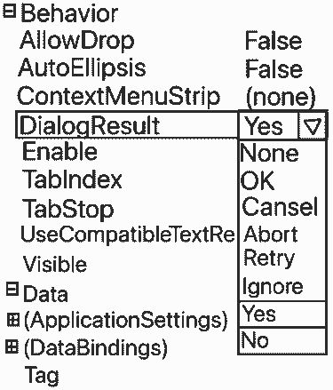

Рис. 24.3. Пример диалогового окна и значения свойства `DialogResult`

Когда пользователь нажимает кнопку `Button`, для которой определено свойство `DialogResult` со значением, отличным от `None`, это значение присваивается свойству формы `DialogResult`. Далее управление получает обработчик события кнопки, если он есть. Если определены обработчики событий `FormClosing` и `FormClosed`, то они также получают управление. После этого модальное диалоговое окно скрывается, но не уничтожается, и управление возвращается родительской форме. **Скрытая форма может** быть отображена снова, при этом не требуется в родительской форме создавать новый экземпляр диалогового окна. Из-за этого поведения необходимо вызвать метод формы `Dispose`, если форма уже не нужна приложению. **Если свойство `Form.DialogResult`** не установлено или окно закрывается системной кнопкой закрытия «X» или или свойством `Visible = false`, всегда возвращается значение `DialogResult.Cancel`. Обработчик события `FormClosing` может изменить это значение или отменить закрытие формы. **Метод `ShowDialog`** возвращает результат также в виде перечисления `DialogResult`, имеющего показанные на рис. 24.3 значения. **Если Вы собираетесь вручную установить** для кнопки свойство `DialogResult`, то этого не надо делать в обработчике этой кнопки. Лучше воспользуйтесь обработчиком `Formx_Load`.

Страница 311

Часто кнопки, возвращающие значение, связывают со свойствами формы `AcceptButton` и `CancelButton`. Рассматриваемый способ хорош для диалоговых окон с кнопками, завершающими работу формы (см. рис. 24.3, слева). Примером такого окна является окно сообщения `MessageBox`. Достоинством этого способа также является то, что для диалоговой кнопки не требуется обработчик события, и не требуется формирование данных о том, как завершается форма. Тем не менее, если у кнопки есть обработчик события, то он выполняется. **Следует иметь в виду**: как бы Вы не организовали выход из обработчика кнопки, окно все равно исчезнет с экрана. Это можно отменить, выполнив в обработчике кнопки оператор `DialogResult = DialogResult.None;` или отменив закрытие окна в обработчике события `FormClosing`:

```
closeFlag = false;
private void Form2_FormClosing(object sender, FormClosingEventArgs e)
{ e. Cancel = closeFlag; }
```

Страница 312

**Пример**. Получение информации о завершении работы дочерней формы.

```
private void button1_Click(object sender, EventArgs e)
{
    Form2 dialog = new Form2();
    DialogResult result = aiaiog.ShowDialog();
    // Здесь доступны открытые поля и своиства формы dialog.
    switch (result)
    {
        case DialogResult.Yes:
            MessageBox.Show("Выбрано ДА");
            break;
        case DialogResult.No:
            MessageBox.Show("Выбрано HET");
            break;
        dialog.Dispose();
    }
}
```

В простых случаях использование свойства `Button.DialogResult` избавляет разработчика от написания дополнительного кода. Однако есть ситуации, когда требуется управлять выходом из обработчика кнопки. Для таких ситуаций лучше не использовать свойство `Button.DialogResult` и ограничиться использованием свойства `Form.DialogResult`,

Страница 313

**Пример**. В окне (см. рис. 24,4) запрашивается пароль, и если введен правильный, то осуществляется закрытие окна, иначе запрашивается повторный ввод пароля. Если пароль пользователю неизвестен, то он может закрыть форму системной кнопкой закрытия `Х`. **В родительской форме**:

```
private void button1_Click(object sender, EventArgs e)
{
    Form2 form2 = new Form2();
    // Если пароль неправильный или не введен,
    // завершить работу.
    if (form2.ShowDialog() != DialogResult.OK)
    Close();
｝
```

В диалоговой форме:

```
private void buttonOK_Click(object sender, EventArgs e)
{
    if (textbox. Text == "123")
    {
        // Скрыть форму и возвратить ОК.
        DialogResult = DialogResult.OK;
    }
    else
    {
        MessageBox.Show("Введен неверный пароль, повторите ввод.");
        // Повторить ввод
        return; //Этот оператор можно опустить.
    }
}
```

Страница 314

Form1 _OX

ВВЕДИТЕ ПАРОЛЬ: ОКНО ДЛЯ ВВОДА ПАРОЛЯ. КНОПКА ОК.

Рис. 24.4. Форма с вводом пароля

В приведённом выше примере предполагается, что пароль = 123. Если пользователь нажмёт системную кнопку закрытия окна, то будет возвращён результат `DialogResult.Cancel`.

# 24.2. Управление формами в Main

В методе `Main` можно создать несколько независимых форм. Все формы являются главными формами приложения, поэтому каждая следующая форма создается только после закрытия предыдущей (см. рис. 24.5). Пока метод `Main` не завершится и ссылка не выйдет из зоны видимости, имя формы будет оставаться на панели задач. Чтобы убрать это имя, необходимо получить ссылку и присвоить ей значение `null`.

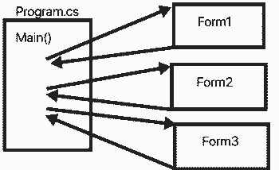

Рис. 24.5. Последовательное выполнение трех форм.

**Пример**. Метод `Main` запускает первую форму, а после ее завершения — вторую.

```
static class Program
{
    [STAThread]
    static void Main()
    {
        Application.EnableVisualStyles();
        Application.SetCompatibleTextRenderingDefault(false);
        Form1 frm1 = new Form1();
        Application.Run(frm1); // Сделать главной форму 1.
        frm1 = null; // Уничтожить форму 1.
        Application.Run(new Form2()); // Сделать главной форму 2.
    }
}
```

Такие формы могут взаимодействовать друг с другом на уровне полей класса, содержащего метод `Main`. Если вторая форма должна запускаться при условии, формируемом первой формой, то это условие можно проанализировать в методе `Main`.

Страница 315

**Пример**. Определим в классе `Program` статическое поле `startForm2`. Если первая форма установит `startForm2 = true`, то вторая форма будет запущена на выполнение. Такой способ подходит, когда, например, в первой форме вводится пароль (см. рис. 24.4) и от его значения зависит выполнение второй формы.

```
//Класс Program:
static class Program
{
    public static bool startForm2 = true;
    [STAThread]
    static void Main()
    {
        Application.EnableVisualStyles();
        Application.SetCompatibleTextRenderingDefault(false);
        Form1 frm1 = new Formi();
        Application.Run(frm1); // Запустить главную форму 1.
        frm1 = null; // Уничтожить форму 1.
        if (startForm2 == true)
        {
            // Запустить главную форму 2.
            Application.Run(new Form20);
        }
    }
}
```

Страница 316

Код первой формы (см. рис. 24.4):

```
public partial class Form1 : Form
{
    public Form1()
    {
        InitializeComponent();
    }
private void button1_Click(object sender, EventArgs e)
{
    if (textBox1. Text == "123")
    { Program.startForm2 = true; }
    else { Program.startForm2 = false; }
    Close;
}
```

В примере поле `startForm2` является статическим. Однако можно организовать взаимодействие форм и с использованием ссылки типа `Form1` для доступа к открытым полям первой формы. Текст второй формы не показан, так как для демонстрации взаимодействия форм он не нужен.

Страница 317

# 24.3. Задания для самостоятельной работы.

**Задача 1**. Создать приложение с двумя формами. Реализовать последовательный запуск этих форм в методе Main (файл Program.cs).

- Вариант 1. Форма 2 запускается без каких-либо условий.
- Вариант 2. Форма 2 запускается, если форма 1 установит флаг в значение true. **Задача 2**. Создать приложение с кнопкой `Button` для вывода сообщения и тремя переключателями типа `RadioButton`. Переключатели должны определять формат диалогового окна `MessageBox`: **Во-первых**, только сообщение; **Во-вторых**, сообщение и заголовок; **В-третьих**, сообщение, заголовок, кнопки Yes, No и Cancel и значок «Ошибка». В последнем случае проанализировать, какой кнопкой был закрыт диалог. Вывести информацию о нажатой кнопке диалога в надпись `Label`. **Задача 3**. Разработать приложение, в котором в дочерней форме отобразить содержимое текстового поля родительской, а в родительской - содержимое текстового поля дочерней формы.
- Вариант 1. С использованием ссылки на родительскую форму.
- Вариант 2. С использованием статических текстовых полей.

Страница 318

**Задача 4**. Разработать приложение со списком `ListBox` и двумя кнопками. В окне свойств заполнить список произвольными данными. По первой кнопке отобразить форму для добавления в список нового значения. Создать для добавления строки соответствующий программный код. По второй кнопке удалить выбранную строку.

**Задача 5**. Разработать приложение для учета студентов и выполнения операций по добавлению новых студентов, удалению и изменению выбранных. **Приложение должно содержать три формы**: главную и две дочерние. Создать класс Студент с полями: фамилия, номер курса, группа, телефон. Для хранения списка студентов использовать `List<Student>`. Список студентов отображать в главной форме в элементе управления `ListBox` в табличном виде. Применить привязку списка `ListBox` к строкам, возвращаемым методом `ToString` класса `Student`. **Для добавления** в список нового студента использовать кнопку `Button` с текстом «Добавить». По этой кнопке отобразить дочернее окно. В дочернее окно для создания нового объекта добавить необходимые элементы типа `Label`, `TextBox`, `MaskedTextBox` и `Button`. **Для изменения** выбранного студента предусмотреть кнопку «Изменить» и дочернюю форму, создаваемую по этой кнопке. Для удаления выбранного студента использовать кнопку «Удалить».

Страница 319

# 25. НЕМОДАЛЬНЫЕ ОКНА.

Выше было сказано, что окно называется немодальным (нережимным), если оно отображается методом `Show`, который не блокирует родительскую форму. Это означает следующее: **Во-первых**. Управление в родительской форме после создания немодальной формы немедленно передается на следующий оператор после Show. **Во-вторых**. Родительская форма продолжает получать сообщения. **В-третьих**. Родительская форма не получает никакого уведомления о том, что дочерняя форма закрылась. **В-четвертых**. С немодального окна, имеющего фокус ввода (активное окно), можно переключиться на родительское окно и на другое немодальное окно. С родительского окна можно переключиться на немодальное дочернее окно. Модальное окно, как известно, не позволяет переключаться ни на какие другие окна своего приложения. **В-пятых**. Если закрывается родительское окно, то закрываются и все его немодальные дочерние окна. Параллельное выполнение родительского и дочерних немодальных окон делает программу сложнее.

Страница 320

**Пример**. Отобразить форму в немодальном режиме методом Show.

```
Form2 form2 = new Form2();
form2.Show();
```

Немодальное окно можно также создать простым отображением формы с помощью свойства `Visible=true`. Скрыть немодальное окно можно или свойством `Visible=false`, или эквивалентным ему методом `Hide()`.

**Пример**. Отобразить форму в режиме немодального окна с помощью свойства `Visible`.

```
Form2 form2 = new Form2();
form2.Visible = true;
```

Рассмотрим, в каких случаях может потребоваться создание немодального окна. Во-первых, для реализации интерфейса `MDI`, основанного на немодальных окнах. Во-вторых, в рамках `SDI`-приложения иногда полезно отдельное окно сделать немодальным. Например, инструкцию о программе, представленную отдельной формой, можно отобразить в немодальном окне, и это позволит продолжить работу программы, а инструкцию всегда держать на экране.

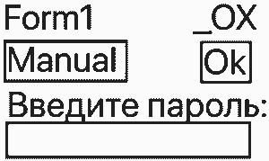

Рис. 25.1. Главное окно перед созданием немодального окна.

**Пример**. Ниже приведена программа и её главное окно (см. рис. 25.1), в котором по кнопке `Manual` отображается немодальное окно с инструкцией. Для запрещения создания других форм-дубликатов, кроме первой, после создания немодального окна кнопку `Manual` можно сделать неактивной. Когда окно с инструкцией закрывается, кнопку можно разблокировать. С немодального окна можно переключиться на родительское окно и продолжить работу, например ввести пароль (см. рис. 25.2). С родительского окна можно переключиться на немодальное. После закрытия немодального окна кнопка Manual становится снова доступной для работы.

Страница 321

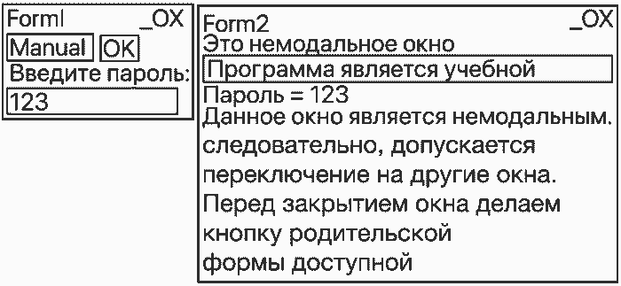

Рис. 25.2. Главное окно и дочернее немодальное окно.

Ниже представлен текст программы, реализующей описанный выше сценарий. Текст родительской формы:

```
using System;
usina Svstem.Windows.Forms;
namespace Немодальное1
{
    public partial class Form1 : Form
    {
        public Form1() { InitializeComponento; }
        private void button1_Click(object sender, EventArgs e)
        {
            Form2 form2 = new Form2();
            button1.Enabled = false;
            form2.Show();
        }
        private void button2_Click_1 (object sender, EventArgs e)
        {
            if (textBox1.Text == "123") { Close();}
            else { label1.Text = "Пароль неверный!"; }
        }
    }
}
```

Страница 322

Текст дочерней формы:

```
using System;
using System.Windows.Forms;
namespace Немодальное 1
{
    public partial class Form2 : Form
    {
        Public Form2() { InitializeComponent; }
        private void Form2_FormClosing(object sender, FormClosingEventArgs e)
        {
            Form1 f1 = (Form1)Application.OpenForms["Form1"];
            f1.button1.Enabled = true;
        }
    }
}
```

Страница 323

Если Вы хотите, чтобы после появления немодального окна родительская форма снова стала активной, вставьте после строки `form2.Show();` оператор `this.Activate();` **Для организации доступа** дочерней формы к кнопке родительской формы используется статическое свойство `OpenForms` класса `Application` (см. обработчик `Form2_FormClosing`). Это свойство возвращает коллекцию открытых форм, из которой можно выбрать ссылку на требуемую. **По умолчанию все элементы** управления создаются с модификатором `private`. Чтобы ссылка на кнопку `Manual` была видна в другой форме, в окне свойств кнопки был установлен уровень видимости `Modifiers=public`.

**Примечание**. В реальных программах вместо кнопки `Manual` лучше использовать пункт меню. Следует отметить, что после создания какого-либо модального окна, с него не удастся переключиться на немодальное. Однако немодальное окно, перекрытое модальным, можно сделать видимым, переместив в сторону модальное окно. Если этого сделать не удается, то можно свернуть все окна приложения на панель задач, а затем распахнуть немодальное окно.

Страница 324

Для запрещения создания других форм-дубликатов управлять доступностью или видимостью можно не только отдельного элемента управления, но и всей родительской формы. Для скрытия формы, отображенной в виде немодального окна, можно использовать метод `Hide`. Скрытие элемента управления или формы эквивалентно заданию для свойства `Visible` значения `false`. После вызова метода `Hide` свойство `Visible` возвращает значение `false` до тех пор, пока не будет вызван метод `Show`. После закрытия формы немодального окна методом `Close` свойство `DialogResult` может не вернуть значение, назначенное форме, поскольку ресурсы формы автоматически освобождаются, когда форма закрывается.

Страница 325

# 26. ПРИЛОЖЕНИЯ С ИНТЕРФЕЙСОМ MDI.

# 26.1. Общие сведения.

Немодальная форма — это еще не `MDI-форма`. `MDI-приложения` позволяют отображать сразу несколько документов одновременно, каждый в своем окне. Такие окна являются окнами немодальных диалогов. Это означает, что пользователь может переключаться с одного немодального окна на другое, то есть с одного документа на другой, не закрывая окна. **В `MDI`-приложении** родительская форма должна выступать в роли контейнера для дочерних `MDI-форм`. Для этого необходимо у родительской формы установить свойство `isMdiContainer` в значение `true`. **Как правило**, у родительской формы разработчики создают меню «Окно», в который для каждого открываемого `MDI-окна` будет автоматически добавляться подпункт для перехода к этому окну, когда оно не имеет фокус. Таким образом, меню «Окно» будет содержать список всех открытых `MDI-окон`. **Новая `MDI-форма`** добавляется в проект как обычная форма. Для `MDI-приложения`, как правило, конструируется только одна форма, на основе которой создается несколько дочерних окон — по одной для каждого документа. **Если модальное `SDI-окно`** создается методом `ShowDialog`, то немодальное `MDI-окно` создается методом `Show`. Чаще всего элементом управления, в обработчике которого создают `MDI-окно`, является пункт меню.

Страница 326

**Пример**. Создание дочернего `MDI`-окна по команде меню с именем `menuNew`.

```
private void menuNew_Click(object sender, EventArgs e)
{
    Form2 wnd = new Form2();
    wnd.MdiParent = this;
    wnd.Show();
}
```

Немодальное окно может отображаться либо в границах родительского окна, либо произвольным образом. Для того чтобы дочернее немодальное окно отображалось в границах родительского окна, необходимо у дочернего окна установить свойство `MdiParent`, равным ссылке на родительскую форму. Это свойство отсутствует в окне свойств `Visual Studio`. Если дочернее окно выходит за рамки родительского, то выходящая часть не отображается, а для просмотра дочернего окна в родительском создаются полосы прокрутки. По этой причине рекомендуется родительское окно распахивать на весь экран (`WindowState = Maximized`). Если родительская форма не определена как контейнер (`IsMdiContainer = false`), то свойство `MdiParent` использовать нельзя. Дочерние `MDI-окна` не закрывают родительские элементы управления, располагаясь под ними, поэтому эти элементы управления всегда доступны и поэтому в родительском окне рекомендуется использовать только меню, панель инструментов и строку состояния. Итак, основным признаком `MDI-формы` является установка её свойства `MdiParent`, равным ссылке на родительскую форму, которая определяется как `MDI-контейнер` (`IsMdiContainer = true`).

Страница 327

# 26.2. Использование меню в `MDI-формах`

Кроме использования родительской формы в качестве контейнера дочерних MDI-форм, для создания MDI-приложения пункты меню родительской формы используются специальным образом. Один пункт может использоваться для создания очередного `MDI-окна`, а другой — для переключения между ними (пункт «Окно»). Как создавать `MDI-форму`, было описано ранее, поэтому основной интерес представляет второй пункт меню. Особенностью такого пункта является автоматическое формирование списка дочерних `MDI-форм`. Чтобы какой-либо пункт меню стал выполнять такую функцию, необходимо свойству `MdiWindowListItem` элемента управления `MenuStrip` присвоить ссылку на этот пункт.

**Пример**. Ниже показано использование свойства `MdiWindowListItem`. Предполагается, что полоска меню имеет ссылку `menuStrip1`, а пункт меню, который должен отображать список, — `windowMenu`. `menuStrip1.MdiWindowListItem = windowMenu;`. Следует заметить, что если дочерняя `MDI-форма` имеет свое меню, то оно копируется в меню родительской формы.

Страница 328

# 26.3. Пример разработки `MDI-приложения` СОЗДАНИЕ РОДИТЕЛЬСКОЙ `MDI-ФОРМЫ`.

Основой приложения с `MDI-интерфейсом` является родительская `MDI-форма`. Эта форма создает дочерние `MDI-окна`, добавляя их в свой контейнер. Создадим родительскую MDI-форму в конструкторе Windows Forms: **во-первых**, создайте проект Windows Forms и выделите форму; **во-вторых**, в окне «Свойства» родительской формы установите свойству `IsMDIContainer` значение `true`. При этом форма назначается `MDI-контейнером` для дочерних окон; **в-третьих**, установите в окне «Свойства» для свойства `WindowState` значение `Maximized`, поскольку легче всего управлять дочерним `MDI-окном`, когда родительская форма развернута; **в-четвёртых**, из панели элементов перетащите элемент управления `MenuStrip` на форму. Создайте пункт меню «Файл» с подпунктами «Создать» и «Закрыть» (см. рис. 26.1). Создайте также пункт меню «Окно». По умолчанию этот пункт будет создан с именем `окноТоо/StripMenultem`. Родительское MDI-окно создано (см. рис. 26.1).

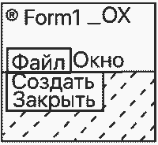

Рис. 26.1. Родительское MDI-окно.

# СОЗДАНИЕ ДОЧЕРНЕЙ МDІ-ФОРМЫ.

Посредством следующей процедуры создадим дочернюю `MDI-форму`, отображающую элемент управления `RichTextBox`. Этот элемент управления обладает функциями редактора, похожими на функции `MS Word`. **Выполните следующие действия**:

- **Во первых**. Определите пункт меню, который будет использоваться для отображения списка дочерних `MDI-окон`. Для этого в окне «Свойства» компонента `MenuStrip` родительской формы задайте свойству `MdiWindowListItem` значение `окноТооlStripMenuItem`. Это позволит меню «Окно» поддерживать список открытых дочерних `MDI-окон` с галочкой рядом с активным дочерним окном. **Примечание**. В старых средах `Visual Studio` выберите пункт меню «Окно» и в окне «Свойства» задайте свойству `MdiList` значение `true`.
- **Во вторых**. Добавьте в проект новую форму `Form2`. Эта форма будет шаблоном для создаваемой дочерней `MDI-формы`. **Примечание**. Свойство `Opacity` разработано для окон верхнего уровня. Его не следует использовать в дочерних `MDI-формах`, иначе могут возникнуть проблемы с рисованием.
- **В третьих**. Из панели элементов перетащите элемент управления `RichTextbox` на форму `Form2`. В окне «Свойства» задайте для свойства `Anchor` значение `Тор`, `Left`, а для свойства `Dock` значение `Fill`. Это приведет к тому, что элемент управления `RichTextBox` целиком заполнит клиентскую область дочерней `MDI-формы`, независимо от изменения размеров формы (см. рис. 26.2).

Страница 329

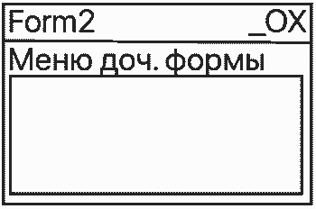

Рис. 26.2. Дочернее `MDI-окно`

Дочернее `MDI-окно` создано.

Страница 330

# НАСТРОЙКА РОДИТЕЛЬСКОЙ МDІ-ФОРМЫ.

Создайте функциональность для пунктов меню «Создать» и «Закрыть». **Во-первых**. Создайте обработчик событий `click` для элемента меню «Создать». **Во-вторых**. Вставьте код, аналогичный следующему, чтобы создать новую дочернюю `MDI-форму` при нажатии пользователем пункта меню «Создать».

```
protected void Создать_Click(object sender, System.EventArgs e)
{
    Form2 formMDI = new Form2();
    // Задайте родительскую форму дочернего окна.
    formMDI.MdiParent = this;
    // Отобразите дочернюю MDI-форму.
    formMDI.Show();
}
```

Свойство `Form.MdiParent` возвращает или задает текущую родительскую `MDI-форму`, в рамках которой будут размещаться дочерние `MDI-формы`, не выходя за границы родительской формы (см. рис. 26.3). Для доступа к дочерним формам в родительской создаются полосы прокрутки. Создайте обработчик меню «Закрыть» с вызовом метода `Close`: `private void закрытьToolStripMenuItem_Click(object sender, EventArgs e) { Close(); }`

Страница 331

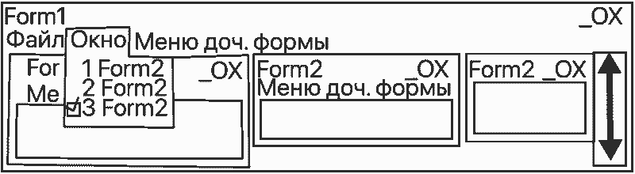

Рис. 26.3. Отображение дочерних `MDI-форм` в границах контейнера.

На этом первый этап разработки `MDI-приложения` будем считать выполненным.

# ОСОБЕННОСТИ `MDI-ПРИЛОЖЕНИЯ`

Из рис. 26.3 следует, что при создании нового `MDI-окна` в пункт меню «Окно» добавляется строка с текстом заголовка дочерней формы. Следует помнить, что когда в дочерней `MDI-форме` есть меню (элемент управления `MenuStrip`) и задано свойство `Form.MdiParent = род.форма`, к меню родительской формы автоматически добавится меню дочерней формы. При этом в последнем окне дочерней формы ее меню отображаться не будет. На рис. 26.3 продемонстрировано объединение меню родительской формы с «Меню доч. формы». Кроме того, если в дочерней `MDI-форме` расположены два элемента управления `MenuStrip`, то объединению подлежит только один. Необходимо отметить, что при закрытии родительской `MDI-формы` каждая из дочерних `MDI-форм` создает событие `FormClosing` до создания события `FormClosing` для родительской `MDI-формы`.

Страница 332

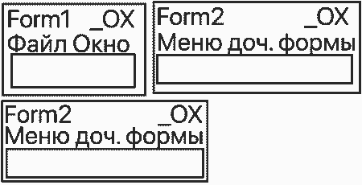

Рис. 26.4. Отображение дочерних `MDI-форм` при отсутствии контейнера.

Страница 333

# 26.4. Определение активной дочерней `MDI-формы`

Предположим, что в родительской форме требуется скопировать выделенный текст из текстового поля `RichTextBox` дочерней формы в буфер обмена или на свою форму. Возникает вопрос, как получить доступ к элементу управления, находящемуся в фокусе в текущей активной дочерней форме? Так как в приложении с `MDI-интерфейсом` могут существовать несколько экземпляров одной и той же дочерней формы, необходимо знать, какую форму использовать. Чтобы указать активную форму, используйте свойство `ActiveMdiChild`, которое возвращает дочернюю форму, находящуюся в фокусе или использовавшейся самой последней. Если в форме существуют несколько элементов управления, с помощью свойства `ActiveControl` можно получить активный элемент (с фокусом).

**Пример**. Пусть требуется скопировать выделенный текст из дочерней `MDI-формы` в буфер обмена и в элемент `Label` `MDI-родительской` формы. Добавим в родительскую форму `Form1`, разработанную для рисунка 26.3, кнопку `Button` с текстом «Копировать» и элемент `Label`. Элемент `Label` будем использовать для контроля. В обработчик события `Click` кнопки вставим приведённый ниже текст.

```
private void Копировать Click (object sender, EventArgs e)
{
    Form activeChild = this.ActiveMdiChild;
    if (activeChild ! = null)
    {
        try
        {
            RichTextBox richBox = (RichTextBox)activeChild.ActiveControl;
            if (richBox != null)
            {
                if (richBox.SelectedText |= ***)
                // Скопировать выделенный текст в буфер обмена.
                Clipboard.SetDataObject(richBox.SelectedText);
                labell.Text = richBox.SelectedText;
            }
            else
            { MessageBox.Show("В дочернем окне нет выделенного текста."); }
        }
        catch (Excention ex)
        { MessageBox.Show("Текст не скопирован!\n\n" + ex.Message, "Ошибка");}
    }
 }
```

Исключение может возникнуть, если текущим элементом управления является элемент другого типа, то есть не `RichTextBox`. В реальных условиях вместо кнопки `Button` для копирования текста в буфер обмена лучше использовать событие `Click` команды «Копировать» в стандартном меню «Правка».

Страница 334

# 26.5. Отправка данных в активную дочернюю MDI-форму.

Часто в контексте `MDI-приложений` требуется отправить данные в активное дочернее окно.

**Пример**. Пусть требуется вставить данные из буфера обмена в элемент управления `RichTextBox` активного дочернего `MDI-окна`. Добавим в родительскую форму предыдущего примера кнопку `Button` с текстом «Вставить». В обработчик события `Click` этой кнопки вставим приведённый ниже текст.

```
private void Вставить_Click(object sender, EventArgs e)
{
    Form activeChild = this.ActiveMdiChild;
    if (activeChild |= null)
    {
        try
        {
            RichTextBox richBox = (RichTextBox)activeChild.ActiveControl;
```

Страница 335

```
            if (richBox != null)
            {
                // Извлечь данные из буфера обмена.
                IDataObject data = Clipboard.GetDataObject();
                // Если данные являются текстом, то вставить текст
                // из буфера обмена в RichTextBox дочерней формы.
                if (data.GetDataPresent(DataFormats.Text))
                    richBox.SelectedText = data.GetData(DataFormats.Text).ToString();
            }
        }
        catch (Exception ex)
        {
            MessageBox.Show("Вам нужно выбрать RichTextBox\n\n." + ex. Message, "Ошибка");
        }
    }
}
```

В реальных условиях вместо кнопки Button для вставки текста из буфера обмена лучше использовать событие `Click` команды «Вставить» в стандартном меню «Правка».

Страница 336

[figure not shown]